# Résultats : Proj.sas

La procédure CONTENTS

| Nom de la table | PROJ.BASE_ESPS | Observations | 500 |
| --- | --- | --- | --- |
| Type de membre | DATA | Variables | 25 |
| Moteur | V9 | Index | 0 |
| Créée | 14/04/2026 21:09:14 | Longueur d'observation | 344 |
| Dernière modification | 14/04/2026 21:09:14 | Observations supprimées | 0 |
| Protection |  | Compressée | NON |
| Type de table |  | Triée | NON |
| Libellé |  |  |  |
| Représentation des données | SOLARIS_X86_64, LINUX_X86_64, ALPHA_TRU64, LINUX_IA64 |  |  |
| Codage | utf-8 Unicode (UTF-8) |  |  |

| Informations dépendantes de la machine/de l'hôte |  |
| --- | --- |
| Taille de la page | 131072 |
| Nombre de pages | 2 |
| Première page de données | 1 |
| Nb max. d'obs. par page | 380 |
| Obs. sur première page de données | 365 |
| Nombre de corrections dans la table | 0 |
| Nom du fichier | /home/u64471098/MonProjet/base_esps.sas7bdat |
| Version de création | 9.0401M8 |
| Hôte de création | Linux |
| Numéro Inode | 232255712 |
| Autorisation d'accès | rw-r--r-- |
| Nom du propriétaire | u64471098 |
| Taille du fichier | 384KB |
| Taille de fichier (octets) | 393216 |

| Liste alphabétique des variables et des attributs # | Liste alphabétique des variables et des attributs Variable | Liste alphabétique des variables et des attributs Type | Liste alphabétique des variables et des attributs Long. | Liste alphabétique des variables et des attributs Format | Liste alphabétique des variables et des attributs Informat |
| --- | --- | --- | --- | --- | --- |
| 22 | activite_physique | Texte | 19 | $19. | $19. |
| 2 | age | Num. | 8 | BEST12. | BEST32. |
| 21 | consommation_alcool | Texte | 13 | $13. | $13. |
| 12 | couverture_complementaire | Texte | 38 | $38. | $38. |
| 13 | depenses_sante_annuelles_euros | Num. | 8 | BEST12. | BEST32. |
| 17 | etat_sante_percu | Texte | 13 | $13. | $13. |
| 23 | handicap_declare | Texte | 3 | $3. | $3. |
| 16 | hospitalisation_12_mois | Texte | 3 | $3. | $3. |
| 1 | id | Num. | 8 | BEST12. | BEST32. |
| 19 | imc | Num. | 8 | BEST12. | BEST32. |
| 18 | maladies_declarees | Texte | 30 | $30. | $30. |
| 5 | niveau_education | Texte | 13 | $13. | $13. |
| 14 | nombre_consultations_annuelles | Num. | 8 | BEST12. | BEST32. |
| 7 | nombre_enfants | Num. | 8 | BEST12. | BEST32. |
| 15 | nombre_medicaments_reguliers | Num. | 8 | BEST12. | BEST32. |
| 4 | profession | Texte | 30 | $30. | $30. |
| 8 | region | Texte | 27 | $27. | $27. |
| 24 | renoncement_soins_12_mois | Texte | 3 | $3. | $3. |
| 10 | revenus_mensuels_euros | Num. | 8 | BEST12. | BEST32. |
| 25 | satisfaction_systeme_soins | Texte | 21 | $21. | $21. |
| 3 | sexe | Texte | 5 | $5. | $5. |
| 6 | situation_familiale | Texte | 12 | $12. | $12. |
| 11 | statut_assurance | Texte | 17 | $17. | $17. |
| 20 | tabagisme | Texte | 18 | $18. | $18. |
| 9 | type_commune | Texte | 15 | $15. | $15. |

Distribution de la variable réponse — État de santé perçu

La procédure FREQ

| etat_sante_percu | Fréquence | Pourcentage | Fréquence cumulée | Pourcentage cumulé |
| --- | --- | --- | --- | --- |
| Assez bon | 148 | 29.60 | 148 | 29.60 |
| Bon | 143 | 28.60 | 291 | 58.20 |
| Mauvais | 98 | 19.60 | 389 | 77.80 |
| Très bon | 71 | 14.20 | 460 | 92.00 |
| Très mauvais | 40 | 8.00 | 500 | 100.00 |

Vérification du recodage ordinal

La procédure FREQ

| Fréquence |
| --- |

| Table de etat_sante_percu par score_sante etat_sante_percu | Table de etat_sante_percu par score_sante score_sante 1 | Table de etat_sante_percu par score_sante score_sante 2 | Table de etat_sante_percu par score_sante score_sante 3 | Table de etat_sante_percu par score_sante score_sante 4 | Table de etat_sante_percu par score_sante score_sante 5 | Table de etat_sante_percu par score_sante score_sante Total |
| --- | --- | --- | --- | --- | --- | --- |
| Assez bon | 0 | 0 | 148 | 0 | 0 | 148 |
| Bon | 0 | 0 | 0 | 143 | 0 | 143 |
| Mauvais | 0 | 98 | 0 | 0 | 0 | 98 |
| Très bon | 0 | 0 | 0 | 0 | 71 | 71 |
| Très mauvais | 40 | 0 | 0 | 0 | 0 | 40 |
| Total | 40 | 98 | 148 | 143 | 71 | 500 |

Bivariée : État de santé perçu × Sexe

La procédure FREQ

| Fréquence Attendu Khi-2 de cellule Pourcentage |
| --- |

| Table de etat_sante_percu par sexe etat_sante_percu | Table de etat_sante_percu par sexe sexe Femme | Table de etat_sante_percu par sexe sexe Homme | Table de etat_sante_percu par sexe sexe Total |
| --- | --- | --- | --- |
| Assez bon | 83 82.288 0.0062 16.60 | 65 65.712 0.0077 13.00 | 148 29.60 |
| Bon | 77 79.508 0.0791 15.40 | 66 63.492 0.0991 13.20 | 143 28.60 |
| Mauvais | 54 54.488 0.0044 10.80 | 44 43.512 0.0055 8.80 | 98 19.60 |
| Très bon | 41 39.476 0.0588 8.20 | 30 31.524 0.0737 6.00 | 71 14.20 |
| Très mauvais | 23 22.24 0.026 4.60 | 17 17.76 0.0325 3.40 | 40 8.00 |
| Total | 278 55.60 | 222 44.40 | 500 100.00 |

Statistiques pour la table de etat_sante_percu par sexe

| Statistique | DDL | Valeur | Prob |
| --- | --- | --- | --- |
| Khi-2 | 4 | 0.3929 | 0.9831 |
| Test du rapport de vraisemblance | 4 | 0.3931 | 0.9830 |
| Khi-2 de Mantel-Haenszel | 1 | 0.0861 | 0.7692 |
| Coefficient Phi |  | 0.0280 |  |
| Coefficient de contingence |  | 0.0280 |  |
| V de Cramer |  | 0.0280 |  |

Taille de l'échantillon = 500

Bivariée : État de santé perçu × Profession

La procédure FREQ

| Fréquence Attendu Pourcentage Pct de ligne Pct de col. |
| --- |

| Table de etat_sante_percu par profession etat_sante_percu | Table de etat_sante_percu par profession profession Agriculteur | Table de etat_sante_percu par profession profession Artisan/Commerçant | Table de etat_sante_percu par profession profession Cadre supérieur | Table de etat_sante_percu par profession profession Employé | Table de etat_sante_percu par profession profession Ouvrier | Table de etat_sante_percu par profession profession Profession intermédiaire | Table de etat_sante_percu par profession profession Retraité | Table de etat_sante_percu par profession profession Sans activité professionnelle | Table de etat_sante_percu par profession profession Étudiant | Table de etat_sante_percu par profession profession Total |
| --- | --- | --- | --- | --- | --- | --- | --- | --- | --- | --- |
| Assez bon | 1 1.776 0.20 0.68 16.67 | 5 7.696 1.00 3.38 19.23 | 5 8.88 1.00 3.38 16.67 | 23 19.536 4.60 15.54 34.85 | 11 15.392 2.20 7.43 21.15 | 12 11.544 2.40 8.11 30.77 | 64 55.648 12.80 43.24 34.04 | 19 18.056 3.80 12.84 31.15 | 8 9.472 1.60 5.41 25.00 | 148 29.60 |
| Bon | 2 1.716 0.40 1.40 33.33 | 11 7.436 2.20 7.69 42.31 | 10 8.58 2.00 6.99 33.33 | 17 18.876 3.40 11.89 25.76 | 20 14.872 4.00 13.99 38.46 | 10 11.154 2.00 6.99 25.64 | 41 53.768 8.20 28.67 21.81 | 20 17.446 4.00 13.99 32.79 | 12 9.152 2.40 8.39 37.50 | 143 28.60 |
| Mauvais | 2 1.176 0.40 2.04 33.33 | 4 5.096 0.80 4.08 15.38 | 7 5.88 1.40 7.14 23.33 | 7 12.936 1.40 7.14 10.61 | 8 10.192 1.60 8.16 15.38 | 9 7.644 1.80 9.18 23.08 | 47 36.848 9.40 47.96 25.00 | 10 11.956 2.00 10.20 16.39 | 4 6.272 0.80 4.08 12.50 | 98 19.60 |
| Très bon | 1 0.852 0.20 1.41 16.67 | 5 3.692 1.00 7.04 19.23 | 7 4.26 1.40 9.86 23.33 | 14 9.372 2.80 19.72 21.21 | 11 7.384 2.20 15.49 21.15 | 6 5.538 1.20 8.45 15.38 | 11 26.696 2.20 15.49 5.85 | 9 8.662 1.80 12.68 14.75 | 7 4.544 1.40 9.86 21.88 | 71 14.20 |
| Très mauvais | 0 0.48 0.00 0.00 0.00 | 1 2.08 0.20 2.50 3.85 | 1 2.4 0.20 2.50 3.33 | 5 5.28 1.00 12.50 7.58 | 2 4.16 0.40 5.00 3.85 | 2 3.12 0.40 5.00 5.13 | 25 15.04 5.00 62.50 13.30 | 3 4.88 0.60 7.50 4.92 | 1 2.56 0.20 2.50 3.13 | 40 8.00 |
| Total | 6 1.20 | 26 5.20 | 30 6.00 | 66 13.20 | 52 10.40 | 39 7.80 | 188 37.60 | 61 12.20 | 32 6.40 | 500 100.00 |

Statistiques pour la table de etat_sante_percu par profession

| Statistique | DDL | Valeur | Prob |
| --- | --- | --- | --- |
| Khi-2 | 32 | 51.7364 | 0.0151 |
| Test du rapport de vraisemblance | 32 | 54.5542 | 0.0077 |
| Khi-2 de Mantel-Haenszel | 1 | 0.6204 | 0.4309 |
| Coefficient Phi |  | 0.3217 |  |
| Coefficient de contingence |  | 0.3062 |  |
| V de Cramer |  | 0.1608 |  |

WARNING: 31% des cellules ont un effectif théorique inférieur à 5. Le test du Khi-2 peut ne pas convenir.

Taille de l'échantillon = 500

Bivariée : État de santé perçu × Niveau d'éducation

La procédure FREQ

| Fréquence Attendu Pourcentage Pct de ligne Pct de col. |
| --- |

| Table de etat_sante_percu par niveau_education etat_sante_percu | Table de etat_sante_percu par niveau_education niveau_education Bac+2 | Table de etat_sante_percu par niveau_education niveau_education Bac+3/Licence | Table de etat_sante_percu par niveau_education niveau_education Bac+5/Master | Table de etat_sante_percu par niveau_education niveau_education Baccalauréat | Table de etat_sante_percu par niveau_education niveau_education CAP/BEP | Table de etat_sante_percu par niveau_education niveau_education Doctorat | Table de etat_sante_percu par niveau_education niveau_education Sans diplôme | Table de etat_sante_percu par niveau_education niveau_education Total |
| --- | --- | --- | --- | --- | --- | --- | --- | --- |
| Assez bon | 19 23.976 3.80 12.84 23.46 | 13 19.24 2.60 8.78 20.00 | 22 21.312 4.40 14.86 30.56 | 30 31.08 6.00 20.27 28.57 | 34 26.048 6.80 22.97 38.64 | 10 9.768 2.00 6.76 30.30 | 20 16.576 4.00 13.51 35.71 | 148 29.60 |
| Bon | 27 23.166 5.40 18.88 33.33 | 23 18.59 4.60 16.08 35.38 | 21 20.592 4.20 14.69 29.17 | 26 30.03 5.20 18.18 24.76 | 18 25.168 3.60 12.59 20.45 | 10 9.438 2.00 6.99 30.30 | 18 16.016 3.60 12.59 32.14 | 143 28.60 |
| Mauvais | 17 15.876 3.40 17.35 20.99 | 13 12.74 2.60 13.27 20.00 | 13 14.112 2.60 13.27 18.06 | 23 20.58 4.60 23.47 21.90 | 17 17.248 3.40 17.35 19.32 | 9 6.468 1.80 9.18 27.27 | 6 10.976 1.20 6.12 10.71 | 98 19.60 |
| Très bon | 10 11.502 2.00 14.08 12.35 | 11 9.23 2.20 15.49 16.92 | 11 10.224 2.20 15.49 15.28 | 17 14.91 3.40 23.94 16.19 | 11 12.496 2.20 15.49 12.50 | 4 4.686 0.80 5.63 12.12 | 7 7.952 1.40 9.86 12.50 | 71 14.20 |
| Très mauvais | 8 6.48 1.60 20.00 9.88 | 5 5.2 1.00 12.50 7.69 | 5 5.76 1.00 12.50 6.94 | 9 8.4 1.80 22.50 8.57 | 8 7.04 1.60 20.00 9.09 | 0 2.64 0.00 0.00 0.00 | 5 4.48 1.00 12.50 8.93 | 40 8.00 |
| Total | 81 16.20 | 65 13.00 | 72 14.40 | 105 21.00 | 88 17.60 | 33 6.60 | 56 11.20 | 500 100.00 |

Statistiques pour la table de etat_sante_percu par niveau_education

| Statistique | DDL | Valeur | Prob |
| --- | --- | --- | --- |
| Khi-2 | 24 | 19.1342 | 0.7448 |
| Test du rapport de vraisemblance | 24 | 22.2885 | 0.5621 |
| Khi-2 de Mantel-Haenszel | 1 | 2.7428 | 0.0977 |
| Coefficient Phi |  | 0.1956 |  |
| Coefficient de contingence |  | 0.1920 |  |
| V de Cramer |  | 0.0978 |  |

Taille de l'échantillon = 500

Bivariée : État de santé perçu × Situation familiale

La procédure FREQ

| Fréquence Attendu Pourcentage Pct de ligne Pct de col. |
| --- |

| Table de etat_sante_percu par situation_familiale etat_sante_percu | Table de etat_sante_percu par situation_familiale situation_familiale Célibataire | Table de etat_sante_percu par situation_familiale situation_familiale Divorcé(e) | Table de etat_sante_percu par situation_familiale situation_familiale Marié(e) | Table de etat_sante_percu par situation_familiale situation_familiale Pacsé(e) | Table de etat_sante_percu par situation_familiale situation_familiale Veuf/Veuve | Table de etat_sante_percu par situation_familiale situation_familiale Total |
| --- | --- | --- | --- | --- | --- | --- |
| Assez bon | 49 44.992 9.80 33.11 32.24 | 26 24.568 5.20 17.57 31.33 | 47 48.84 9.40 31.76 28.48 | 16 15.392 3.20 10.81 30.77 | 10 14.208 2.00 6.76 20.83 | 148 29.60 |
| Bon | 44 43.472 8.80 30.77 28.95 | 20 23.738 4.00 13.99 24.10 | 49 47.19 9.80 34.27 29.70 | 20 14.872 4.00 13.99 38.46 | 10 13.728 2.00 6.99 20.83 | 143 28.60 |
| Mauvais | 27 29.792 5.40 27.55 17.76 | 20 16.268 4.00 20.41 24.10 | 28 32.34 5.60 28.57 16.97 | 6 10.192 1.20 6.12 11.54 | 17 9.408 3.40 17.35 35.42 | 98 19.60 |
| Très bon | 24 21.584 4.80 33.80 15.79 | 12 11.786 2.40 16.90 14.46 | 26 23.43 5.20 36.62 15.76 | 6 7.384 1.20 8.45 11.54 | 3 6.816 0.60 4.23 6.25 | 71 14.20 |
| Très mauvais | 8 12.16 1.60 20.00 5.26 | 5 6.64 1.00 12.50 6.02 | 15 13.2 3.00 37.50 9.09 | 4 4.16 0.80 10.00 7.69 | 8 3.84 1.60 20.00 16.67 | 40 8.00 |
| Total | 152 30.40 | 83 16.60 | 165 33.00 | 52 10.40 | 48 9.60 | 500 100.00 |

Statistiques pour la table de etat_sante_percu par situation_familiale

| Statistique | DDL | Valeur | Prob |
| --- | --- | --- | --- |
| Khi-2 | 16 | 24.3146 | 0.0829 |
| Test du rapport de vraisemblance | 16 | 23.2113 | 0.1082 |
| Khi-2 de Mantel-Haenszel | 1 | 2.4116 | 0.1204 |
| Coefficient Phi |  | 0.2205 |  |
| Coefficient de contingence |  | 0.2153 |  |
| V de Cramer |  | 0.1103 |  |

Taille de l'échantillon = 500

Bivariée : État de santé perçu × Couverture complémentaire

La procédure FREQ

| Fréquence Attendu Pourcentage Pct de ligne Pct de col. |
| --- |

| Table de etat_sante_percu par couverture_complementaire etat_sante_percu | Table de etat_sante_percu par couverture_complementaire couverture_complementaire Assurance privée | Table de etat_sante_percu par couverture_complementaire couverture_complementaire Aucune complémentaire | Table de etat_sante_percu par couverture_complementaire couverture_complementaire Complémentaire santé solidaire (CSS) | Table de etat_sante_percu par couverture_complementaire couverture_complementaire Mutuelle privée | Table de etat_sante_percu par couverture_complementaire couverture_complementaire Total |
| --- | --- | --- | --- | --- | --- |
| Assez bon | 32 27.824 6.40 21.62 34.04 | 14 14.208 2.80 9.46 29.17 | 31 25.456 6.20 20.95 36.05 | 71 80.512 14.20 47.97 26.10 | 148 29.60 |
| Bon | 26 26.884 5.20 18.18 27.66 | 15 13.728 3.00 10.49 31.25 | 20 24.596 4.00 13.99 23.26 | 82 77.792 16.40 57.34 30.15 | 143 28.60 |
| Mauvais | 18 18.424 3.60 18.37 19.15 | 8 9.408 1.60 8.16 16.67 | 17 16.856 3.40 17.35 19.77 | 55 53.312 11.00 56.12 20.22 | 98 19.60 |
| Très bon | 12 13.348 2.40 16.90 12.77 | 8 6.816 1.60 11.27 16.67 | 12 12.212 2.40 16.90 13.95 | 39 38.624 7.80 54.93 14.34 | 71 14.20 |
| Très mauvais | 6 7.52 1.20 15.00 6.38 | 3 3.84 0.60 7.50 6.25 | 6 6.88 1.20 15.00 6.98 | 25 21.76 5.00 62.50 9.19 | 40 8.00 |
| Total | 94 18.80 | 48 9.60 | 86 17.20 | 272 54.40 | 500 100.00 |

Statistiques pour la table de etat_sante_percu par couverture_complementaire

| Statistique | DDL | Valeur | Prob |
| --- | --- | --- | --- |
| Khi-2 | 12 | 5.9046 | 0.9208 |
| Test du rapport de vraisemblance | 12 | 5.9211 | 0.9200 |
| Khi-2 de Mantel-Haenszel | 1 | 1.9646 | 0.1610 |
| Coefficient Phi |  | 0.1087 |  |
| Coefficient de contingence |  | 0.1080 |  |
| V de Cramer |  | 0.0627 |  |

Taille de l'échantillon = 500

Bivariée : État de santé perçu × Hospitalisation 12 mois

La procédure FREQ

| Fréquence Attendu Pourcentage Pct de ligne Pct de col. |
| --- |

| Table de etat_sante_percu par hospitalisation_12_mois etat_sante_percu | Table de etat_sante_percu par hospitalisation_12_mois hospitalisation_12_mois Non | Table de etat_sante_percu par hospitalisation_12_mois hospitalisation_12_mois Oui | Table de etat_sante_percu par hospitalisation_12_mois hospitalisation_12_mois Total |
| --- | --- | --- | --- |
| Assez bon | 102 106.56 20.40 68.92 28.33 | 46 41.44 9.20 31.08 32.86 | 148 29.60 |
| Bon | 107 102.96 21.40 74.83 29.72 | 36 40.04 7.20 25.17 25.71 | 143 28.60 |
| Mauvais | 70 70.56 14.00 71.43 19.44 | 28 27.44 5.60 28.57 20.00 | 98 19.60 |
| Très bon | 54 51.12 10.80 76.06 15.00 | 17 19.88 3.40 23.94 12.14 | 71 14.20 |
| Très mauvais | 27 28.8 5.40 67.50 7.50 | 13 11.2 2.60 32.50 9.29 | 40 8.00 |
| Total | 360 72.00 | 140 28.00 | 500 100.00 |

Statistiques pour la table de etat_sante_percu par hospitalisation_12_mois

| Statistique | DDL | Valeur | Prob |
| --- | --- | --- | --- |
| Khi-2 | 4 | 2.2602 | 0.6880 |
| Test du rapport de vraisemblance | 4 | 2.2648 | 0.6872 |
| Khi-2 de Mantel-Haenszel | 1 | 0.1176 | 0.7316 |
| Coefficient Phi |  | 0.0672 |  |
| Coefficient de contingence |  | 0.0671 |  |
| V de Cramer |  | 0.0672 |  |

Taille de l'échantillon = 500

Bivariée : État de santé perçu × Tabagisme

La procédure FREQ

| Fréquence Attendu Pourcentage Pct de ligne Pct de col. |
| --- |

| Table de etat_sante_percu par tabagisme etat_sante_percu | Table de etat_sante_percu par tabagisme tabagisme Ancien fumeur | Table de etat_sante_percu par tabagisme tabagisme Fumeur occasionnel | Table de etat_sante_percu par tabagisme tabagisme Fumeur quotidien | Table de etat_sante_percu par tabagisme tabagisme Non-fumeur | Table de etat_sante_percu par tabagisme tabagisme Total |
| --- | --- | --- | --- | --- | --- |
| Assez bon | 39 39.664 7.80 26.35 29.10 | 19 16.872 3.80 12.84 33.33 | 34 36.112 6.80 22.97 27.87 | 56 55.352 11.20 37.84 29.95 | 148 29.60 |
| Bon | 43 38.324 8.60 30.07 32.09 | 15 16.302 3.00 10.49 26.32 | 36 34.892 7.20 25.17 29.51 | 49 53.482 9.80 34.27 26.20 | 143 28.60 |
| Mauvais | 26 26.264 5.20 26.53 19.40 | 14 11.172 2.80 14.29 24.56 | 24 23.912 4.80 24.49 19.67 | 34 36.652 6.80 34.69 18.18 | 98 19.60 |
| Très bon | 18 19.028 3.60 25.35 13.43 | 5 8.094 1.00 7.04 8.77 | 21 17.324 4.20 29.58 17.21 | 27 26.554 5.40 38.03 14.44 | 71 14.20 |
| Très mauvais | 8 10.72 1.60 20.00 5.97 | 4 4.56 0.80 10.00 7.02 | 7 9.76 1.40 17.50 5.74 | 21 14.96 4.20 52.50 11.23 | 40 8.00 |
| Total | 134 26.80 | 57 11.40 | 122 24.40 | 187 37.40 | 500 100.00 |

Statistiques pour la table de etat_sante_percu par tabagisme

| Statistique | DDL | Valeur | Prob |
| --- | --- | --- | --- |
| Khi-2 | 12 | 8.4104 | 0.7523 |
| Test du rapport de vraisemblance | 12 | 8.3661 | 0.7559 |
| Khi-2 de Mantel-Haenszel | 1 | 1.5192 | 0.2177 |
| Coefficient Phi |  | 0.1297 |  |
| Coefficient de contingence |  | 0.1286 |  |
| V de Cramer |  | 0.0749 |  |

Taille de l'échantillon = 500

Bivariée : État de santé perçu × Consommation d'alcool

La procédure FREQ

| Fréquence Attendu Pourcentage Pct de ligne Pct de col. |
| --- |

| Table de etat_sante_percu par consommation_alcool etat_sante_percu | Table de etat_sante_percu par consommation_alcool consommation_alcool Jamais | Table de etat_sante_percu par consommation_alcool consommation_alcool Occasionnelle | Table de etat_sante_percu par consommation_alcool consommation_alcool Quotidienne | Table de etat_sante_percu par consommation_alcool consommation_alcool Régulière | Table de etat_sante_percu par consommation_alcool consommation_alcool Total |
| --- | --- | --- | --- | --- | --- |
| Assez bon | 32 30.784 6.40 21.62 30.77 | 59 57.128 11.80 39.86 30.57 | 17 18.352 3.40 11.49 27.42 | 40 41.736 8.00 27.03 28.37 | 148 29.60 |
| Bon | 31 29.744 6.20 21.68 29.81 | 51 55.198 10.20 35.66 26.42 | 18 17.732 3.60 12.59 29.03 | 43 40.326 8.60 30.07 30.50 | 143 28.60 |
| Mauvais | 22 20.384 4.40 22.45 21.15 | 40 37.828 8.00 40.82 20.73 | 12 12.152 2.40 12.24 19.35 | 24 27.636 4.80 24.49 17.02 | 98 19.60 |
| Très bon | 13 14.768 2.60 18.31 12.50 | 32 27.406 6.40 45.07 16.58 | 8 8.804 1.60 11.27 12.90 | 18 20.022 3.60 25.35 12.77 | 71 14.20 |
| Très mauvais | 6 8.32 1.20 15.00 5.77 | 11 15.44 2.20 27.50 5.70 | 7 4.96 1.40 17.50 11.29 | 16 11.28 3.20 40.00 11.35 | 40 8.00 |
| Total | 104 20.80 | 193 38.60 | 62 12.40 | 141 28.20 | 500 100.00 |

Statistiques pour la table de etat_sante_percu par consommation_alcool

| Statistique | DDL | Valeur | Prob |
| --- | --- | --- | --- |
| Khi-2 | 12 | 7.5651 | 0.8181 |
| Test du rapport de vraisemblance | 12 | 7.4558 | 0.8261 |
| Khi-2 de Mantel-Haenszel | 1 | 1.0544 | 0.3045 |
| Coefficient Phi |  | 0.1230 |  |
| Coefficient de contingence |  | 0.1221 |  |
| V de Cramer |  | 0.0710 |  |

Taille de l'échantillon = 500

Bivariée : État de santé perçu × Activité physique

La procédure FREQ

| Fréquence Attendu Pourcentage Pct de ligne Pct de col. |
| --- |

| Table de etat_sante_percu par activite_physique etat_sante_percu | Table de etat_sante_percu par activite_physique activite_physique Activité intense | Table de etat_sante_percu par activite_physique activite_physique Activité légère | Table de etat_sante_percu par activite_physique activite_physique Activité modérée | Table de etat_sante_percu par activite_physique activite_physique Sédentaire | Table de etat_sante_percu par activite_physique activite_physique Total |
| --- | --- | --- | --- | --- | --- |
| Assez bon | 20 18.352 4.00 13.51 32.26 | 50 44.992 10.00 33.78 32.89 | 45 45.88 9.00 30.41 29.03 | 33 38.776 6.60 22.30 25.19 | 148 29.60 |
| Bon | 15 17.732 3.00 10.49 24.19 | 41 43.472 8.20 28.67 26.97 | 46 44.33 9.20 32.17 29.68 | 41 37.466 8.20 28.67 31.30 | 143 28.60 |
| Mauvais | 16 12.152 3.20 16.33 25.81 | 29 29.792 5.80 29.59 19.08 | 28 30.38 5.60 28.57 18.06 | 25 25.676 5.00 25.51 19.08 | 98 19.60 |
| Très bon | 4 8.804 0.80 5.63 6.45 | 21 21.584 4.20 29.58 13.82 | 25 22.01 5.00 35.21 16.13 | 21 18.602 4.20 29.58 16.03 | 71 14.20 |
| Très mauvais | 7 4.96 1.40 17.50 11.29 | 11 12.16 2.20 27.50 7.24 | 11 12.4 2.20 27.50 7.10 | 11 10.48 2.20 27.50 8.40 | 40 8.00 |
| Total | 62 12.40 | 152 30.40 | 155 31.00 | 131 26.20 | 500 100.00 |

Statistiques pour la table de etat_sante_percu par activite_physique

| Statistique | DDL | Valeur | Prob |
| --- | --- | --- | --- |
| Khi-2 | 12 | 8.4703 | 0.7474 |
| Test du rapport de vraisemblance | 12 | 8.9615 | 0.7062 |
| Khi-2 de Mantel-Haenszel | 1 | 0.7644 | 0.3820 |
| Coefficient Phi |  | 0.1302 |  |
| Coefficient de contingence |  | 0.1291 |  |
| V de Cramer |  | 0.0751 |  |

Taille de l'échantillon = 500

Bivariée : État de santé perçu × Handicap déclaré

La procédure FREQ

| Fréquence Attendu Pourcentage Pct de ligne Pct de col. |
| --- |

| Table de etat_sante_percu par handicap_declare etat_sante_percu | Table de etat_sante_percu par handicap_declare handicap_declare Non | Table de etat_sante_percu par handicap_declare handicap_declare Oui | Table de etat_sante_percu par handicap_declare handicap_declare Total |
| --- | --- | --- | --- |
| Assez bon | 108 116.03 21.60 72.97 27.55 | 40 31.968 8.00 27.03 37.04 | 148 29.60 |
| Bon | 111 112.11 22.20 77.62 28.32 | 32 30.888 6.40 22.38 29.63 | 143 28.60 |
| Mauvais | 83 76.832 16.60 84.69 21.17 | 15 21.168 3.00 15.31 13.89 | 98 19.60 |
| Très bon | 58 55.664 11.60 81.69 14.80 | 13 15.336 2.60 18.31 12.04 | 71 14.20 |
| Très mauvais | 32 31.36 6.40 80.00 8.16 | 8 8.64 1.60 20.00 7.41 | 40 8.00 |
| Total | 392 78.40 | 108 21.60 | 500 100.00 |

Statistiques pour la table de etat_sante_percu par handicap_declare

| Statistique | DDL | Valeur | Prob |
| --- | --- | --- | --- |
| Khi-2 | 4 | 5.4318 | 0.2458 |
| Test du rapport de vraisemblance | 4 | 5.5063 | 0.2392 |
| Khi-2 de Mantel-Haenszel | 1 | 3.1842 | 0.0744 |
| Coefficient Phi |  | 0.1042 |  |
| Coefficient de contingence |  | 0.1037 |  |
| V de Cramer |  | 0.1042 |  |

Taille de l'échantillon = 500

Bivariée : État de santé perçu × Renoncement aux soins

La procédure FREQ

| Fréquence Attendu Pourcentage Pct de ligne Pct de col. |
| --- |

| Table de etat_sante_percu par renoncement_soins_12_mois etat_sante_percu | Table de etat_sante_percu par renoncement_soins_12_mois renoncement_soins_12_mois Non | Table de etat_sante_percu par renoncement_soins_12_mois renoncement_soins_12_mois Oui | Table de etat_sante_percu par renoncement_soins_12_mois renoncement_soins_12_mois Total |
| --- | --- | --- | --- |
| Assez bon | 126 123.73 25.20 85.14 30.14 | 22 24.272 4.40 14.86 26.83 | 148 29.60 |
| Bon | 112 119.55 22.40 78.32 26.79 | 31 23.452 6.20 21.68 37.80 | 143 28.60 |
| Mauvais | 86 81.928 17.20 87.76 20.57 | 12 16.072 2.40 12.24 14.63 | 98 19.60 |
| Très bon | 61 59.356 12.20 85.92 14.59 | 10 11.644 2.00 14.08 12.20 | 71 14.20 |
| Très mauvais | 33 33.44 6.60 82.50 7.89 | 7 6.56 1.40 17.50 8.54 | 40 8.00 |
| Total | 418 83.60 | 82 16.40 | 500 100.00 |

Statistiques pour la table de etat_sante_percu par renoncement_soins_12_mois

| Statistique | DDL | Valeur | Prob |
| --- | --- | --- | --- |
| Khi-2 | 4 | 4.7073 | 0.3187 |
| Test du rapport de vraisemblance | 4 | 4.6067 | 0.3301 |
| Khi-2 de Mantel-Haenszel | 1 | 0.1292 | 0.7193 |
| Coefficient Phi |  | 0.0970 |  |
| Coefficient de contingence |  | 0.0966 |  |
| V de Cramer |  | 0.0970 |  |

Taille de l'échantillon = 500

Bivariée : État de santé perçu × Maladies déclarées

La procédure FREQ

| Fréquence Attendu Pourcentage Pct de ligne Pct de col. |
| --- |

| Table de etat_sante_percu par maladies_declarees etat_sante_percu | Table de etat_sante_percu par maladies_declarees maladies_declarees Arthrose | Table de etat_sante_percu par maladies_declarees maladies_declarees Asthme | Table de etat_sante_percu par maladies_declarees maladies_declarees Aucune | Table de etat_sante_percu par maladies_declarees maladies_declarees Cancer (rémission) | Table de etat_sante_percu par maladies_declarees maladies_declarees Cardiopathie | Table de etat_sante_percu par maladies_declarees maladies_declarees Diabète | Table de etat_sante_percu par maladies_declarees maladies_declarees Dépression | Table de etat_sante_percu par maladies_declarees maladies_declarees Hypertension | Table de etat_sante_percu par maladies_declarees maladies_declarees Lombalgie chronique | Table de etat_sante_percu par maladies_declarees maladies_declarees Maladie respiratoire chronique | Table de etat_sante_percu par maladies_declarees maladies_declarees Migraine chronique | Table de etat_sante_percu par maladies_declarees maladies_declarees Obésité morbide | Table de etat_sante_percu par maladies_declarees maladies_declarees Trouble anxieux | Table de etat_sante_percu par maladies_declarees maladies_declarees Total |
| --- | --- | --- | --- | --- | --- | --- | --- | --- | --- | --- | --- | --- | --- | --- |
| Assez bon | 8 7.992 1.60 5.41 29.63 | 6 6.216 1.20 4.05 28.57 | 58 58.016 11.60 39.19 29.59 | 2 2.96 0.40 1.35 20.00 | 7 6.216 1.40 4.73 33.33 | 17 12.728 3.40 11.49 39.53 | 5 7.696 1.00 3.38 19.23 | 17 18.056 3.40 11.49 27.87 | 6 8.88 1.20 4.05 20.00 | 5 5.92 1.00 3.38 25.00 | 6 4.736 1.20 4.05 37.50 | 1 2.072 0.20 0.68 14.29 | 10 6.512 2.00 6.76 45.45 | 148 29.60 |
| Bon | 6 7.722 1.20 4.20 22.22 | 7 6.006 1.40 4.90 33.33 | 66 56.056 13.20 46.15 33.67 | 5 2.86 1.00 3.50 50.00 | 3 6.006 0.60 2.10 14.29 | 9 12.298 1.80 6.29 20.93 | 5 7.436 1.00 3.50 19.23 | 13 17.446 2.60 9.09 21.31 | 12 8.58 2.40 8.39 40.00 | 6 5.72 1.20 4.20 30.00 | 5 4.576 1.00 3.50 31.25 | 2 2.002 0.40 1.40 28.57 | 4 6.292 0.80 2.80 18.18 | 143 28.60 |
| Mauvais | 5 5.292 1.00 5.10 18.52 | 2 4.116 0.40 2.04 9.52 | 33 38.416 6.60 33.67 16.84 | 3 1.96 0.60 3.06 30.00 | 7 4.116 1.40 7.14 33.33 | 10 8.428 2.00 10.20 23.26 | 6 5.096 1.20 6.12 23.08 | 15 11.956 3.00 15.31 24.59 | 5 5.88 1.00 5.10 16.67 | 3 3.92 0.60 3.06 15.00 | 2 3.136 0.40 2.04 12.50 | 2 1.372 0.40 2.04 28.57 | 5 4.312 1.00 5.10 22.73 | 98 19.60 |
| Très bon | 6 3.834 1.20 8.45 22.22 | 5 2.982 1.00 7.04 23.81 | 23 27.832 4.60 32.39 11.73 | 0 1.42 0.00 0.00 0.00 | 2 2.982 0.40 2.82 9.52 | 3 6.106 0.60 4.23 6.98 | 5 3.692 1.00 7.04 19.23 | 12 8.662 2.40 16.90 19.67 | 5 4.26 1.00 7.04 16.67 | 6 2.84 1.20 8.45 30.00 | 2 2.272 0.40 2.82 12.50 | 1 0.994 0.20 1.41 14.29 | 1 3.124 0.20 1.41 4.55 | 71 14.20 |
| Très mauvais | 2 2.16 0.40 5.00 7.41 | 1 1.68 0.20 2.50 4.76 | 16 15.68 3.20 40.00 8.16 | 0 0.8 0.00 0.00 0.00 | 2 1.68 0.40 5.00 9.52 | 4 3.44 0.80 10.00 9.30 | 5 2.08 1.00 12.50 19.23 | 4 4.88 0.80 10.00 6.56 | 2 2.4 0.40 5.00 6.67 | 0 1.6 0.00 0.00 0.00 | 1 1.28 0.20 2.50 6.25 | 1 0.56 0.20 2.50 14.29 | 2 1.76 0.40 5.00 9.09 | 40 8.00 |
| Total | 27 5.40 | 21 4.20 | 196 39.20 | 10 2.00 | 21 4.20 | 43 8.60 | 26 5.20 | 61 12.20 | 30 6.00 | 20 4.00 | 16 3.20 | 7 1.40 | 22 4.40 | 500 100.00 |

Statistiques pour la table de etat_sante_percu par maladies_declarees

| Statistique | DDL | Valeur | Prob |
| --- | --- | --- | --- |
| Khi-2 | 48 | 45.2376 | 0.5867 |
| Test du rapport de vraisemblance | 48 | 47.4896 | 0.4937 |
| Khi-2 de Mantel-Haenszel | 1 | 0.0970 | 0.7555 |
| Coefficient Phi |  | 0.3008 |  |
| Coefficient de contingence |  | 0.2880 |  |
| V de Cramer |  | 0.1504 |  |

WARNING: 54% des cellules ont un effectif théorique inférieur à 5. Le test du Khi-2 peut ne pas convenir.

Taille de l'échantillon = 500

Bivariée ANOVA : Âge selon l'état de santé perçu

La procédure GLM

| Informations sur les niveaux de classe Classe | Informations sur les niveaux de classe Niveaux | Informations sur les niveaux de classe Valeurs |
| --- | --- | --- |
| etat_sante_percu | 5 | Assez bon Bon Mauvais Très bon Très mauvais |

| Nombre d'observations lues | 500 |
| --- | --- |
| Nombre d'observations utilisées | 500 |

Bivariée ANOVA : Âge selon l'état de santé perçu

La procédure GLM

Variable dépendante : age

| Source | DDL | Somme des carrés | Carré moyen | Valeur F | Pr > F |
| --- | --- | --- | --- | --- | --- |
| Modèle | 4 | 34276.1775 | 8569.0444 | 18.72 | <.0001 |
| Erreur | 495 | 226552.0225 | 457.6809 |  |  |
| Total sommes corrigées | 499 | 260828.2000 |  |  |  |

| R-carré | Coef de var | Racine MSE | age Moyenne |
| --- | --- | --- | --- |
| 0.131413 | 36.97455 | 21.39348 | 57.86000 |

| Source | DDL | Type I SS | Carré moyen | Valeur F | Pr > F |
| --- | --- | --- | --- | --- | --- |
| etat_sante_percu | 4 | 34276.17748 | 8569.04437 | 18.72 | <.0001 |

| Source | DDL | Type III SS | Carré moyen | Valeur F | Pr > F |
| --- | --- | --- | --- | --- | --- |
| etat_sante_percu | 4 | 34276.17748 | 8569.04437 | 18.72 | <.0001 |

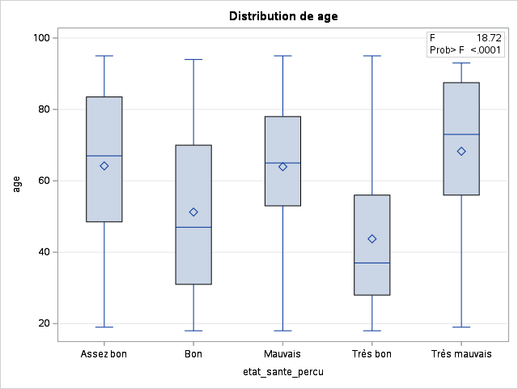

Bivariée ANOVA : Âge selon l'état de santé perçu

La procédure GLM

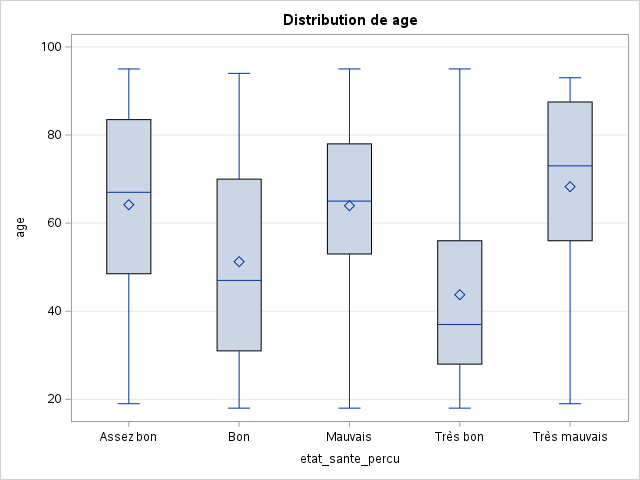

Bivariée ANOVA : Âge selon l'état de santé perçu

La procédure GLM

Test de l'étendue studentisée de Tukey (HSD) pour age

Note:This test controls the Type I experimentwise error rate.

| Alpha | 0.05 |
| --- | --- |
| Degrés de liberté de l'erreur | 495 |
| Erreur quadratique moyenne | 457.6809 |
| Valeur critique de l'étendue studentisée | 3.87192 |

| Comparaisons significatives au niveau 0.05 indiquées par ***. etat_sante_percu Comparaison | Comparaisons significatives au niveau 0.05 indiquées par ***. Différence/Entre/Moyennes | Comparaisons significatives au niveau 0.05 indiquées par ***. Simultané 95% - Intervalle de confiance | Comparaisons significatives au niveau 0.05 indiquées par ***. Simultané 95% - Intervalle de confiance | Comparaisons significatives au niveau 0.05 indiquées par ***. |
| --- | --- | --- | --- | --- |
| Très mauvais - Assez bon | 4.099 | -6.339 | 14.537 |  |
| Très mauvais - Mauvais | 4.326 | -6.664 | 15.316 |  |
| Très mauvais - Bon | 17.030 | 6.554 | 27.507 | *** |
| Très mauvais - Très bon | 24.529 | 12.949 | 36.108 | *** |
| Assez bon - Très mauvais | -4.099 | -14.537 | 6.339 |  |
| Assez bon - Mauvais | 0.227 | -7.401 | 7.855 |  |
| Assez bon - Bon | 12.931 | 6.063 | 19.799 | *** |
| Assez bon - Très bon | 20.429 | 11.973 | 28.885 | *** |
| Mauvais - Très mauvais | -4.326 | -15.316 | 6.664 |  |
| Mauvais - Assez bon | -0.227 | -7.855 | 7.401 |  |
| Mauvais - Bon | 12.704 | 5.023 | 20.385 | *** |
| Mauvais - Très bon | 20.203 | 11.074 | 29.331 | *** |
| Bon - Très mauvais | -17.030 | -27.507 | -6.554 | *** |
| Bon - Assez bon | -12.931 | -19.799 | -6.063 | *** |
| Bon - Mauvais | -12.704 | -20.385 | -5.023 | *** |
| Bon - Très bon | 7.498 | -1.005 | 16.002 |  |
| Très bon - Très mauvais | -24.529 | -36.108 | -12.949 | *** |
| Très bon - Assez bon | -20.429 | -28.885 | -11.973 | *** |
| Très bon - Mauvais | -20.203 | -29.331 | -11.074 | *** |
| Très bon - Bon | -7.498 | -16.002 | 1.005 |  |

Bivariée ANOVA : Revenus mensuels selon l'état de santé perçu

La procédure GLM

| Informations sur les niveaux de classe Classe | Informations sur les niveaux de classe Niveaux | Informations sur les niveaux de classe Valeurs |
| --- | --- | --- |
| etat_sante_percu | 5 | Assez bon Bon Mauvais Très bon Très mauvais |

| Nombre d'observations lues | 500 |
| --- | --- |
| Nombre d'observations utilisées | 500 |

Bivariée ANOVA : Revenus mensuels selon l'état de santé perçu

La procédure GLM

Variable dépendante : revenus_mensuels_euros

| Source | DDL | Somme des carrés | Carré moyen | Valeur F | Pr > F |
| --- | --- | --- | --- | --- | --- |
| Modèle | 4 | 5023036.5 | 1255759.1 | 1.66 | 0.1577 |
| Erreur | 495 | 374111913.7 | 755781.6 |  |  |
| Total sommes corrigées | 499 | 379134950.2 |  |  |  |

| R-carré | Coef de var | Racine MSE | revenus_mensuels_euros Moyenne |
| --- | --- | --- | --- |
| 0.013249 | 53.87486 | 869.3570 | 1613.660 |

| Source | DDL | Type I SS | Carré moyen | Valeur F | Pr > F |
| --- | --- | --- | --- | --- | --- |
| etat_sante_percu | 4 | 5023036.467 | 1255759.117 | 1.66 | 0.1577 |

| Source | DDL | Type III SS | Carré moyen | Valeur F | Pr > F |
| --- | --- | --- | --- | --- | --- |
| etat_sante_percu | 4 | 5023036.467 | 1255759.117 | 1.66 | 0.1577 |

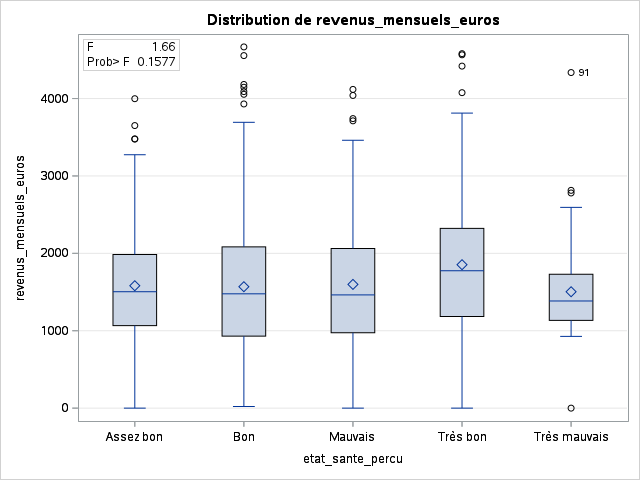

Bivariée ANOVA : Revenus mensuels selon l'état de santé perçu

La procédure GLM

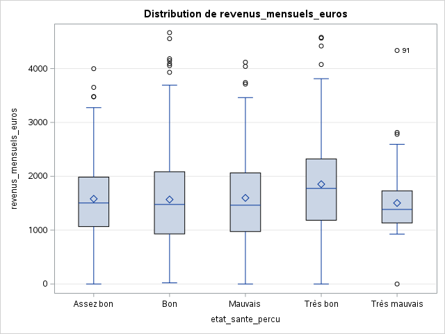

Bivariée ANOVA : Revenus mensuels selon l'état de santé perçu

La procédure GLM

Test de l'étendue studentisée de Tukey (HSD) pour revenus_mensuels_euros

Note:This test controls the Type I experimentwise error rate.

| Alpha | 0.05 |
| --- | --- |
| Degrés de liberté de l'erreur | 495 |
| Erreur quadratique moyenne | 755781.6 |
| Valeur critique de l'étendue studentisée | 3.87192 |

| Comparaisons significatives au niveau 0.05 indiquées par ***. etat_sante_percu Comparaison | Comparaisons significatives au niveau 0.05 indiquées par ***. Différence/Entre/Moyennes | Comparaisons significatives au niveau 0.05 indiquées par ***. Simultané 95% - Intervalle de confiance | Comparaisons significatives au niveau 0.05 indiquées par ***. Simultané 95% - Intervalle de confiance | Comparaisons significatives au niveau 0.05 indiquées par ***. |
| --- | --- | --- | --- | --- |
| Très bon - Mauvais | 254.7 | -116.3 | 625.6 |  |
| Très bon - Assez bon | 271.7 | -71.9 | 615.3 |  |
| Très bon - Bon | 284.5 | -61.0 | 630.1 |  |
| Très bon - Très mauvais | 349.6 | -121.0 | 820.1 |  |
| Mauvais - Très bon | -254.7 | -625.6 | 116.3 |  |
| Mauvais - Assez bon | 17.1 | -292.9 | 327.0 |  |
| Mauvais - Bon | 29.9 | -282.3 | 342.0 |  |
| Mauvais - Très mauvais | 94.9 | -351.7 | 541.5 |  |
| Assez bon - Très bon | -271.7 | -615.3 | 71.9 |  |
| Assez bon - Mauvais | -17.1 | -327.0 | 292.9 |  |
| Assez bon - Bon | 12.8 | -266.3 | 291.9 |  |
| Assez bon - Très mauvais | 77.8 | -346.3 | 502.0 |  |
| Bon - Très bon | -284.5 | -630.1 | 61.0 |  |
| Bon - Mauvais | -29.9 | -342.0 | 282.3 |  |
| Bon - Assez bon | -12.8 | -291.9 | 266.3 |  |
| Bon - Très mauvais | 65.1 | -360.7 | 490.8 |  |
| Très mauvais - Très bon | -349.6 | -820.1 | 121.0 |  |
| Très mauvais - Mauvais | -94.9 | -541.5 | 351.7 |  |
| Très mauvais - Assez bon | -77.8 | -502.0 | 346.3 |  |
| Très mauvais - Bon | -65.1 | -490.8 | 360.7 |  |

Bivariée ANOVA : IMC selon l'état de santé perçu

La procédure GLM

| Informations sur les niveaux de classe Classe | Informations sur les niveaux de classe Niveaux | Informations sur les niveaux de classe Valeurs |
| --- | --- | --- |
| etat_sante_percu | 5 | Assez bon Bon Mauvais Très bon Très mauvais |

| Nombre d'observations lues | 500 |
| --- | --- |
| Nombre d'observations utilisées | 500 |

Bivariée ANOVA : IMC selon l'état de santé perçu

La procédure GLM

Variable dépendante : imc

| Source | DDL | Somme des carrés | Carré moyen | Valeur F | Pr > F |
| --- | --- | --- | --- | --- | --- |
| Modèle | 4 | 159.895615 | 39.973904 | 2.25 | 0.0627 |
| Erreur | 495 | 8795.769565 | 17.769231 |  |  |
| Total sommes corrigées | 499 | 8955.665180 |  |  |  |

| R-carré | Coef de var | Racine MSE | imc Moyenne |
| --- | --- | --- | --- |
| 0.017854 | 16.83839 | 4.215357 | 25.03420 |

| Source | DDL | Type I SS | Carré moyen | Valeur F | Pr > F |
| --- | --- | --- | --- | --- | --- |
| etat_sante_percu | 4 | 159.8956150 | 39.9739038 | 2.25 | 0.0627 |

| Source | DDL | Type III SS | Carré moyen | Valeur F | Pr > F |
| --- | --- | --- | --- | --- | --- |
| etat_sante_percu | 4 | 159.8956150 | 39.9739038 | 2.25 | 0.0627 |

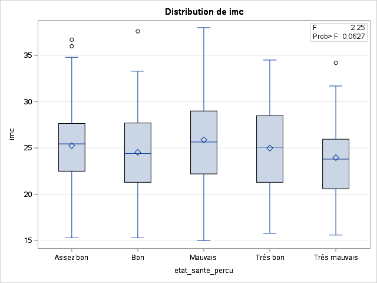

Bivariée ANOVA : IMC selon l'état de santé perçu

La procédure GLM

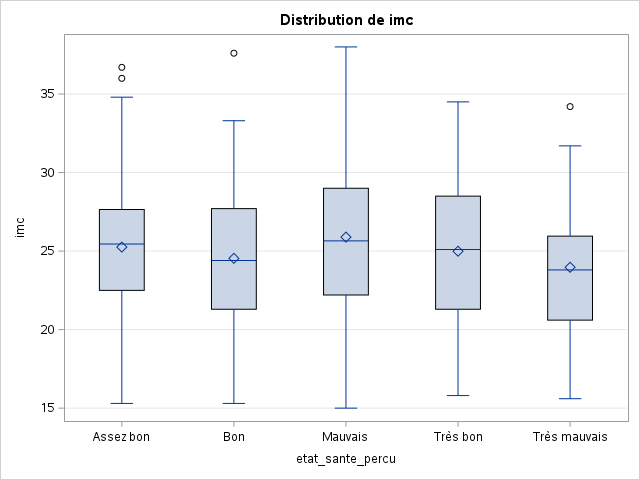

Bivariée ANOVA : IMC selon l'état de santé perçu

La procédure GLM

Test de l'étendue studentisée de Tukey (HSD) pour imc

Note:This test controls the Type I experimentwise error rate.

| Alpha | 0.05 |
| --- | --- |
| Degrés de liberté de l'erreur | 495 |
| Erreur quadratique moyenne | 17.76923 |
| Valeur critique de l'étendue studentisée | 3.87192 |

| Comparaisons significatives au niveau 0.05 indiquées par ***. etat_sante_percu Comparaison | Comparaisons significatives au niveau 0.05 indiquées par ***. Différence/Entre/Moyennes | Comparaisons significatives au niveau 0.05 indiquées par ***. Simultané 95% - Intervalle de confiance | Comparaisons significatives au niveau 0.05 indiquées par ***. Simultané 95% - Intervalle de confiance | Comparaisons significatives au niveau 0.05 indiquées par ***. |
| --- | --- | --- | --- | --- |
| Mauvais - Assez bon | 0.6361 | -0.8669 | 2.1391 |  |
| Mauvais - Très bon | 0.8993 | -0.8994 | 2.6979 |  |
| Mauvais - Bon | 1.3524 | -0.1611 | 2.8658 |  |
| Mauvais - Très mauvais | 1.9233 | -0.2421 | 4.0887 |  |
| Assez bon - Mauvais | -0.6361 | -2.1391 | 0.8669 |  |
| Assez bon - Très bon | 0.2632 | -1.4029 | 1.9293 |  |
| Assez bon - Bon | 0.7163 | -0.6370 | 2.0696 |  |
| Assez bon - Très mauvais | 1.2872 | -0.7694 | 3.3439 |  |
| Très bon - Mauvais | -0.8993 | -2.6979 | 0.8994 |  |
| Très bon - Assez bon | -0.2632 | -1.9293 | 1.4029 |  |
| Très bon - Bon | 0.4531 | -1.2225 | 2.1286 |  |
| Très bon - Très mauvais | 1.0240 | -1.2576 | 3.3057 |  |
| Bon - Mauvais | -1.3524 | -2.8658 | 0.1611 |  |
| Bon - Assez bon | -0.7163 | -2.0696 | 0.6370 |  |
| Bon - Très bon | -0.4531 | -2.1286 | 1.2225 |  |
| Bon - Très mauvais | 0.5710 | -1.4933 | 2.6353 |  |
| Très mauvais - Mauvais | -1.9233 | -4.0887 | 0.2421 |  |
| Très mauvais - Assez bon | -1.2872 | -3.3439 | 0.7694 |  |
| Très mauvais - Très bon | -1.0240 | -3.3057 | 1.2576 |  |
| Très mauvais - Bon | -0.5710 | -2.6353 | 1.4933 |  |

Bivariée ANOVA : Dépenses de santé selon l'état de santé perçu

La procédure GLM

| Informations sur les niveaux de classe Classe | Informations sur les niveaux de classe Niveaux | Informations sur les niveaux de classe Valeurs |
| --- | --- | --- |
| etat_sante_percu | 5 | Assez bon Bon Mauvais Très bon Très mauvais |

| Nombre d'observations lues | 500 |
| --- | --- |
| Nombre d'observations utilisées | 500 |

Bivariée ANOVA : Dépenses de santé selon l'état de santé perçu

La procédure GLM

Variable dépendante : depenses_sante_annuelles_euros

| Source | DDL | Somme des carrés | Carré moyen | Valeur F | Pr > F |
| --- | --- | --- | --- | --- | --- |
| Modèle | 4 | 25046682.9 | 6261670.7 | 16.23 | <.0001 |
| Erreur | 495 | 190971347.6 | 385800.7 |  |  |
| Total sommes corrigées | 499 | 216018030.5 |  |  |  |

| R-carré | Coef de var | Racine MSE | depenses_sante_annuelles_euros Moyenne |
| --- | --- | --- | --- |
| 0.115947 | 33.75856 | 621.1286 | 1839.914 |

| Source | DDL | Type I SS | Carré moyen | Valeur F | Pr > F |
| --- | --- | --- | --- | --- | --- |
| etat_sante_percu | 4 | 25046682.95 | 6261670.74 | 16.23 | <.0001 |

| Source | DDL | Type III SS | Carré moyen | Valeur F | Pr > F |
| --- | --- | --- | --- | --- | --- |
| etat_sante_percu | 4 | 25046682.95 | 6261670.74 | 16.23 | <.0001 |

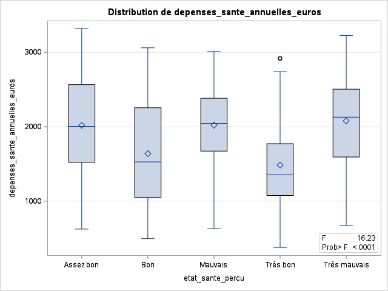

Bivariée ANOVA : Dépenses de santé selon l'état de santé perçu

La procédure GLM

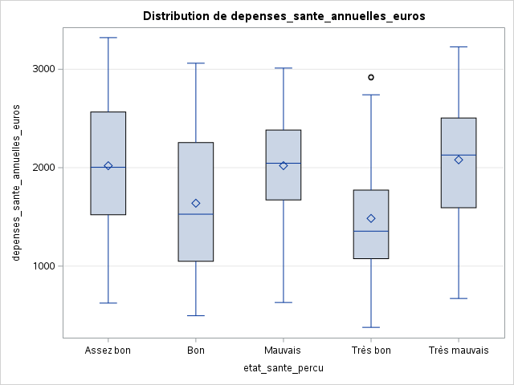

Bivariée ANOVA : Dépenses de santé selon l'état de santé perçu

La procédure GLM

Test de l'étendue studentisée de Tukey (HSD) pour depenses_sante_annuelles_euros

Note:This test controls the Type I experimentwise error rate.

| Alpha | 0.05 |
| --- | --- |
| Degrés de liberté de l'erreur | 495 |
| Erreur quadratique moyenne | 385800.7 |
| Valeur critique de l'étendue studentisée | 3.87192 |

| Comparaisons significatives au niveau 0.05 indiquées par ***. etat_sante_percu Comparaison | Comparaisons significatives au niveau 0.05 indiquées par ***. Différence/Entre/Moyennes | Comparaisons significatives au niveau 0.05 indiquées par ***. Simultané 95% - Intervalle de confiance | Comparaisons significatives au niveau 0.05 indiquées par ***. Simultané 95% - Intervalle de confiance | Comparaisons significatives au niveau 0.05 indiquées par ***. |
| --- | --- | --- | --- | --- |
| Très mauvais - Mauvais | 59.12 | -259.95 | 378.19 |  |
| Très mauvais - Assez bon | 59.63 | -243.41 | 362.68 |  |
| Très mauvais - Bon | 440.83 | 136.66 | 745.00 | *** |
| Très mauvais - Très bon | 595.12 | 258.92 | 931.32 | *** |
| Mauvais - Très mauvais | -59.12 | -378.19 | 259.95 |  |
| Mauvais - Assez bon | 0.51 | -220.96 | 221.98 |  |
| Mauvais - Bon | 381.71 | 158.70 | 604.72 | *** |
| Mauvais - Très bon | 536.00 | 270.97 | 801.03 | *** |
| Assez bon - Très mauvais | -59.63 | -362.68 | 243.41 |  |
| Assez bon - Mauvais | -0.51 | -221.98 | 220.96 |  |
| Assez bon - Bon | 381.20 | 181.79 | 580.61 | *** |
| Assez bon - Très bon | 535.49 | 289.99 | 780.99 | *** |
| Bon - Très mauvais | -440.83 | -745.00 | -136.66 | *** |
| Bon - Mauvais | -381.71 | -604.72 | -158.70 | *** |
| Bon - Assez bon | -381.20 | -580.61 | -181.79 | *** |
| Bon - Très bon | 154.29 | -92.60 | 401.18 |  |
| Très bon - Très mauvais | -595.12 | -931.32 | -258.92 | *** |
| Très bon - Mauvais | -536.00 | -801.03 | -270.97 | *** |
| Très bon - Assez bon | -535.49 | -780.99 | -289.99 | *** |
| Très bon - Bon | -154.29 | -401.18 | 92.60 |  |

Bivariée ANOVA : Consultations selon l'état de santé perçu

La procédure GLM

| Informations sur les niveaux de classe Classe | Informations sur les niveaux de classe Niveaux | Informations sur les niveaux de classe Valeurs |
| --- | --- | --- |
| etat_sante_percu | 5 | Assez bon Bon Mauvais Très bon Très mauvais |

| Nombre d'observations lues | 500 |
| --- | --- |
| Nombre d'observations utilisées | 500 |

Bivariée ANOVA : Consultations selon l'état de santé perçu

La procédure GLM

Variable dépendante : nombre_consultations_annuelles

| Source | DDL | Somme des carrés | Carré moyen | Valeur F | Pr > F |
| --- | --- | --- | --- | --- | --- |
| Modèle | 4 | 156.432366 | 39.108092 | 8.14 | <.0001 |
| Erreur | 495 | 2376.949634 | 4.801918 |  |  |
| Total sommes corrigées | 499 | 2533.382000 |  |  |  |

| R-carré | Coef de var | Racine MSE | nombre_consultations_annuelles Moyenne |
| --- | --- | --- | --- |
| 0.061748 | 49.87092 | 2.191328 | 4.394000 |

| Source | DDL | Type I SS | Carré moyen | Valeur F | Pr > F |
| --- | --- | --- | --- | --- | --- |
| etat_sante_percu | 4 | 156.4323662 | 39.1080915 | 8.14 | <.0001 |

| Source | DDL | Type III SS | Carré moyen | Valeur F | Pr > F |
| --- | --- | --- | --- | --- | --- |
| etat_sante_percu | 4 | 156.4323662 | 39.1080915 | 8.14 | <.0001 |

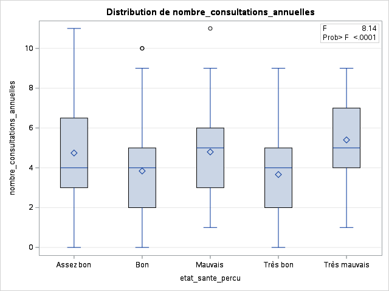

Bivariée ANOVA : Consultations selon l'état de santé perçu

La procédure GLM

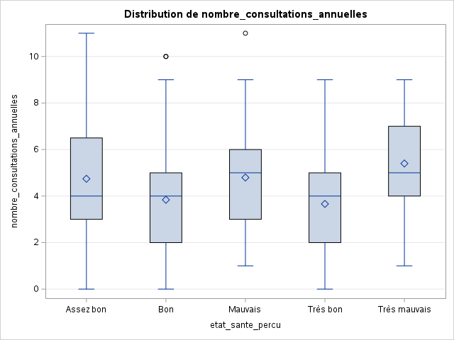

Bivariée ANOVA : Consultations selon l'état de santé perçu

La procédure GLM

Test de l'étendue studentisée de Tukey (HSD) pour nombre_consultations_annuelles

Note:This test controls the Type I experimentwise error rate.

| Alpha | 0.05 |
| --- | --- |
| Degrés de liberté de l'erreur | 495 |
| Erreur quadratique moyenne | 4.801918 |
| Valeur critique de l'étendue studentisée | 3.87192 |

| Comparaisons significatives au niveau 0.05 indiquées par ***. etat_sante_percu Comparaison | Comparaisons significatives au niveau 0.05 indiquées par ***. Différence/Entre/Moyennes | Comparaisons significatives au niveau 0.05 indiquées par ***. Simultané 95% - Intervalle de confiance | Comparaisons significatives au niveau 0.05 indiquées par ***. Simultané 95% - Intervalle de confiance | Comparaisons significatives au niveau 0.05 indiquées par ***. |
| --- | --- | --- | --- | --- |
| Très mauvais - Mauvais | 0.6041 | -0.5216 | 1.7298 |  |
| Très mauvais - Assez bon | 0.6568 | -0.4124 | 1.7259 |  |
| Très mauvais - Bon | 1.5608 | 0.4877 | 2.6340 | *** |
| Très mauvais - Très bon | 1.7380 | 0.5519 | 2.9241 | *** |
| Mauvais - Très mauvais | -0.6041 | -1.7298 | 0.5216 |  |
| Mauvais - Assez bon | 0.0527 | -0.7287 | 0.8340 |  |
| Mauvais - Bon | 0.9568 | 0.1700 | 1.7435 | *** |
| Mauvais - Très bon | 1.1339 | 0.1989 | 2.0690 | *** |
| Assez bon - Très mauvais | -0.6568 | -1.7259 | 0.4124 |  |
| Assez bon - Mauvais | -0.0527 | -0.8340 | 0.7287 |  |
| Assez bon - Bon | 0.9041 | 0.2006 | 1.6076 | *** |
| Assez bon - Très bon | 1.0813 | 0.2151 | 1.9474 | *** |
| Bon - Très mauvais | -1.5608 | -2.6340 | -0.4877 | *** |
| Bon - Mauvais | -0.9568 | -1.7435 | -0.1700 | *** |
| Bon - Assez bon | -0.9041 | -1.6076 | -0.2006 | *** |
| Bon - Très bon | 0.1772 | -0.6938 | 1.0482 |  |
| Très bon - Très mauvais | -1.7380 | -2.9241 | -0.5519 | *** |
| Très bon - Mauvais | -1.1339 | -2.0690 | -0.1989 | *** |
| Très bon - Assez bon | -1.0813 | -1.9474 | -0.2151 | *** |
| Très bon - Bon | -0.1772 | -1.0482 | 0.6938 |  |

Bivariée ANOVA : Médicaments réguliers selon l'état de santé perçu

La procédure GLM

| Informations sur les niveaux de classe Classe | Informations sur les niveaux de classe Niveaux | Informations sur les niveaux de classe Valeurs |
| --- | --- | --- |
| etat_sante_percu | 5 | Assez bon Bon Mauvais Très bon Très mauvais |

| Nombre d'observations lues | 500 |
| --- | --- |
| Nombre d'observations utilisées | 500 |

Bivariée ANOVA : Médicaments réguliers selon l'état de santé perçu

La procédure GLM

Variable dépendante : nombre_medicaments_reguliers

| Source | DDL | Somme des carrés | Carré moyen | Valeur F | Pr > F |
| --- | --- | --- | --- | --- | --- |
| Modèle | 4 | 96.760003 | 24.190001 | 10.42 | <.0001 |
| Erreur | 495 | 1148.951997 | 2.321115 |  |  |
| Total sommes corrigées | 499 | 1245.712000 |  |  |  |

| R-carré | Coef de var | Racine MSE | nombre_medicaments_reguliers Moyenne |
| --- | --- | --- | --- |
| 0.077674 | 75.27276 | 1.523521 | 2.024000 |

| Source | DDL | Type I SS | Carré moyen | Valeur F | Pr > F |
| --- | --- | --- | --- | --- | --- |
| etat_sante_percu | 4 | 96.76000265 | 24.19000066 | 10.42 | <.0001 |

| Source | DDL | Type III SS | Carré moyen | Valeur F | Pr > F |
| --- | --- | --- | --- | --- | --- |
| etat_sante_percu | 4 | 96.76000265 | 24.19000066 | 10.42 | <.0001 |

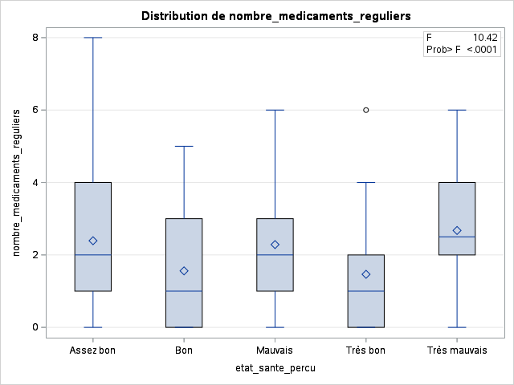

Bivariée ANOVA : Médicaments réguliers selon l'état de santé perçu

La procédure GLM

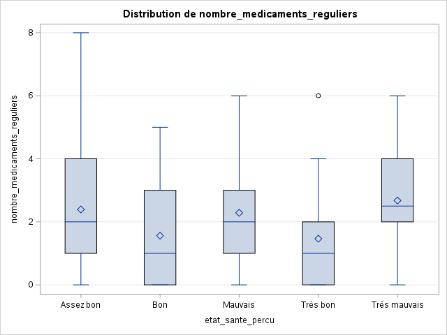

Bivariée ANOVA : Médicaments réguliers selon l'état de santé perçu

La procédure GLM

Test de l'étendue studentisée de Tukey (HSD) pour nombre_medicaments_reguliers

Note:This test controls the Type I experimentwise error rate.

| Alpha | 0.05 |
| --- | --- |
| Degrés de liberté de l'erreur | 495 |
| Erreur quadratique moyenne | 2.321115 |
| Valeur critique de l'étendue studentisée | 3.87192 |

| Comparaisons significatives au niveau 0.05 indiquées par ***. etat_sante_percu Comparaison | Comparaisons significatives au niveau 0.05 indiquées par ***. Différence/Entre/Moyennes | Comparaisons significatives au niveau 0.05 indiquées par ***. Simultané 95% - Intervalle de confiance | Comparaisons significatives au niveau 0.05 indiquées par ***. Simultané 95% - Intervalle de confiance | Comparaisons significatives au niveau 0.05 indiquées par ***. |
| --- | --- | --- | --- | --- |
| Très mauvais - Assez bon | 0.2831 | -0.4602 | 1.0264 |  |
| Très mauvais - Mauvais | 0.3893 | -0.3933 | 1.1719 |  |
| Très mauvais - Bon | 1.1156 | 0.3695 | 1.8616 | *** |
| Très mauvais - Très bon | 1.2102 | 0.3856 | 2.0348 | *** |
| Assez bon - Très mauvais | -0.2831 | -1.0264 | 0.4602 |  |
| Assez bon - Mauvais | 0.1062 | -0.4371 | 0.6494 |  |
| Assez bon - Bon | 0.8325 | 0.3433 | 1.3216 | *** |
| Assez bon - Très bon | 0.9271 | 0.3249 | 1.5293 | *** |
| Mauvais - Très mauvais | -0.3893 | -1.1719 | 0.3933 |  |
| Mauvais - Assez bon | -0.1062 | -0.6494 | 0.4371 |  |
| Mauvais - Bon | 0.7263 | 0.1793 | 1.2733 | *** |
| Mauvais - Très bon | 0.8209 | 0.1709 | 1.4710 | *** |
| Bon - Très mauvais | -1.1156 | -1.8616 | -0.3695 | *** |
| Bon - Assez bon | -0.8325 | -1.3216 | -0.3433 | *** |
| Bon - Mauvais | -0.7263 | -1.2733 | -0.1793 | *** |
| Bon - Très bon | 0.0947 | -0.5109 | 0.7002 |  |
| Très bon - Très mauvais | -1.2102 | -2.0348 | -0.3856 | *** |
| Très bon - Assez bon | -0.9271 | -1.5293 | -0.3249 | *** |
| Très bon - Mauvais | -0.8209 | -1.4710 | -0.1709 | *** |
| Très bon - Bon | -0.0947 | -0.7002 | 0.5109 |  |

Test de Kruskal-Wallis : Variables quantitatives selon l'état de santé perçu

La procédure NPAR1WAY

| Scores de Wilcoxon (Sommes du rang) pour la variable age Classification par variable etat_sante_percu etat_sante_percu | Scores de Wilcoxon (Sommes du rang) pour la variable age Classification par variable etat_sante_percu N | Scores de Wilcoxon (Sommes du rang) pour la variable age Classification par variable etat_sante_percu Somme des scores | Scores de Wilcoxon (Sommes du rang) pour la variable age Classification par variable etat_sante_percu Attendue sous H0 | Scores de Wilcoxon (Sommes du rang) pour la variable age Classification par variable etat_sante_percu Ecart-type sous H0 | Scores de Wilcoxon (Sommes du rang) pour la variable age Classification par variable etat_sante_percu Score de la moyenne |
| --- | --- | --- | --- | --- | --- |
| Assez bon | 148 | 42910.50 | 37074.00 | 1474.61034 | 289.935811 |
| Bon | 143 | 29965.00 | 35821.50 | 1459.74573 | 209.545455 |
| Très bon | 71 | 11512.50 | 17785.50 | 1127.54246 | 162.147887 |
| Très mauvais | 40 | 12701.00 | 10020.00 | 876.36293 | 317.525000 |
| Mauvais | 98 | 28161.00 | 24549.00 | 1282.33398 | 287.357143 |

Les scores moyens ont été utilisés pour les liens.

| Test de Kruskal-Wallis khi-2 | Test de Kruskal-Wallis DDL | Test de Kruskal-Wallis Pr > khi-2 |
| --- | --- | --- |
| 64.0670 | 4 | <.0001 |

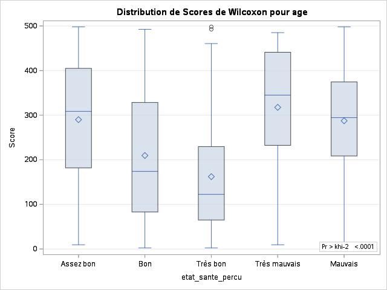

Test de Kruskal-Wallis : Variables quantitatives selon l'état de santé perçu

La procédure NPAR1WAY

| Scores de Wilcoxon (Sommes du rang) pour la variable revenus_mensuels_euros Classification par variable etat_sante_percu etat_sante_percu | Scores de Wilcoxon (Sommes du rang) pour la variable revenus_mensuels_euros Classification par variable etat_sante_percu N | Scores de Wilcoxon (Sommes du rang) pour la variable revenus_mensuels_euros Classification par variable etat_sante_percu Somme des scores | Scores de Wilcoxon (Sommes du rang) pour la variable revenus_mensuels_euros Classification par variable etat_sante_percu Attendue sous H0 | Scores de Wilcoxon (Sommes du rang) pour la variable revenus_mensuels_euros Classification par variable etat_sante_percu Ecart-type sous H0 | Scores de Wilcoxon (Sommes du rang) pour la variable revenus_mensuels_euros Classification par variable etat_sante_percu Score de la moyenne |
| --- | --- | --- | --- | --- | --- |
| Assez bon | 148 | 37159.50 | 37074.00 | 1474.78807 | 251.077703 |
| Bon | 143 | 34236.50 | 35821.50 | 1459.92167 | 239.416084 |
| Très bon | 71 | 20124.50 | 17785.50 | 1127.67836 | 283.443662 |
| Très mauvais | 40 | 9337.50 | 10020.00 | 876.46855 | 233.437500 |
| Mauvais | 98 | 24392.00 | 24549.00 | 1282.48853 | 248.897959 |

Les scores moyens ont été utilisés pour les liens.

| Test de Kruskal-Wallis khi-2 | Test de Kruskal-Wallis DDL | Test de Kruskal-Wallis Pr > khi-2 |
| --- | --- | --- |
| 5.1051 | 4 | 0.2767 |

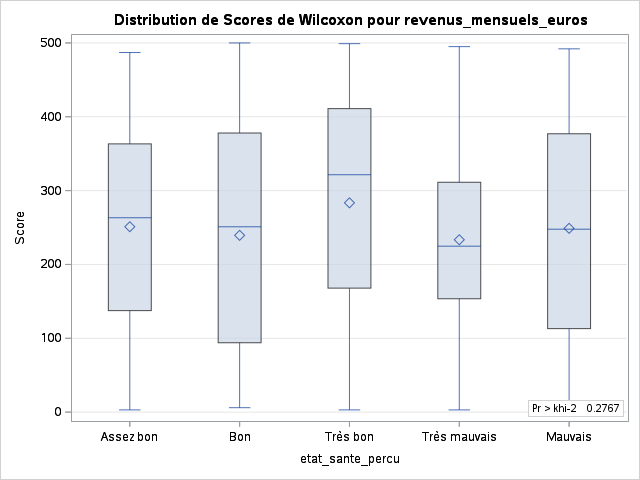

Test de Kruskal-Wallis : Variables quantitatives selon l'état de santé perçu

La procédure NPAR1WAY

| Scores de Wilcoxon (Sommes du rang) pour la variable imc Classification par variable etat_sante_percu etat_sante_percu | Scores de Wilcoxon (Sommes du rang) pour la variable imc Classification par variable etat_sante_percu N | Scores de Wilcoxon (Sommes du rang) pour la variable imc Classification par variable etat_sante_percu Somme des scores | Scores de Wilcoxon (Sommes du rang) pour la variable imc Classification par variable etat_sante_percu Attendue sous H0 | Scores de Wilcoxon (Sommes du rang) pour la variable imc Classification par variable etat_sante_percu Ecart-type sous H0 | Scores de Wilcoxon (Sommes du rang) pour la variable imc Classification par variable etat_sante_percu Score de la moyenne |
| --- | --- | --- | --- | --- | --- |
| Assez bon | 148 | 38399.00 | 37074.00 | 1474.72804 | 259.452703 |
| Bon | 143 | 33440.00 | 35821.50 | 1459.86224 | 233.846154 |
| Très bon | 71 | 17827.00 | 17785.50 | 1127.63246 | 251.084507 |
| Très mauvais | 40 | 8505.50 | 10020.00 | 876.43288 | 212.637500 |
| Mauvais | 98 | 27078.50 | 24549.00 | 1282.43633 | 276.311224 |

Les scores moyens ont été utilisés pour les liens.

| Test de Kruskal-Wallis khi-2 | Test de Kruskal-Wallis DDL | Test de Kruskal-Wallis Pr > khi-2 |
| --- | --- | --- |
| 8.3447 | 4 | 0.0797 |

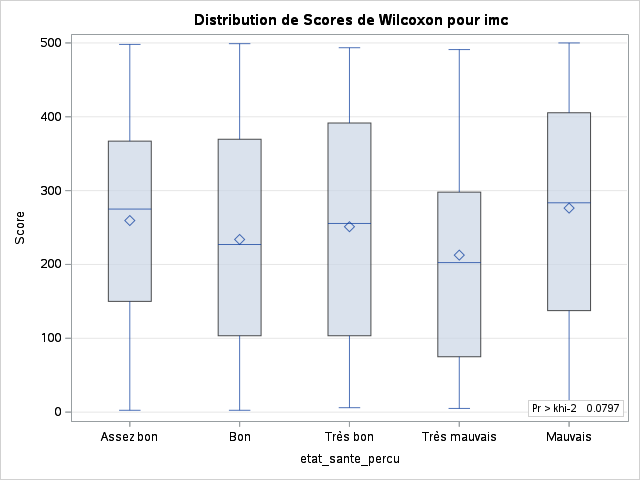

Test de Kruskal-Wallis : Variables quantitatives selon l'état de santé perçu

La procédure NPAR1WAY

| Scores de Wilcoxon (Sommes du rang) pour la variable depenses_sante_annuelles_euros Classification par variable etat_sante_percu etat_sante_percu | Scores de Wilcoxon (Sommes du rang) pour la variable depenses_sante_annuelles_euros Classification par variable etat_sante_percu N | Scores de Wilcoxon (Sommes du rang) pour la variable depenses_sante_annuelles_euros Classification par variable etat_sante_percu Somme des scores | Scores de Wilcoxon (Sommes du rang) pour la variable depenses_sante_annuelles_euros Classification par variable etat_sante_percu Attendue sous H0 | Scores de Wilcoxon (Sommes du rang) pour la variable depenses_sante_annuelles_euros Classification par variable etat_sante_percu Ecart-type sous H0 | Scores de Wilcoxon (Sommes du rang) pour la variable depenses_sante_annuelles_euros Classification par variable etat_sante_percu Score de la moyenne |
| --- | --- | --- | --- | --- | --- |
| Assez bon | 148 | 42809.50 | 37074.00 | 1474.79080 | 289.253378 |
| Bon | 143 | 29445.50 | 35821.50 | 1459.92436 | 205.912587 |
| Très bon | 71 | 12139.00 | 17785.50 | 1127.68045 | 170.971831 |
| Très mauvais | 40 | 12122.00 | 10020.00 | 876.47017 | 303.050000 |
| Mauvais | 98 | 28734.00 | 24549.00 | 1282.49090 | 293.204082 |

Les scores moyens ont été utilisés pour les liens.

| Test de Kruskal-Wallis khi-2 | Test de Kruskal-Wallis DDL | Test de Kruskal-Wallis Pr > khi-2 |
| --- | --- | --- |
| 59.6307 | 4 | <.0001 |

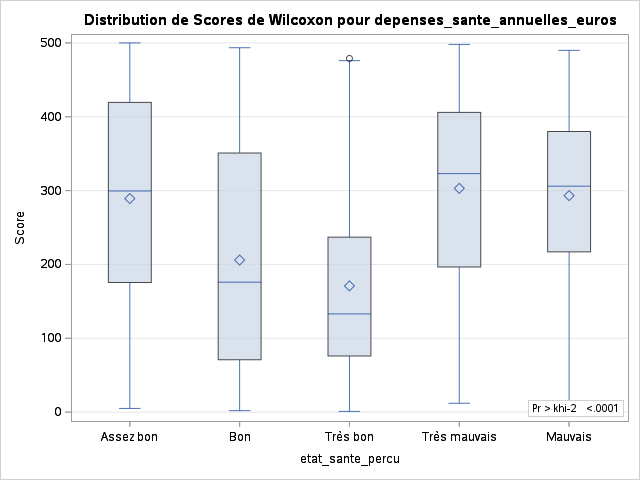

Test de Kruskal-Wallis : Variables quantitatives selon l'état de santé perçu

La procédure NPAR1WAY

| Scores de Wilcoxon (Sommes du rang) pour la variable nombre_consultations_annuelles Classification par variable etat_sante_percu etat_sante_percu | Scores de Wilcoxon (Sommes du rang) pour la variable nombre_consultations_annuelles Classification par variable etat_sante_percu N | Scores de Wilcoxon (Sommes du rang) pour la variable nombre_consultations_annuelles Classification par variable etat_sante_percu Somme des scores | Scores de Wilcoxon (Sommes du rang) pour la variable nombre_consultations_annuelles Classification par variable etat_sante_percu Attendue sous H0 | Scores de Wilcoxon (Sommes du rang) pour la variable nombre_consultations_annuelles Classification par variable etat_sante_percu Ecart-type sous H0 | Scores de Wilcoxon (Sommes du rang) pour la variable nombre_consultations_annuelles Classification par variable etat_sante_percu Score de la moyenne |
| --- | --- | --- | --- | --- | --- |
| Assez bon | 148 | 40162.00 | 37074.00 | 1460.57256 | 271.364865 |
| Bon | 143 | 30760.00 | 35821.50 | 1445.84946 | 215.104895 |
| Très bon | 71 | 14503.50 | 17785.50 | 1116.80865 | 204.274648 |
| Très mauvais | 40 | 12706.50 | 10020.00 | 868.02026 | 317.662500 |
| Mauvais | 98 | 27118.00 | 24549.00 | 1270.12661 | 276.714286 |

Les scores moyens ont été utilisés pour les liens.

| Test de Kruskal-Wallis khi-2 | Test de Kruskal-Wallis DDL | Test de Kruskal-Wallis Pr > khi-2 |
| --- | --- | --- |
| 31.4085 | 4 | <.0001 |

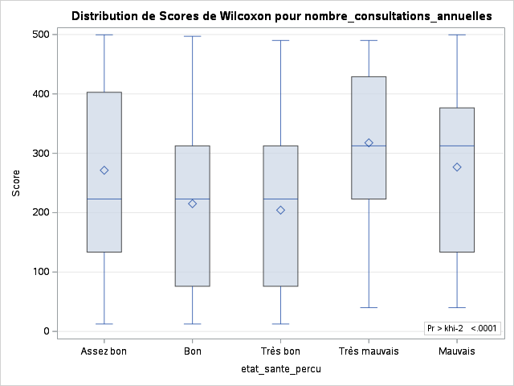

Test de Kruskal-Wallis : Variables quantitatives selon l'état de santé perçu

La procédure NPAR1WAY

| Scores de Wilcoxon (Sommes du rang) pour la variable nombre_medicaments_reguliers Classification par variable etat_sante_percu etat_sante_percu | Scores de Wilcoxon (Sommes du rang) pour la variable nombre_medicaments_reguliers Classification par variable etat_sante_percu N | Scores de Wilcoxon (Sommes du rang) pour la variable nombre_medicaments_reguliers Classification par variable etat_sante_percu Somme des scores | Scores de Wilcoxon (Sommes du rang) pour la variable nombre_medicaments_reguliers Classification par variable etat_sante_percu Attendue sous H0 | Scores de Wilcoxon (Sommes du rang) pour la variable nombre_medicaments_reguliers Classification par variable etat_sante_percu Ecart-type sous H0 | Scores de Wilcoxon (Sommes du rang) pour la variable nombre_medicaments_reguliers Classification par variable etat_sante_percu Score de la moyenne |
| --- | --- | --- | --- | --- | --- |
| Assez bon | 148 | 42150.00 | 37074.00 | 1447.66367 | 284.797297 |
| Bon | 143 | 29927.00 | 35821.50 | 1433.07069 | 209.279720 |
| Très bon | 71 | 14216.00 | 17785.50 | 1106.93803 | 200.225352 |
| Très mauvais | 40 | 12408.50 | 10020.00 | 860.34848 | 310.212500 |
| Mauvais | 98 | 26548.50 | 24549.00 | 1258.90092 | 270.903061 |

Les scores moyens ont été utilisés pour les liens.

| Test de Kruskal-Wallis khi-2 | Test de Kruskal-Wallis DDL | Test de Kruskal-Wallis Pr > khi-2 |
| --- | --- | --- |
| 38.7758 | 4 | <.0001 |

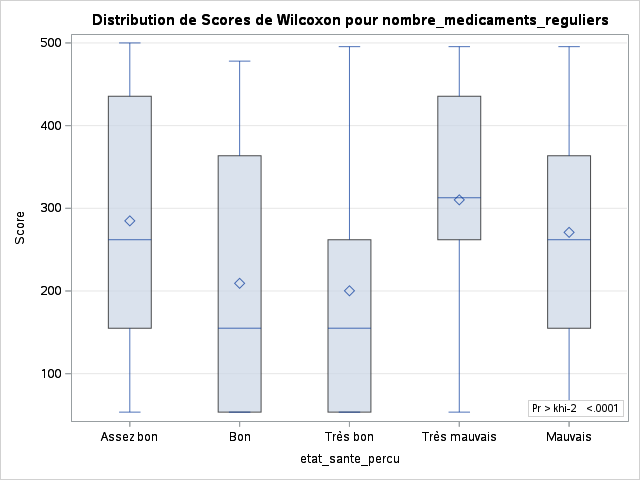

Corrélation de Spearman : score_sante vs variables quantitatives

La procédure CORR

| 7 Avec les variables : | age revenus_mensuels_euros imc depenses_sante_annuelles_euros nombre_consultations_annuelles nombre_medicaments_reguliers nombre_enfants |
| --- | --- |
| 1 Variables : | score_sante |

| Statistiques simples Variable | Statistiques simples N | Statistiques simples Moyenne | Statistiques simples Ec-type | Statistiques simples Médiane | Statistiques simples Minimum | Statistiques simples Maximum |
| --- | --- | --- | --- | --- | --- | --- |
| age | 500 | 57.86000 | 22.86267 | 58.00000 | 18.00000 | 95.00000 |
| revenus_mensuels_euros | 500 | 1614 | 871.65904 | 1474 | 0 | 4667 |
| imc | 500 | 25.03420 | 4.23642 | 25.00000 | 15.00000 | 38.00000 |
| depenses_sante_annuelles_euros | 500 | 1840 | 657.95278 | 1828 | 377.89000 | 3321 |
| nombre_consultations_annuelles | 500 | 4.39400 | 2.25320 | 4.00000 | 0 | 11.00000 |
| nombre_medicaments_reguliers | 500 | 2.02400 | 1.58001 | 2.00000 | 0 | 8.00000 |
| nombre_enfants | 500 | 1.57600 | 1.39000 | 1.00000 | 0 | 5.00000 |
| score_sante | 500 | 3.21400 | 1.15189 | 3.00000 | 1.00000 | 5.00000 |

| Coefficients de corrélation de Spearman, N = 500 Proba > \|r\| sous H0: Rho=0 | Coefficients de corrélation de Spearman, N = 500 Proba > \|r\| sous H0: Rho=0 score_sante |
| --- | --- |
| age | -0.33625 <.0001 |
| revenus_mensuels_euros | 0.05054 0.2593 |
| imc | -0.03529 0.4310 |
| depenses_sante_annuelles_euros | -0.32400 <.0001 |
| nombre_consultations_annuelles | -0.23968 <.0001 |
| nombre_medicaments_reguliers | -0.24853 <.0001 |
| nombre_enfants | 0.01796 0.6888 |

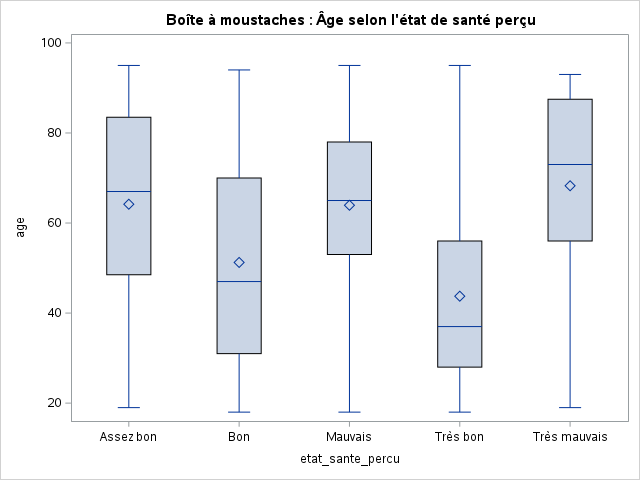

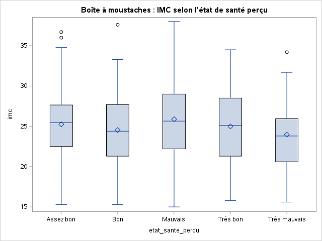

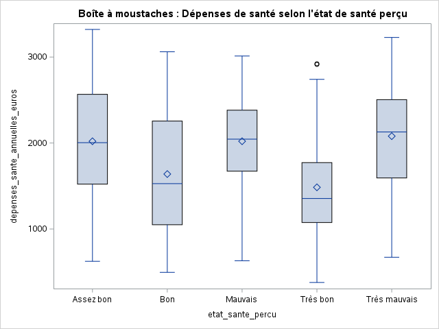

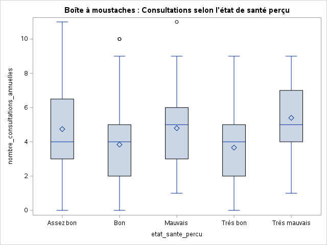

Régression linéaire — Modèle complet (score_sante)

La procédure REG

Modèle : MODEL1

Variable dépendante : score_sante

| Nb d'observations lues | 500 |
| --- | --- |
| Nb d'obs. utilisées | 500 |

| Analyse de variance Source | Analyse de variance DDL | Analyse de variance Somme des carrés | Analyse de variance Moyenne quadratique | Analyse de variance Valeur F | Analyse de variance Pr > F |
| --- | --- | --- | --- | --- | --- |
| Modèle | 7 | 84.25700 | 12.03671 | 10.25 | <.0001 |
| Erreur | 492 | 577.84500 | 1.17448 |  |  |
| Total sommes corrigées | 499 | 662.10200 |  |  |  |

| Root MSE | 1.08374 | R carré | 0.1273 |
| --- | --- | --- | --- |
| Moyenne dépendante | 3.21400 | R car. ajust. | 0.1148 |
| Coeff Var | 33.71920 |  |  |

| Paramètres estimés Variable | Paramètres estimés DDL | Paramètres estimés Valeur estimée des paramètres | Paramètres estimés Erreur type | Paramètres estimés Valeur du test t | Paramètres estimés Pr > \|t\| |
| --- | --- | --- | --- | --- | --- |
| Intercept | 1 | 4.37973 | 0.34396 | 12.73 | <.0001 |
| age | 1 | -0.01035 | 0.00519 | -1.99 | 0.0466 |
| revenus_mensuels_euros | 1 | 0.00005840 | 0.00005595 | 1.04 | 0.2971 |
| depenses_sante_annuelles_euros | 1 | -0.00004893 | 0.00016807 | -0.29 | 0.7711 |
| nombre_consultations_annuelles | 1 | -0.05045 | 0.02490 | -2.03 | 0.0433 |
| nombre_medicaments_reguliers | 1 | -0.06739 | 0.03708 | -1.82 | 0.0698 |
| imc | 1 | -0.00856 | 0.01153 | -0.74 | 0.4580 |
| nombre_enfants | 1 | 0.00098626 | 0.03505 | 0.03 | 0.9776 |

Régression linéaire — Modèle complet (score_sante)

La procédure REG

Modèle : MODEL1

Variable dépendante : score_sante

Régression linéaire — Modèle réduit (score_sante)

La procédure REG

Modèle : MODEL1

Variable dépendante : score_sante

| Nb d'observations lues | 500 |
| --- | --- |
| Nb d'obs. utilisées | 500 |

| Analyse de variance Source | Analyse de variance DDL | Analyse de variance Somme des carrés | Analyse de variance Moyenne quadratique | Analyse de variance Valeur F | Analyse de variance Pr > F |
| --- | --- | --- | --- | --- | --- |
| Modèle | 3 | 82.17263 | 27.39088 | 23.43 | <.0001 |
| Erreur | 496 | 579.92937 | 1.16921 |  |  |
| Total sommes corrigées | 499 | 662.10200 |  |  |  |

| Root MSE | 1.08130 | R carré | 0.1241 |
| --- | --- | --- | --- |
| Moyenne dépendante | 3.21400 | R car. ajust. | 0.1188 |
| Coeff Var | 33.64347 |  |  |

| Paramètres estimés Variable | Paramètres estimés DDL | Paramètres estimés Valeur estimée des paramètres | Paramètres estimés Erreur type | Paramètres estimés Valeur du test t | Paramètres estimés Pr > \|t\| |
| --- | --- | --- | --- | --- | --- |
| Intercept | 1 | 4.25240 | 0.13733 | 30.97 | <.0001 |
| age | 1 | -0.01159 | 0.00286 | -4.05 | <.0001 |
| nombre_consultations_annuelles | 1 | -0.05060 | 0.02482 | -2.04 | 0.0420 |
| nombre_medicaments_reguliers | 1 | -0.07188 | 0.03680 | -1.95 | 0.0513 |

Régression linéaire — Modèle réduit (score_sante)

La procédure REG

Modèle : MODEL1

Variable dépendante : score_sante

Colinéarité — VIF et Tolérance (score_sante)

La procédure REG

Modèle : MODEL1

Variable dépendante : score_sante

| Nb d'observations lues | 500 |
| --- | --- |
| Nb d'obs. utilisées | 500 |

| Analyse de variance Source | Analyse de variance DDL | Analyse de variance Somme des carrés | Analyse de variance Moyenne quadratique | Analyse de variance Valeur F | Analyse de variance Pr > F |
| --- | --- | --- | --- | --- | --- |
| Modèle | 7 | 84.25700 | 12.03671 | 10.25 | <.0001 |
| Erreur | 492 | 577.84500 | 1.17448 |  |  |
| Total sommes corrigées | 499 | 662.10200 |  |  |  |

| Root MSE | 1.08374 | R carré | 0.1273 |
| --- | --- | --- | --- |
| Moyenne dépendante | 3.21400 | R car. ajust. | 0.1148 |
| Coeff Var | 33.71920 |  |  |

| Paramètres estimés Variable | Paramètres estimés DDL | Paramètres estimés Valeur estimée des paramètres | Paramètres estimés Erreur type | Paramètres estimés Valeur du test t | Paramètres estimés Pr > \|t\| | Paramètres estimés Tolérance | Paramètres estimés Inflation de variance |
| --- | --- | --- | --- | --- | --- | --- | --- |
| Intercept | 1 | 4.37973 | 0.34396 | 12.73 | <.0001 | . | 0 |
| age | 1 | -0.01035 | 0.00519 | -1.99 | 0.0466 | 0.16716 | 5.98233 |
| revenus_mensuels_euros | 1 | 0.00005840 | 0.00005595 | 1.04 | 0.2971 | 0.98956 | 1.01055 |
| depenses_sante_annuelles_euros | 1 | -0.00004893 | 0.00016807 | -0.29 | 0.7711 | 0.19248 | 5.19524 |
| nombre_consultations_annuelles | 1 | -0.05045 | 0.02490 | -2.03 | 0.0433 | 0.74757 | 1.33766 |
| nombre_medicaments_reguliers | 1 | -0.06739 | 0.03708 | -1.82 | 0.0698 | 0.68556 | 1.45866 |
| imc | 1 | -0.00856 | 0.01153 | -0.74 | 0.4580 | 0.98665 | 1.01353 |
| nombre_enfants | 1 | 0.00098626 | 0.03505 | 0.03 | 0.9776 | 0.99147 | 1.00860 |

Colinéarité — VIF et Tolérance (score_sante)

La procédure REG

Modèle : MODEL1

Variable dépendante : score_sante

Matrice de corrélation — Variables explicatives quantitatives

La procédure CORR

| 7 Variables : | age revenus_mensuels_euros depenses_sante_annuelles_euros nombre_consultations_annuelles nombre_medicaments_reguliers imc nombre_enfants |
| --- | --- |

| Statistiques simples Variable | Statistiques simples N | Statistiques simples Moyenne | Statistiques simples Ec-type | Statistiques simples Somme | Statistiques simples Minimum | Statistiques simples Maximum |
| --- | --- | --- | --- | --- | --- | --- |
| age | 500 | 57.86000 | 22.86267 | 28930 | 18.00000 | 95.00000 |
| revenus_mensuels_euros | 500 | 1614 | 871.65904 | 806830 | 0 | 4667 |
| depenses_sante_annuelles_euros | 500 | 1840 | 657.95278 | 919957 | 377.89000 | 3321 |
| nombre_consultations_annuelles | 500 | 4.39400 | 2.25320 | 2197 | 0 | 11.00000 |
| nombre_medicaments_reguliers | 500 | 2.02400 | 1.58001 | 1012 | 0 | 8.00000 |
| imc | 500 | 25.03420 | 4.23642 | 12517 | 15.00000 | 38.00000 |
| nombre_enfants | 500 | 1.57600 | 1.39000 | 788.00000 | 0 | 5.00000 |

| Coefficients de corrélation de Pearson, N = 500 Proba > \|r\| sous H0: Rho=0 | Coefficients de corrélation de Pearson, N = 500 Proba > \|r\| sous H0: Rho=0 age | Coefficients de corrélation de Pearson, N = 500 Proba > \|r\| sous H0: Rho=0 revenus_mensuels_euros | Coefficients de corrélation de Pearson, N = 500 Proba > \|r\| sous H0: Rho=0 depenses_sante_annuelles_euros | Coefficients de corrélation de Pearson, N = 500 Proba > \|r\| sous H0: Rho=0 nombre_consultations_annuelles | Coefficients de corrélation de Pearson, N = 500 Proba > \|r\| sous H0: Rho=0 nombre_medicaments_reguliers | Coefficients de corrélation de Pearson, N = 500 Proba > \|r\| sous H0: Rho=0 imc | Coefficients de corrélation de Pearson, N = 500 Proba > \|r\| sous H0: Rho=0 nombre_enfants |
| --- | --- | --- | --- | --- | --- | --- | --- |
| age | 1.00000 | -0.08489 0.0579 | 0.89743 <.0001 | 0.49579 <.0001 | 0.54971 <.0001 | -0.02560 0.5679 | -0.03618 0.4196 |
| revenus_mensuels_euros | -0.08489 0.0579 | 1.00000 | -0.08974 0.0449 | -0.03562 0.4268 | -0.08679 0.0525 | 0.00218 0.9613 | -0.00111 0.9803 |
| depenses_sante_annuelles_euros | 0.89743 <.0001 | -0.08974 0.0449 | 1.00000 | 0.44305 <.0001 | 0.50384 <.0001 | 0.01065 0.8122 | -0.00634 0.8876 |
| nombre_consultations_annuelles | 0.49579 <.0001 | -0.03562 0.4268 | 0.44305 <.0001 | 1.00000 | 0.21350 <.0001 | -0.00492 0.9126 | 0.02209 0.6221 |
| nombre_medicaments_reguliers | 0.54971 <.0001 | -0.08679 0.0525 | 0.50384 <.0001 | 0.21350 <.0001 | 1.00000 | 0.05488 0.2206 | -0.05284 0.2382 |
| imc | -0.02560 0.5679 | 0.00218 0.9613 | 0.01065 0.8122 | -0.00492 0.9126 | 0.05488 0.2206 | 1.00000 | -0.00852 0.8492 |
| nombre_enfants | -0.03618 0.4196 | -0.00111 0.9803 | -0.00634 0.8876 | 0.02209 0.6221 | -0.05284 0.2382 | -0.00852 0.8492 | 1.00000 |

Indices de conditionnement (collinéarité diagnostics)

La procédure REG

Modèle : MODEL1

Variable dépendante : score_sante

| Nb d'observations lues | 500 |
| --- | --- |
| Nb d'obs. utilisées | 500 |

| Analyse de variance Source | Analyse de variance DDL | Analyse de variance Somme des carrés | Analyse de variance Moyenne quadratique | Analyse de variance Valeur F | Analyse de variance Pr > F |
| --- | --- | --- | --- | --- | --- |
| Modèle | 7 | 84.25700 | 12.03671 | 10.25 | <.0001 |
| Erreur | 492 | 577.84500 | 1.17448 |  |  |
| Total sommes corrigées | 499 | 662.10200 |  |  |  |

| Root MSE | 1.08374 | R carré | 0.1273 |
| --- | --- | --- | --- |
| Moyenne dépendante | 3.21400 | R car. ajust. | 0.1148 |
| Coeff Var | 33.71920 |  |  |

| Paramètres estimés Variable | Paramètres estimés DDL | Paramètres estimés Valeur estimée des paramètres | Paramètres estimés Erreur type | Paramètres estimés Valeur du test t | Paramètres estimés Pr > \|t\| |
| --- | --- | --- | --- | --- | --- |
| Intercept | 1 | 4.37973 | 0.34396 | 12.73 | <.0001 |
| age | 1 | -0.01035 | 0.00519 | -1.99 | 0.0466 |
| revenus_mensuels_euros | 1 | 0.00005840 | 0.00005595 | 1.04 | 0.2971 |
| depenses_sante_annuelles_euros | 1 | -0.00004893 | 0.00016807 | -0.29 | 0.7711 |
| nombre_consultations_annuelles | 1 | -0.05045 | 0.02490 | -2.03 | 0.0433 |
| nombre_medicaments_reguliers | 1 | -0.06739 | 0.03708 | -1.82 | 0.0698 |
| imc | 1 | -0.00856 | 0.01153 | -0.74 | 0.4580 |
| nombre_enfants | 1 | 0.00098626 | 0.03505 | 0.03 | 0.9776 |

| Diagnostics de colinéarité Effectif | Diagnostics de colinéarité Valeur propre | Diagnostics de colinéarité Index de condition | Diagnostics de colinéarité Proportion de variation Intercept | Diagnostics de colinéarité Proportion de variation age | Diagnostics de colinéarité Proportion de variation revenus_mensuels_euros | Diagnostics de colinéarité Proportion de variation depenses_sante_annuelles_euros | Diagnostics de colinéarité Proportion de variation nombre_consultations_annuelles | Diagnostics de colinéarité Proportion de variation nombre_medicaments_reguliers | Diagnostics de colinéarité Proportion de variation imc | Diagnostics de colinéarité Proportion de variation nombre_enfants |
| --- | --- | --- | --- | --- | --- | --- | --- | --- | --- | --- |
| 1 | 6.76197 | 1.00000 | 0.00041540 | 0.00046274 | 0.00379 | 0.00045181 | 0.00293 | 0.00415 | 0.00056275 | 0.00578 |
| 2 | 0.47771 | 3.76232 | 0.00013933 | 0.00208 | 0.01347 | 0.00121 | 0.00384 | 0.13117 | 0.00016406 | 0.58132 |
| 3 | 0.32656 | 4.55048 | 0.00196 | 0.00054267 | 0.29376 | 0.00024608 | 0.00025540 | 0.19220 | 0.00291 | 0.33051 |
| 4 | 0.20813 | 5.69991 | 0.00004396 | 0.00362 | 0.23540 | 0.00295 | 0.29820 | 0.38977 | 0.00000278 | 0.01272 |
| 5 | 0.11682 | 7.60815 | 0.02534 | 0.00212 | 0.32349 | 0.00751 | 0.45752 | 0.08044 | 0.05629 | 0.03823 |
| 6 | 0.08435 | 8.95374 | 0.01751 | 0.07417 | 0.09388 | 0.06450 | 0.21189 | 0.17774 | 0.06077 | 0.01545 |
| 7 | 0.01263 | 23.13646 | 0.74861 | 0.16182 | 0.03172 | 0.27139 | 0.01303 | 0.00006815 | 0.59172 | 0.00422 |
| 8 | 0.01183 | 23.90567 | 0.20598 | 0.75519 | 0.00450 | 0.65175 | 0.01234 | 0.02447 | 0.28758 | 0.01177 |

Indices de conditionnement (collinéarité diagnostics)

La procédure REG

Modèle : MODEL1

Variable dépendante : score_sante

Sélection de modèles — R² ajusté, AIC, BIC

La procédure REG

Modèle : MODEL1

Variable dépendante : score_sante

Méthode de sélection du R carré ajusté

| Nb d'observations lues | 500 |
| --- | --- |
| Nb d'obs. utilisées | 500 |

| Nombre dans le modèle | R carré ajusté | R carré | AIC | BIC | Variables du modèle |
| --- | --- | --- | --- | --- | --- |
| 4 | 0.1190 | 0.1261 | 83.0321 | 85.1804 | age revenus_mensuels_euros nombre_consultations_annuelles nombre_medicaments_reguliers |
| 3 | 0.1188 | 0.1241 | 82.1491 | 84.2497 | age nombre_consultations_annuelles nombre_medicaments_reguliers |
| 5 | 0.1183 | 0.1271 | 84.4350 | 86.6275 | age revenus_mensuels_euros nombre_consultations_annuelles nombre_medicaments_reguliers imc |
| 4 | 0.1181 | 0.1251 | 83.5598 | 85.6974 | age nombre_consultations_annuelles nombre_medicaments_reguliers imc |
| 5 | 0.1174 | 0.1263 | 84.9105 | 87.0914 | age revenus_mensuels_euros depenses_sante_annuelles_euros nombre_consultations_annuelles nombre_medicaments_reguliers |

Sélection de modèles — R² ajusté, AIC, BIC

La procédure REG

Modèle : MODEL1

Variable dépendante : score_sante

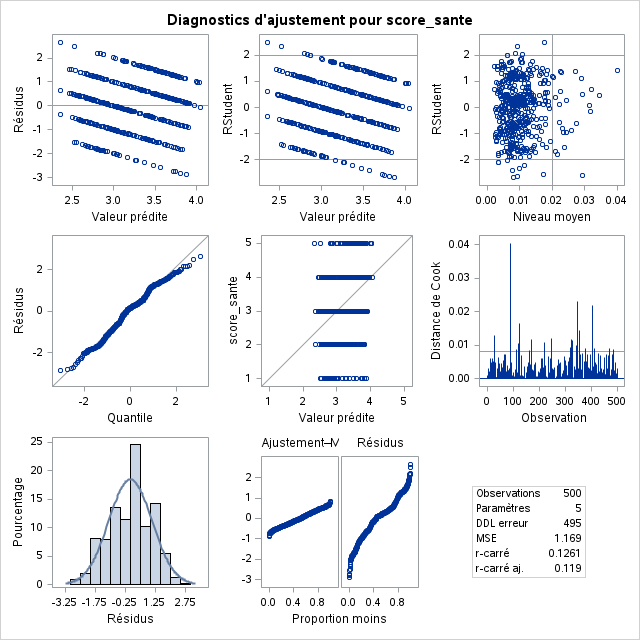

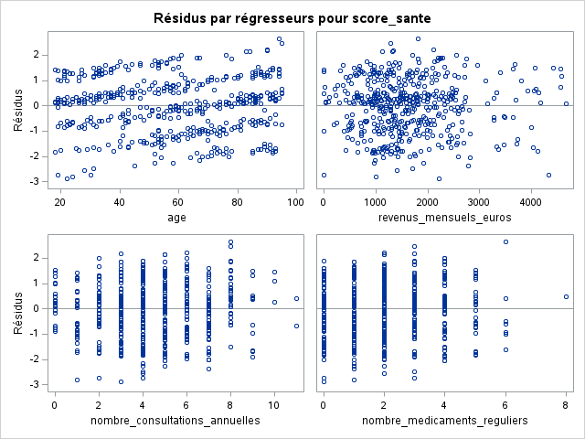

Sélection Forward (seuil d'entrée = 0.05)

La procédure REG

Modèle : MODEL1

Variable dépendante : score_sante

| Nb d'observations lues | 500 |
| --- | --- |
| Nb d'obs. utilisées | 500 |

Sélection ascendante : Etape 1

Variable age saisie : r-carré = 0.1111 et C(p) = 5.1142

| Analyse de variance Source | Analyse de variance DDL | Analyse de variance Somme des carrés | Analyse de variance Moyenne quadratique | Analyse de variance Valeur F | Analyse de variance Pr > F |
| --- | --- | --- | --- | --- | --- |
| Modèle | 1 | 73.55253 | 73.55253 | 62.24 | <.0001 |
| Erreur | 498 | 588.54947 | 1.18183 |  |  |
| Total sommes corrigées | 499 | 662.10200 |  |  |  |

| Variable | Valeur estimée des paramètres | Erreur type | SC Type II | Valeur F | Pr > F |
| --- | --- | --- | --- | --- | --- |
| Intercept | 4.18563 | 0.13241 | 1180.94076 | 999.25 | <.0001 |
| age | -0.01679 | 0.00213 | 73.55253 | 62.24 | <.0001 |

Limites sur nombre de conditions : 1, 1

Aucune autre variable ne correspondait au niveau de signification 0.0500 pour une saisie dans le modèle.

| Synthèse de Sélection ascendante Etape | Synthèse de Sélection ascendante Variable entrée | Synthèse de Sélection ascendante Nombre var. dans | Synthèse de Sélection ascendante R carré partiel | Synthèse de Sélection ascendante R carré du modèle | Synthèse de Sélection ascendante C(p) | Synthèse de Sélection ascendante Valeur F | Synthèse de Sélection ascendante Pr > F |
| --- | --- | --- | --- | --- | --- | --- | --- |
| 1 | age | 1 | 0.1111 | 0.1111 | 5.1142 | 62.24 | <.0001 |

Sélection Forward (seuil d'entrée = 0.05)

La procédure REG

Modèle : MODEL1

Variable dépendante : score_sante

Sélection Backward (seuil de maintien = 0.05)

La procédure REG

Modèle : MODEL1

Variable dépendante : score_sante

| Nb d'observations lues | 500 |
| --- | --- |
| Nb d'obs. utilisées | 500 |

Elimination descendante : Etape 0

Toutes les variables saisies : r-carré = 0.1273 et C(p) = 8.0000

| Analyse de variance Source | Analyse de variance DDL | Analyse de variance Somme des carrés | Analyse de variance Moyenne quadratique | Analyse de variance Valeur F | Analyse de variance Pr > F |
| --- | --- | --- | --- | --- | --- |
| Modèle | 7 | 84.25700 | 12.03671 | 10.25 | <.0001 |
| Erreur | 492 | 577.84500 | 1.17448 |  |  |
| Total sommes corrigées | 499 | 662.10200 |  |  |  |

| Variable | Valeur estimée des paramètres | Erreur type | SC Type II | Valeur F | Pr > F |
| --- | --- | --- | --- | --- | --- |
| Intercept | 4.37973 | 0.34396 | 190.42689 | 162.14 | <.0001 |
| age | -0.01035 | 0.00519 | 4.67356 | 3.98 | 0.0466 |
| revenus_mensuels_euros | 0.00005840 | 0.00005595 | 1.27937 | 1.09 | 0.2971 |
| depenses_sante_annuelles_euros | -0.00004893 | 0.00016807 | 0.09954 | 0.08 | 0.7711 |
| nombre_consultations_annuelles | -0.05045 | 0.02490 | 4.82034 | 4.10 | 0.0433 |
| nombre_medicaments_reguliers | -0.06739 | 0.03708 | 3.87836 | 3.30 | 0.0698 |
| imc | -0.00856 | 0.01153 | 0.64790 | 0.55 | 0.4580 |
| nombre_enfants | 0.00098626 | 0.03505 | 0.00092981 | 0.00 | 0.9776 |

Limites sur nombre de conditions : 5.9823, 119.05

Elimination descendante : Etape 1

Variable nombre_enfants supprimée : r-carré = 0.1273 et C(p) = 6.0008

| Analyse de variance Source | Analyse de variance DDL | Analyse de variance Somme des carrés | Analyse de variance Moyenne quadratique | Analyse de variance Valeur F | Analyse de variance Pr > F |
| --- | --- | --- | --- | --- | --- |
| Modèle | 6 | 84.25607 | 14.04268 | 11.98 | <.0001 |
| Erreur | 493 | 577.84593 | 1.17210 |  |  |
| Total sommes corrigées | 499 | 662.10200 |  |  |  |

| Variable | Valeur estimée des paramètres | Erreur type | SC Type II | Valeur F | Pr > F |
| --- | --- | --- | --- | --- | --- |
| Intercept | 4.38136 | 0.33869 | 196.14604 | 167.35 | <.0001 |
| age | -0.01036 | 0.00517 | 4.70314 | 4.01 | 0.0457 |
| revenus_mensuels_euros | 0.00005839 | 0.00005589 | 1.27909 | 1.09 | 0.2967 |
| depenses_sante_annuelles_euros | -0.00004864 | 0.00016758 | 0.09874 | 0.08 | 0.7718 |
| nombre_consultations_annuelles | -0.05042 | 0.02485 | 4.82365 | 4.12 | 0.0430 |
| nombre_medicaments_reguliers | -0.06743 | 0.03702 | 3.88803 | 3.32 | 0.0692 |
| imc | -0.00857 | 0.01152 | 0.64855 | 0.55 | 0.4573 |

Limites sur nombre de conditions : 5.9559, 95.685

Elimination descendante : Etape 2

Variable depenses_sante_annuelles_euros supprimée : r-carré = 0.1271 et C(p) = 4.0849

| Analyse de variance Source | Analyse de variance DDL | Analyse de variance Somme des carrés | Analyse de variance Moyenne quadratique | Analyse de variance Valeur F | Analyse de variance Pr > F |
| --- | --- | --- | --- | --- | --- |
| Modèle | 5 | 84.15733 | 16.83147 | 14.39 | <.0001 |
| Erreur | 494 | 577.94467 | 1.16993 |  |  |
| Total sommes corrigées | 499 | 662.10200 |  |  |  |

| Variable | Valeur estimée des paramètres | Erreur type | SC Type II | Valeur F | Pr > F |
| --- | --- | --- | --- | --- | --- |
| Intercept | 4.36989 | 0.33606 | 197.81295 | 169.08 | <.0001 |
| age | -0.01161 | 0.00287 | 19.14711 | 16.37 | <.0001 |
| revenus_mensuels_euros | 0.00005887 | 0.00005582 | 1.30159 | 1.11 | 0.2920 |
| nombre_consultations_annuelles | -0.05039 | 0.02483 | 4.81862 | 4.12 | 0.0429 |
| nombre_medicaments_reguliers | -0.06765 | 0.03698 | 3.91517 | 3.35 | 0.0680 |
| imc | -0.00882 | 0.01147 | 0.69056 | 0.59 | 0.4427 |

Limites sur nombre de conditions : 1.8368, 33.227

Elimination descendante : Etape 3

Variable imc supprimée : r-carré = 0.1261 et C(p) = 2.6728

| Analyse de variance Source | Analyse de variance DDL | Analyse de variance Somme des carrés | Analyse de variance Moyenne quadratique | Analyse de variance Valeur F | Analyse de variance Pr > F |
| --- | --- | --- | --- | --- | --- |
| Modèle | 4 | 83.46676 | 20.86669 | 17.85 | <.0001 |
| Erreur | 495 | 578.63524 | 1.16896 |  |  |
| Total sommes corrigées | 499 | 662.10200 |  |  |  |

| Variable | Valeur estimée des paramètres | Erreur type | SC Type II | Valeur F | Pr > F |
| --- | --- | --- | --- | --- | --- |
| Intercept | 4.14715 | 0.16989 | 696.60557 | 595.92 | <.0001 |
| age | -0.01147 | 0.00286 | 18.75025 | 16.04 | <.0001 |
| revenus_mensuels_euros | 0.00005870 | 0.00005579 | 1.29413 | 1.11 | 0.2932 |
| nombre_consultations_annuelles | -0.05069 | 0.02482 | 4.87752 | 4.17 | 0.0416 |
| nombre_medicaments_reguliers | -0.07003 | 0.03683 | 4.22473 | 3.61 | 0.0579 |

Limites sur nombre de conditions : 1.8287, 22.476

Elimination descendante : Etape 4

Variable revenus_mensuels_euros supprimée : r-carré = 0.1241 et C(p) = 1.7747

| Analyse de variance Source | Analyse de variance DDL | Analyse de variance Somme des carrés | Analyse de variance Moyenne quadratique | Analyse de variance Valeur F | Analyse de variance Pr > F |
| --- | --- | --- | --- | --- | --- |
| Modèle | 3 | 82.17263 | 27.39088 | 23.43 | <.0001 |
| Erreur | 496 | 579.92937 | 1.16921 |  |  |
| Total sommes corrigées | 499 | 662.10200 |  |  |  |

| Variable | Valeur estimée des paramètres | Erreur type | SC Type II | Valeur F | Pr > F |
| --- | --- | --- | --- | --- | --- |
| Intercept | 4.25240 | 0.13733 | 1121.13771 | 958.88 | <.0001 |
| age | -0.01159 | 0.00286 | 19.19137 | 16.41 | <.0001 |
| nombre_consultations_annuelles | -0.05060 | 0.02482 | 4.85969 | 4.16 | 0.0420 |
| nombre_medicaments_reguliers | -0.07188 | 0.03680 | 4.46120 | 3.82 | 0.0513 |

Limites sur nombre de conditions : 1.8256, 13.809

Elimination descendante : Etape 5

Variable nombre_medicaments_reguliers supprimée : r-carré = 0.1174 et C(p) = 3.5732

| Analyse de variance Source | Analyse de variance DDL | Analyse de variance Somme des carrés | Analyse de variance Moyenne quadratique | Analyse de variance Valeur F | Analyse de variance Pr > F |
| --- | --- | --- | --- | --- | --- |
| Modèle | 2 | 77.71143 | 38.85572 | 33.05 | <.0001 |
| Erreur | 497 | 584.39057 | 1.17584 |  |  |
| Total sommes corrigées | 499 | 662.10200 |  |  |  |

| Variable | Valeur estimée des paramètres | Erreur type | SC Type II | Valeur F | Pr > F |
| --- | --- | --- | --- | --- | --- |
| Intercept | 4.25873 | 0.13768 | 1125.10351 | 956.85 | <.0001 |
| age | -0.01451 | 0.00244 | 41.43393 | 35.24 | <.0001 |
| nombre_consultations_annuelles | -0.04665 | 0.02481 | 4.15890 | 3.54 | 0.0606 |

Limites sur nombre de conditions : 1.3259, 5.3037

Elimination descendante : Etape 6

Variable nombre_consultations_annuelles supprimée : r-carré = 0.1111 et C(p) = 5.1142

| Analyse de variance Source | Analyse de variance DDL | Analyse de variance Somme des carrés | Analyse de variance Moyenne quadratique | Analyse de variance Valeur F | Analyse de variance Pr > F |
| --- | --- | --- | --- | --- | --- |
| Modèle | 1 | 73.55253 | 73.55253 | 62.24 | <.0001 |
| Erreur | 498 | 588.54947 | 1.18183 |  |  |
| Total sommes corrigées | 499 | 662.10200 |  |  |  |

| Variable | Valeur estimée des paramètres | Erreur type | SC Type II | Valeur F | Pr > F |
| --- | --- | --- | --- | --- | --- |
| Intercept | 4.18563 | 0.13241 | 1180.94076 | 999.25 | <.0001 |
| age | -0.01679 | 0.00213 | 73.55253 | 62.24 | <.0001 |

Limites sur nombre de conditions : 1, 1

Toutes les variables restant dans le modèle sont significatives au niveau 0.0500.

| Synthèse de Elimination descendante Etape | Synthèse de Elimination descendante Variable supprimée | Synthèse de Elimination descendante Nombre var. dans | Synthèse de Elimination descendante R carré partiel | Synthèse de Elimination descendante R carré du modèle | Synthèse de Elimination descendante C(p) | Synthèse de Elimination descendante Valeur F | Synthèse de Elimination descendante Pr > F |
| --- | --- | --- | --- | --- | --- | --- | --- |
| 1 | nombre_enfants | 6 | 0.0000 | 0.1273 | 6.0008 | 0.00 | 0.9776 |
| 2 | depenses_sante_annuelles_euros | 5 | 0.0001 | 0.1271 | 4.0849 | 0.08 | 0.7718 |
| 3 | imc | 4 | 0.0010 | 0.1261 | 2.6728 | 0.59 | 0.4427 |
| 4 | revenus_mensuels_euros | 3 | 0.0020 | 0.1241 | 1.7747 | 1.11 | 0.2932 |
| 5 | nombre_medicaments_reguliers | 2 | 0.0067 | 0.1174 | 3.5732 | 3.82 | 0.0513 |
| 6 | nombre_consultations_annuelles | 1 | 0.0063 | 0.1111 | 5.1142 | 3.54 | 0.0606 |

Sélection Backward (seuil de maintien = 0.05)

La procédure REG

Modèle : MODEL1

Variable dépendante : score_sante

Sélection Stepwise (entrée/maintien = 0.05)

La procédure REG

Modèle : MODEL1

Variable dépendante : score_sante

| Nb d'observations lues | 500 |
| --- | --- |
| Nb d'obs. utilisées | 500 |

Sélection Stepwise : Etape 1

Variable age saisie : r-carré = 0.1111 et C(p) = 5.1142

| Analyse de variance Source | Analyse de variance DDL | Analyse de variance Somme des carrés | Analyse de variance Moyenne quadratique | Analyse de variance Valeur F | Analyse de variance Pr > F |
| --- | --- | --- | --- | --- | --- |
| Modèle | 1 | 73.55253 | 73.55253 | 62.24 | <.0001 |
| Erreur | 498 | 588.54947 | 1.18183 |  |  |
| Total sommes corrigées | 499 | 662.10200 |  |  |  |

| Variable | Valeur estimée des paramètres | Erreur type | SC Type II | Valeur F | Pr > F |
| --- | --- | --- | --- | --- | --- |
| Intercept | 4.18563 | 0.13241 | 1180.94076 | 999.25 | <.0001 |
| age | -0.01679 | 0.00213 | 73.55253 | 62.24 | <.0001 |

Limites sur nombre de conditions : 1, 1

Toutes les variables restant dans le modèle sont significatives au niveau 0.0500.

Aucune autre variable ne correspondait au niveau de signification 0.0500 pour une saisie dans le modèle.

| Synthèse de Sélection Stepwise Etape | Synthèse de Sélection Stepwise Variable entrée | Synthèse de Sélection Stepwise Variable supprimée | Synthèse de Sélection Stepwise Nombre var. dans | Synthèse de Sélection Stepwise R carré partiel | Synthèse de Sélection Stepwise R carré du modèle | Synthèse de Sélection Stepwise C(p) | Synthèse de Sélection Stepwise Valeur F | Synthèse de Sélection Stepwise Pr > F |
| --- | --- | --- | --- | --- | --- | --- | --- | --- |
| 1 | age |  | 1 | 0.1111 | 0.1111 | 5.1142 | 62.24 | <.0001 |

Sélection Stepwise (entrée/maintien = 0.05)

La procédure REG

Modèle : MODEL1

Variable dépendante : score_sante

Modèle retenu — Diagnostics complets (score_sante)

La procédure REG

Modèle : MODEL1

Variable dépendante : score_sante

| Nb d'observations lues | 500 |
| --- | --- |
| Nb d'obs. utilisées | 500 |

| Analyse de variance Source | Analyse de variance DDL | Analyse de variance Somme des carrés | Analyse de variance Moyenne quadratique | Analyse de variance Valeur F | Analyse de variance Pr > F |
| --- | --- | --- | --- | --- | --- |
| Modèle | 3 | 82.17263 | 27.39088 | 23.43 | <.0001 |
| Erreur | 496 | 579.92937 | 1.16921 |  |  |
| Total sommes corrigées | 499 | 662.10200 |  |  |  |

| Root MSE | 1.08130 | R carré | 0.1241 |
| --- | --- | --- | --- |
| Moyenne dépendante | 3.21400 | R car. ajust. | 0.1188 |
| Coeff Var | 33.64347 |  |  |

| Paramètres estimés Variable | Paramètres estimés DDL | Paramètres estimés Valeur estimée des paramètres | Paramètres estimés Erreur type | Paramètres estimés Valeur du test t | Paramètres estimés Pr > \|t\| |
| --- | --- | --- | --- | --- | --- |
| Intercept | 1 | 4.25240 | 0.13733 | 30.97 | <.0001 |
| age | 1 | -0.01159 | 0.00286 | -4.05 | <.0001 |
| nombre_consultations_annuelles | 1 | -0.05060 | 0.02482 | -2.04 | 0.0420 |
| nombre_medicaments_reguliers | 1 | -0.07188 | 0.03680 | -1.95 | 0.0513 |

Modèle retenu — Diagnostics complets (score_sante)

La procédure REG

Modèle : MODEL1

Variable dépendante : score_sante

| Test de spécification du premier et du deuxième moment DDL | Test de spécification du premier et du deuxième moment khi-2 | Test de spécification du premier et du deuxième moment Pr > khi-2 |
| --- | --- | --- |
| 9 | 8.77 | 0.4589 |

| Durbin-Watson D | 2.058 |
| --- | --- |
| Pr < DW | 0.7408 |
| Pr > DW | 0.2592 |
| Nombre d'observations | 500 |
| Autocorrélation de 1er ordre | -0.030 |

Note:Pr<DW est la p-value pour tester l'autocorrélation positive, et Pr>DW est la p-value pour tester l'autocorrélation négative.

Modèle retenu — Diagnostics complets (score_sante)

La procédure REG

Modèle : MODEL1

Variable dépendante : score_sante

[output not shown]

[output cut: 470 more lines]

| Somme des résidus | 0 |
| --- | --- |
| Somme des résidus du carré | 579.92937 |
| Somme des carrés des résidus prédits (PRESS) | 589.20873 |

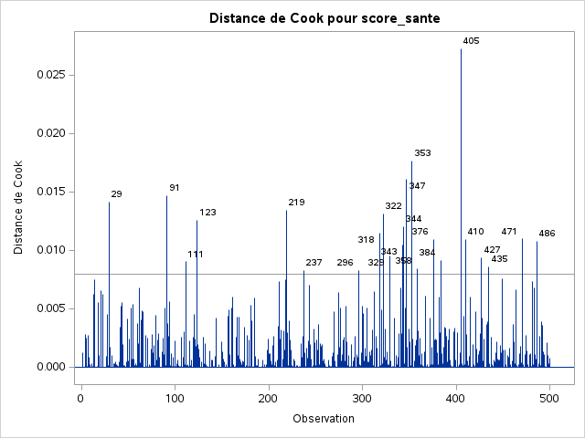

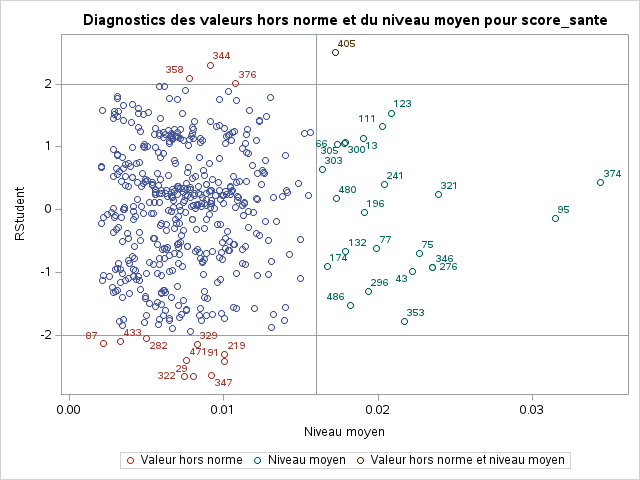

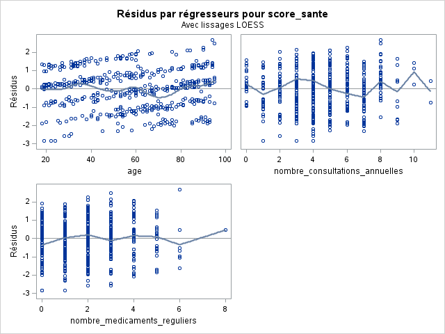

Normalité des résidus — QQ-plot

La procédure UNIVARIATE

Variable : resid (Résidus)

| Moments |  |  |  |
| --- | --- | --- | --- |
| N | 500 | Somme des poids | 500 |
| Moyenne | 0 | Somme des observations | 0 |
| Ecart-type | 1.07804597 | Variance | 1.16218311 |
| Skewness | -0.2200247 | Kurtosis | -0.5219681 |
| Somme des carrés non corrigée | 579.929371 | Somme des carrés corrigée | 579.929371 |
| Coeff Variation | . | Std Error Mean | 0.04821168 |

| Mesures statistiques de base Location | Mesures statistiques de base Location | Mesures statistiques de base Variabilité | Mesures statistiques de base Variabilité |
| --- | --- | --- | --- |
| Moyenne | 0.000000 | Ecart-type | 1.07805 |
| Médiane | 0.116776 | Variance | 1.16218 |
| Mode | 0.265890 | Intervalle | 5.52487 |
|  |  | Ecart interquartile | 1.52340 |

| Tests de tendance centrale : Mu0=0 Test | Tests de tendance centrale : Mu0=0 Statistique | Tests de tendance centrale : Mu0=0 Statistique | Tests de tendance centrale : Mu0=0 p-value | Tests de tendance centrale : Mu0=0 p-value |
| --- | --- | --- | --- | --- |
| t de Student | t | 0 | Pr > \|t\| | 1.0000 |
| Signe | M | 30 | Pr >= \|M\| | 0.0083 |
| Rang signé | S | 1840 | Pr >= \|S\| | 0.5697 |

| Tests de normalité Test | Tests de normalité Statistique | Tests de normalité Statistique | Tests de normalité p-value | Tests de normalité p-value |
| --- | --- | --- | --- | --- |
| Shapiro-Wilk | W | 0.986451 | Pr < W | 0.0001 |
| Kolmogorov-Smirnov | D | 0.064913 | Pr > D | <0.0100 |
| Cramer-von Mises | W-Sq | 0.373063 | Pr > W-Sq | <0.0050 |
| Anderson-Darling | A-Sq | 2.183635 | Pr > A-Sq | <0.0050 |

| Quantiles (Définition 5) Niveau | Quantiles (Définition 5) Quantile |
| --- | --- |
| 100Max 100% | 2.673101 |
| 99% | 2.112100 |
| 95% | 1.642848 |
| 90% | 1.346993 |
| 75% Q3 | 0.741612 |
| 50% Médiane | 0.116776 |
| 25% Q1 | -0.781784 |
| 10% | -1.525808 |
| 5% | -1.858804 |
| 1% | -2.528409 |
| 0% Min | -2.851769 |

| Observations extrêmes La plus petite Valeur | Observations extrêmes La plus petite Obs | Observations extrêmes La plus grande Valeur | Observations extrêmes La plus grande Obs |
| --- | --- | --- | --- |
| -2.85177 | 29 | 2.11790 | 185 |
| -2.84562 | 322 | 2.15811 | 376 |
| -2.82979 | 347 | 2.23803 | 358 |
| -2.58788 | 91 | 2.46906 | 344 |
| -2.58173 | 471 | 2.67310 | 405 |

Normalité des résidus — QQ-plot

La procédure UNIVARIATE

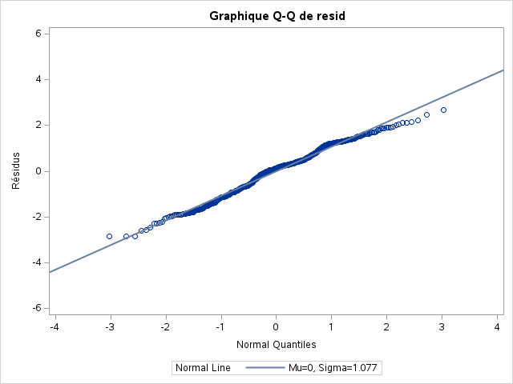

Normalité des résidus — Histogramme

La procédure UNIVARIATE

Variable : resid (Résidus)

| Moments |  |  |  |
| --- | --- | --- | --- |
| N | 500 | Somme des poids | 500 |
| Moyenne | 0 | Somme des observations | 0 |
| Ecart-type | 1.07804597 | Variance | 1.16218311 |
| Skewness | -0.2200247 | Kurtosis | -0.5219681 |
| Somme des carrés non corrigée | 579.929371 | Somme des carrés corrigée | 579.929371 |
| Coeff Variation | . | Std Error Mean | 0.04821168 |

| Mesures statistiques de base Location | Mesures statistiques de base Location | Mesures statistiques de base Variabilité | Mesures statistiques de base Variabilité |
| --- | --- | --- | --- |
| Moyenne | 0.000000 | Ecart-type | 1.07805 |
| Médiane | 0.116776 | Variance | 1.16218 |
| Mode | 0.265890 | Intervalle | 5.52487 |
|  |  | Ecart interquartile | 1.52340 |

| Tests de tendance centrale : Mu0=0 Test | Tests de tendance centrale : Mu0=0 Statistique | Tests de tendance centrale : Mu0=0 Statistique | Tests de tendance centrale : Mu0=0 p-value | Tests de tendance centrale : Mu0=0 p-value |
| --- | --- | --- | --- | --- |
| t de Student | t | 0 | Pr > \|t\| | 1.0000 |
| Signe | M | 30 | Pr >= \|M\| | 0.0083 |
| Rang signé | S | 1840 | Pr >= \|S\| | 0.5697 |

| Quantiles (Définition 5) Niveau | Quantiles (Définition 5) Quantile |
| --- | --- |
| 100Max 100% | 2.673101 |
| 99% | 2.112100 |
| 95% | 1.642848 |
| 90% | 1.346993 |
| 75% Q3 | 0.741612 |
| 50% Médiane | 0.116776 |
| 25% Q1 | -0.781784 |
| 10% | -1.525808 |
| 5% | -1.858804 |
| 1% | -2.528409 |
| 0% Min | -2.851769 |

| Observations extrêmes La plus petite Valeur | Observations extrêmes La plus petite Obs | Observations extrêmes La plus grande Valeur | Observations extrêmes La plus grande Obs |
| --- | --- | --- | --- |
| -2.85177 | 29 | 2.11790 | 185 |
| -2.84562 | 322 | 2.15811 | 376 |
| -2.82979 | 347 | 2.23803 | 358 |
| -2.58788 | 91 | 2.46906 | 344 |
| -2.58173 | 471 | 2.67310 | 405 |

Normalité des résidus — Histogramme

La procédure UNIVARIATE

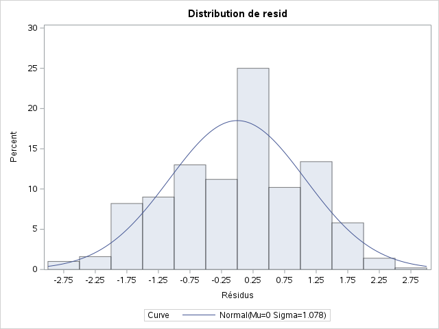

Normalité des résidus — Histogramme

La procédure UNIVARIATE

Fitted Normal Distribution for resid (Résidus)

| Parameters for Normal Distribution Paramètre | Parameters for Normal Distribution Symbole | Parameters for Normal Distribution Estimation |
| --- | --- | --- |
| Mean | Mu | 0 |
| Std Dev | Sigma | 1.078046 |

| Goodness-of-Fit Tests for Normal Distribution Test | Goodness-of-Fit Tests for Normal Distribution Statistique | Goodness-of-Fit Tests for Normal Distribution Statistique | Goodness-of-Fit Tests for Normal Distribution p-value | Goodness-of-Fit Tests for Normal Distribution p-value |
| --- | --- | --- | --- | --- |
| Kolmogorov-Smirnov | D | 0.06491285 | Pr > D | <0.010 |
| Cramer-von Mises | W-Sq | 0.37306287 | Pr > W-Sq | <0.005 |
| Anderson-Darling | A-Sq | 2.18363549 | Pr > A-Sq | <0.005 |

| Quantiles for Normal Distribution Pourcentage | Quantiles for Normal Distribution Quantile Observé | Quantiles for Normal Distribution Quantile Estimé |
| --- | --- | --- |
| 1.0 | -2.52841 | -2.50791 |
| 5.0 | -1.85880 | -1.77323 |
| 10.0 | -1.52581 | -1.38157 |
| 25.0 | -0.78178 | -0.72713 |
| 50.0 | 0.11678 | 0.00000 |
| 75.0 | 0.74161 | 0.72713 |
| 90.0 | 1.34699 | 1.38157 |
| 95.0 | 1.64285 | 1.77323 |
| 99.0 | 2.11210 | 2.50791 |

Éléments aberrants — RStudent × Leverage

La procédure REG

Modèle : MODEL1

Variable dépendante : score_sante

| Nb d'observations lues | 500 |
| --- | --- |
| Nb d'obs. utilisées | 500 |

| Analyse de variance Source | Analyse de variance DDL | Analyse de variance Somme des carrés | Analyse de variance Moyenne quadratique | Analyse de variance Valeur F | Analyse de variance Pr > F |
| --- | --- | --- | --- | --- | --- |
| Modèle | 3 | 82.17263 | 27.39088 | 23.43 | <.0001 |
| Erreur | 496 | 579.92937 | 1.16921 |  |  |
| Total sommes corrigées | 499 | 662.10200 |  |  |  |

| Root MSE | 1.08130 | R carré | 0.1241 |
| --- | --- | --- | --- |
| Moyenne dépendante | 3.21400 | R car. ajust. | 0.1188 |
| Coeff Var | 33.64347 |  |  |

| Paramètres estimés Variable | Paramètres estimés DDL | Paramètres estimés Valeur estimée des paramètres | Paramètres estimés Erreur type | Paramètres estimés Valeur du test t | Paramètres estimés Pr > \|t\| |
| --- | --- | --- | --- | --- | --- |
| Intercept | 1 | 4.25240 | 0.13733 | 30.97 | <.0001 |
| age | 1 | -0.01159 | 0.00286 | -4.05 | <.0001 |
| nombre_consultations_annuelles | 1 | -0.05060 | 0.02482 | -2.04 | 0.0420 |
| nombre_medicaments_reguliers | 1 | -0.07188 | 0.03680 | -1.95 | 0.0513 |

Éléments aberrants — RStudent × Leverage

La procédure REG

Modèle : MODEL1

Variable dépendante : score_sante

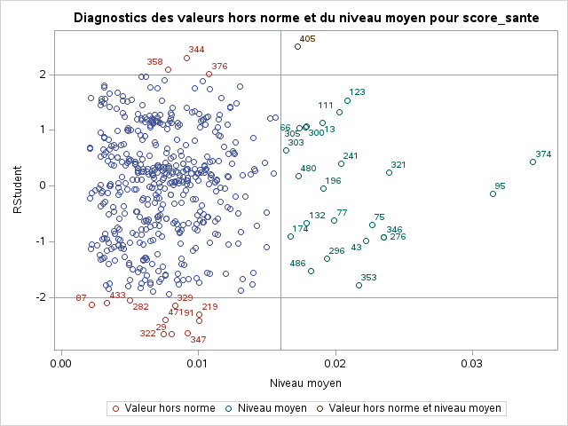

Distance de Cook — Observations influentes

La procédure REG

Modèle : MODEL1

Variable dépendante : score_sante

| Nb d'observations lues | 500 |
| --- | --- |
| Nb d'obs. utilisées | 500 |

| Analyse de variance Source | Analyse de variance DDL | Analyse de variance Somme des carrés | Analyse de variance Moyenne quadratique | Analyse de variance Valeur F | Analyse de variance Pr > F |
| --- | --- | --- | --- | --- | --- |
| Modèle | 3 | 82.17263 | 27.39088 | 23.43 | <.0001 |
| Erreur | 496 | 579.92937 | 1.16921 |  |  |
| Total sommes corrigées | 499 | 662.10200 |  |  |  |

| Root MSE | 1.08130 | R carré | 0.1241 |
| --- | --- | --- | --- |
| Moyenne dépendante | 3.21400 | R car. ajust. | 0.1188 |
| Coeff Var | 33.64347 |  |  |

| Paramètres estimés Variable | Paramètres estimés DDL | Paramètres estimés Valeur estimée des paramètres | Paramètres estimés Erreur type | Paramètres estimés Valeur du test t | Paramètres estimés Pr > \|t\| |
| --- | --- | --- | --- | --- | --- |
| Intercept | 1 | 4.25240 | 0.13733 | 30.97 | <.0001 |
| age | 1 | -0.01159 | 0.00286 | -4.05 | <.0001 |
| nombre_consultations_annuelles | 1 | -0.05060 | 0.02482 | -2.04 | 0.0420 |
| nombre_medicaments_reguliers | 1 | -0.07188 | 0.03680 | -1.95 | 0.0513 |

Distance de Cook — Observations influentes

La procédure REG

Modèle : MODEL1

Variable dépendante : score_sante

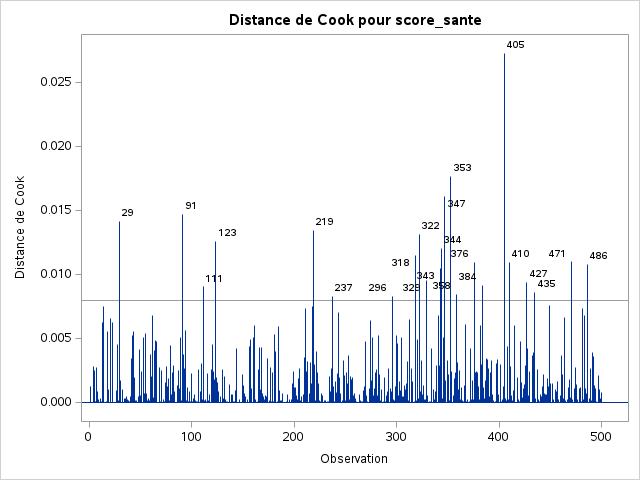

Indépendance des résidus — Durbin-Watson

La procédure REG

Modèle : MODEL1

Variable dépendante : score_sante

| Nb d'observations lues | 500 |
| --- | --- |
| Nb d'obs. utilisées | 500 |

| Analyse de variance Source | Analyse de variance DDL | Analyse de variance Somme des carrés | Analyse de variance Moyenne quadratique | Analyse de variance Valeur F | Analyse de variance Pr > F |
| --- | --- | --- | --- | --- | --- |
| Modèle | 3 | 82.17263 | 27.39088 | 23.43 | <.0001 |
| Erreur | 496 | 579.92937 | 1.16921 |  |  |
| Total sommes corrigées | 499 | 662.10200 |  |  |  |

| Root MSE | 1.08130 | R carré | 0.1241 |
| --- | --- | --- | --- |
| Moyenne dépendante | 3.21400 | R car. ajust. | 0.1188 |
| Coeff Var | 33.64347 |  |  |

| Paramètres estimés Variable | Paramètres estimés DDL | Paramètres estimés Valeur estimée des paramètres | Paramètres estimés Erreur type | Paramètres estimés Valeur du test t | Paramètres estimés Pr > \|t\| |
| --- | --- | --- | --- | --- | --- |
| Intercept | 1 | 4.25240 | 0.13733 | 30.97 | <.0001 |
| age | 1 | -0.01159 | 0.00286 | -4.05 | <.0001 |
| nombre_consultations_annuelles | 1 | -0.05060 | 0.02482 | -2.04 | 0.0420 |
| nombre_medicaments_reguliers | 1 | -0.07188 | 0.03680 | -1.95 | 0.0513 |

Indépendance des résidus — Durbin-Watson

La procédure REG

Modèle : MODEL1

Variable dépendante : score_sante

| Durbin-Watson D | 2.058 |
| --- | --- |
| Pr < DW | 0.7408 |
| Pr > DW | 0.2592 |
| Nombre d'observations | 500 |
| Autocorrélation de 1er ordre | -0.030 |

Note:Pr<DW est la p-value pour tester l'autocorrélation positive, et Pr>DW est la p-value pour tester l'autocorrélation négative.

Indépendance des résidus — Durbin-Watson

La procédure REG

Modèle : MODEL1

Variable dépendante : score_sante

Homoscédasticité — Test de White (SPEC)

La procédure REG

Modèle : MODEL1

Variable dépendante : score_sante

| Nb d'observations lues | 500 |
| --- | --- |
| Nb d'obs. utilisées | 500 |

| Analyse de variance Source | Analyse de variance DDL | Analyse de variance Somme des carrés | Analyse de variance Moyenne quadratique | Analyse de variance Valeur F | Analyse de variance Pr > F |
| --- | --- | --- | --- | --- | --- |
| Modèle | 3 | 82.17263 | 27.39088 | 23.43 | <.0001 |
| Erreur | 496 | 579.92937 | 1.16921 |  |  |
| Total sommes corrigées | 499 | 662.10200 |  |  |  |

| Root MSE | 1.08130 | R carré | 0.1241 |
| --- | --- | --- | --- |
| Moyenne dépendante | 3.21400 | R car. ajust. | 0.1188 |
| Coeff Var | 33.64347 |  |  |

| Paramètres estimés Variable | Paramètres estimés DDL | Paramètres estimés Valeur estimée des paramètres | Paramètres estimés Erreur type | Paramètres estimés Valeur du test t | Paramètres estimés Pr > \|t\| |
| --- | --- | --- | --- | --- | --- |
| Intercept | 1 | 4.25240 | 0.13733 | 30.97 | <.0001 |
| age | 1 | -0.01159 | 0.00286 | -4.05 | <.0001 |
| nombre_consultations_annuelles | 1 | -0.05060 | 0.02482 | -2.04 | 0.0420 |
| nombre_medicaments_reguliers | 1 | -0.07188 | 0.03680 | -1.95 | 0.0513 |

Homoscédasticité — Test de White (SPEC)

La procédure REG

Modèle : MODEL1

Variable dépendante : score_sante

| Test de spécification du premier et du deuxième moment DDL | Test de spécification du premier et du deuxième moment khi-2 | Test de spécification du premier et du deuxième moment Pr > khi-2 |
| --- | --- | --- |
| 9 | 8.77 | 0.4589 |

Homoscédasticité — Test de White (SPEC)

La procédure REG

Modèle : MODEL1

Variable dépendante : score_sante

Linéarité — Résidus partiels

La procédure REG

Modèle : MODEL1

Variable dépendante : score_sante

| Nb d'observations lues | 500 |
| --- | --- |
| Nb d'obs. utilisées | 500 |

| Analyse de variance Source | Analyse de variance DDL | Analyse de variance Somme des carrés | Analyse de variance Moyenne quadratique | Analyse de variance Valeur F | Analyse de variance Pr > F |
| --- | --- | --- | --- | --- | --- |
| Modèle | 3 | 82.17263 | 27.39088 | 23.43 | <.0001 |
| Erreur | 496 | 579.92937 | 1.16921 |  |  |
| Total sommes corrigées | 499 | 662.10200 |  |  |  |

| Root MSE | 1.08130 | R carré | 0.1241 |
| --- | --- | --- | --- |
| Moyenne dépendante | 3.21400 | R car. ajust. | 0.1188 |
| Coeff Var | 33.64347 |  |  |

| Paramètres estimés Variable | Paramètres estimés DDL | Paramètres estimés Valeur estimée des paramètres | Paramètres estimés Erreur type | Paramètres estimés Valeur du test t | Paramètres estimés Pr > \|t\| |
| --- | --- | --- | --- | --- | --- |
| Intercept | 1 | 4.25240 | 0.13733 | 30.97 | <.0001 |
| age | 1 | -0.01159 | 0.00286 | -4.05 | <.0001 |
| nombre_consultations_annuelles | 1 | -0.05060 | 0.02482 | -2.04 | 0.0420 |
| nombre_medicaments_reguliers | 1 | -0.07188 | 0.03680 | -1.95 | 0.0513 |

Linéarité — Résidus partiels

La procédure REG

Modèle : MODEL1

Variable dépendante : score_sante

| Test de spécification du premier et du deuxième moment DDL | Test de spécification du premier et du deuxième moment khi-2 | Test de spécification du premier et du deuxième moment Pr > khi-2 |
| --- | --- | --- |
| 9 | 8.77 | 0.4589 |

Linéarité — Résidus partiels

La procédure REG

Modèle : MODEL1

Variable dépendante : score_sante

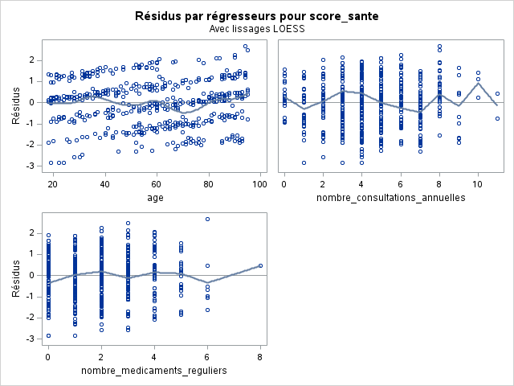

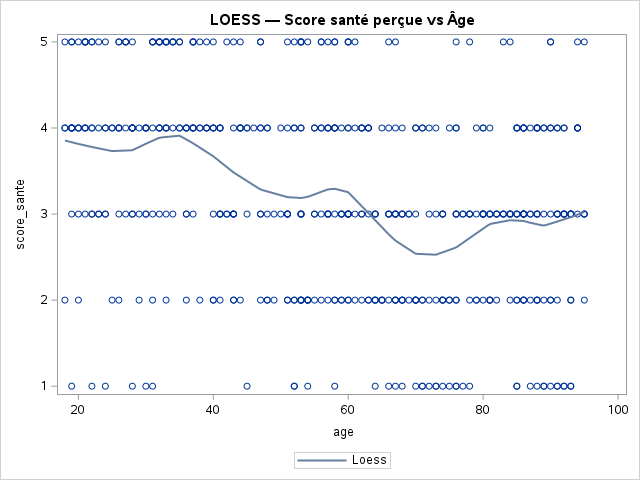

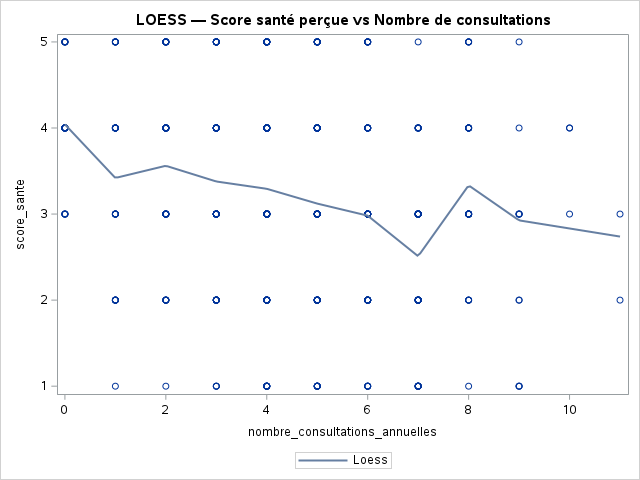

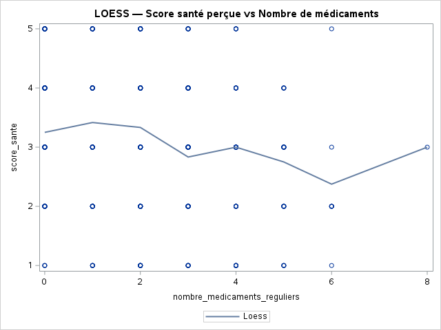

Observations potentiellement aberrantes / influentes

| Obs. | id | age | score_sante | yhat | resid | rstud | cooksd | leverage |
| --- | --- | --- | --- | --- | --- | --- | --- | --- |
| 29 | 29 | 24 | 1 | 3.85177 | -2.85177 | -2.66421 | 0.014157 | 0.008012 |
| 87 | 87 | 52 | 1 | 3.30358 | -2.30358 | -2.14039 | 0.002485 | 0.002181 |
| 91 | 91 | 30 | 1 | 3.58788 | -2.58788 | -2.41715 | 0.014705 | 0.010063 |
| 111 | 111 | 94 | 4 | 2.58508 | 1.41492 | 1.32299 | 0.009035 | 0.020260 |
| 123 | 123 | 38 | 5 | 3.35658 | 1.64342 | 1.53807 | 0.012566 | 0.020862 |
| 219 | 219 | 31 | 1 | 3.47509 | -2.47509 | -2.31063 | 0.013445 | 0.010059 |
| 237 | 237 | 78 | 5 | 3.12472 | 1.87528 | 1.74731 | 0.008285 | 0.010782 |
| 282 | 282 | 67 | 1 | 3.20161 | -2.20161 | -2.04776 | 0.005252 | 0.005017 |
| 296 | 296 | 70 | 2 | 3.39052 | -1.39052 | -1.29949 | 0.008320 | 0.019353 |
| 318 | 318 | 77 | 1 | 3.00578 | -2.00578 | -1.87191 | 0.011530 | 0.013056 |
| 322 | 322 | 22 | 1 | 3.84562 | -2.84562 | -2.65765 | 0.013138 | 0.007475 |
| 329 | 329 | 45 | 1 | 3.30478 | -2.30478 | -2.14813 | 0.009536 | 0.008258 |
| 343 | 343 | 66 | 5 | 3.08267 | 1.91733 | 1.78879 | 0.010514 | 0.013030 |
| 344 | 344 | 95 | 5 | 2.53094 | 2.46906 | 2.30382 | 0.012079 | 0.009099 |
| 347 | 347 | 19 | 1 | 3.82979 | -2.82979 | -2.64503 | 0.016091 | 0.009225 |
| 353 | 353 | 52 | 1 | 2.90682 | -1.90682 | -1.78685 | 0.017634 | 0.021708 |
| 358 | 358 | 90 | 5 | 2.76197 | 2.23803 | 2.08483 | 0.008431 | 0.007750 |
| 376 | 376 | 90 | 5 | 2.84189 | 2.15811 | 2.01282 | 0.010942 | 0.010752 |
| 384 | 384 | 76 | 5 | 2.98287 | 2.01713 | 1.87994 | 0.009159 | 0.010312 |
| 405 | 405 | 94 | 5 | 2.32690 | 2.67310 | 2.50696 | 0.027284 | 0.017247 |
| 410 | 410 | 92 | 1 | 2.89059 | -1.89059 | -1.76450 | 0.010960 | 0.013944 |
| 427 | 427 | 93 | 1 | 2.79907 | -1.79907 | -1.67797 | 0.009394 | 0.013218 |
| 433 | 433 | 58 | 1 | 3.25532 | -2.25532 | -2.09637 | 0.003654 | 0.003338 |
| 435 | 435 | 72 | 1 | 2.67503 | -1.67503 | -1.56227 | 0.008611 | 0.013956 |
| 471 | 471 | 28 | 1 | 3.58173 | -2.58173 | -2.40830 | 0.010989 | 0.007594 |
| 486 | 486 | 89 | 1 | 2.63785 | -1.63785 | -1.53074 | 0.010827 | 0.018195 |

ANCOVA — score_sante (modèle complet avec covariables et facteurs)

La procédure GLM

| Informations sur les niveaux de classe Classe | Informations sur les niveaux de classe Niveaux | Informations sur les niveaux de classe Valeurs |
| --- | --- | --- |
| sexe | 2 | Femme Homme |
| profession | 9 | Agriculteur Artisan/Commerçant Cadre supérieur Employé Ouvrier Profession intermédiaire Retraité Sans activité professionnelle Étudiant |
| couverture_complementaire | 4 | Assurance privée Aucune complémentaire Complémentaire santé solidaire (CSS) Mutuelle privée |
| hospitalisation_12_mois | 2 | Non Oui |
| tabagisme | 4 | Ancien fumeur Fumeur occasionnel Fumeur quotidien Non-fumeur |
| activite_physique | 4 | Activité intense Activité légère Activité modérée Sédentaire |
| handicap_declare | 2 | Non Oui |
| maladies_declarees | 13 | Arthrose Asthme Aucune Cancer (rémission) Cardiopathie Diabète Dépression Hypertension Lombalgie chronique Maladie respiratoire chronique Migraine chronique Obésité morbide Trouble anxieux |

| Nombre d'observations lues | 500 |
| --- | --- |
| Nombre d'observations utilisées | 500 |

ANCOVA — score_sante (modèle complet avec covariables et facteurs)

La procédure GLM

Variable dépendante : score_sante

| Source | DDL | Somme des carrés | Carré moyen | Valeur F | Pr > F |
| --- | --- | --- | --- | --- | --- |
| Modèle | 38 | 129.0368890 | 3.3957076 | 2.94 | <.0001 |
| Erreur | 461 | 533.0651110 | 1.1563235 |  |  |
| Total sommes corrigées | 499 | 662.1020000 |  |  |  |

| R-carré | Coef de var | Racine MSE | score_sante Moyenne |
| --- | --- | --- | --- |
| 0.194890 | 33.45752 | 1.075325 | 3.214000 |

| Source | DDL | Type III SS | Carré moyen | Valeur F | Pr > F |
| --- | --- | --- | --- | --- | --- |
| age | 1 | 4.90358205 | 4.90358205 | 4.24 | 0.0400 |
| revenus_mensuels_eur | 1 | 4.32425878 | 4.32425878 | 3.74 | 0.0537 |
| imc | 1 | 0.71704353 | 0.71704353 | 0.62 | 0.4314 |
| depenses_sante_annue | 1 | 0.00166228 | 0.00166228 | 0.00 | 0.9698 |
| nombre_consultations | 1 | 3.21674744 | 3.21674744 | 2.78 | 0.0960 |
| nombre_medicaments_r | 1 | 4.96046489 | 4.96046489 | 4.29 | 0.0389 |
| sexe | 1 | 0.33158997 | 0.33158997 | 0.29 | 0.5926 |
| profession | 8 | 7.31322926 | 0.91415366 | 0.79 | 0.6112 |
| couverture_complemen | 3 | 0.66487807 | 0.22162602 | 0.19 | 0.9021 |
| hospitalisation_12_m | 1 | 0.03624567 | 0.03624567 | 0.03 | 0.8595 |
| tabagisme | 3 | 5.91767706 | 1.97255902 | 1.71 | 0.1650 |
| activite_physique | 3 | 6.34434519 | 2.11478173 | 1.83 | 0.1410 |
| handicap_declare | 1 | 1.61159749 | 1.61159749 | 1.39 | 0.2384 |
| maladies_declarees | 12 | 23.14310965 | 1.92859247 | 1.67 | 0.0709 |

| Paramètre | Estimation |  | Erreur type | Valeur du test t | Pr > \|t\| |
| --- | --- | --- | --- | --- | --- |
| Constante | 4.115606418 | B | 0.49861235 | 8.25 | <.0001 |
| age | -0.012337394 |  | 0.00599110 | -2.06 | 0.0400 |
| revenus_mensuels_eur | 0.000198497 |  | 0.00010265 | 1.93 | 0.0537 |
| imc | -0.009280130 |  | 0.01178477 | -0.79 | 0.4314 |
| depenses_sante_annue | -0.000006547 |  | 0.00017268 | -0.04 | 0.9698 |
| nombre_consultations | -0.042475048 |  | 0.02546625 | -1.67 | 0.0960 |
| nombre_medicaments_r | -0.077612763 |  | 0.03747241 | -2.07 | 0.0389 |
| sexe Femme | 0.053881716 | B | 0.10061909 | 0.54 | 0.5926 |
| sexe Homme | 0.000000000 | B | . | . | . |
| profession Agriculteur | -0.290807545 | B | 0.50287430 | -0.58 | 0.5634 |
| profession Artisan/Commerçant | -0.130430849 | B | 0.32478026 | -0.40 | 0.6882 |
| profession Cadre supérieur | -0.577936948 | B | 0.43145787 | -1.34 | 0.1811 |
| profession Employé | -0.124448529 | B | 0.26474584 | -0.47 | 0.6385 |
| profession Ouvrier | 0.055909533 | B | 0.26330160 | 0.21 | 0.8319 |
| profession Profession intermédiaire | -0.424604865 | B | 0.33206517 | -1.28 | 0.2017 |
| profession Retraité | -0.069784339 | B | 0.28910087 | -0.24 | 0.8094 |
| profession Sans activité professionnelle | 0.212268496 | B | 0.26427778 | 0.80 | 0.4223 |
| profession Étudiant | 0.000000000 | B | . | . | . |
| couverture_complemen Assurance privée | 0.021940953 | B | 0.13218153 | 0.17 | 0.8682 |
| couverture_complemen Aucune complémentaire | 0.059382972 | B | 0.17504101 | 0.34 | 0.7346 |
| couverture_complemen Complémentaire santé solidaire (CSS) | -0.078105026 | B | 0.14090424 | -0.55 | 0.5796 |
| couverture_complemen Mutuelle privée | 0.000000000 | B | . | . | . |
| hospitalisation_12_m Non | 0.019791788 | B | 0.11178837 | 0.18 | 0.8595 |
| hospitalisation_12_m Oui | 0.000000000 | B | . | . | . |
| tabagisme Ancien fumeur | 0.139225194 | B | 0.12421294 | 1.12 | 0.2629 |
| tabagisme Fumeur occasionnel | -0.051089844 | B | 0.16903183 | -0.30 | 0.7626 |
| tabagisme Fumeur quotidien | 0.255209826 | B | 0.13000553 | 1.96 | 0.0502 |
| tabagisme Non-fumeur | 0.000000000 | B | . | . | . |
| activite_physique Activité intense | -0.313580812 | B | 0.17051180 | -1.84 | 0.0665 |
| activite_physique Activité légère | 0.045518886 | B | 0.13183582 | 0.35 | 0.7300 |
| activite_physique Activité modérée | 0.044483312 | B | 0.13161656 | 0.34 | 0.7355 |
| activite_physique Sédentaire | 0.000000000 | B | . | . | . |
| handicap_declare Non | -0.143299037 | B | 0.12138210 | -1.18 | 0.2384 |
| handicap_declare Oui | 0.000000000 | B | . | . | . |
| maladies_declarees Arthrose | 0.243190852 | B | 0.32054377 | 0.76 | 0.4484 |
| maladies_declarees Asthme | 0.539280472 | B | 0.34232789 | 1.58 | 0.1159 |
| maladies_declarees Aucune | 0.141688612 | B | 0.24858246 | 0.57 | 0.5690 |
| maladies_declarees Cancer (rémission) | 0.245140040 | B | 0.41819373 | 0.59 | 0.5580 |
| maladies_declarees Cardiopathie | -0.332633497 | B | 0.33574353 | -0.99 | 0.3223 |
| maladies_declarees Diabète | -0.062025979 | B | 0.28949111 | -0.21 | 0.8304 |
| maladies_declarees Dépression | -0.159852812 | B | 0.31923124 | -0.50 | 0.6168 |
| maladies_declarees Hypertension | 0.224250961 | B | 0.27648027 | 0.81 | 0.4177 |
| maladies_declarees Lombalgie chronique | 0.448515135 | B | 0.31111609 | 1.44 | 0.1501 |
| maladies_declarees Maladie respiratoire chronique | 0.726238259 | B | 0.34178012 | 2.12 | 0.0341 |
| maladies_declarees Migraine chronique | 0.311713821 | B | 0.36130367 | 0.86 | 0.3887 |
| maladies_declarees Obésité morbide | -0.258514115 | B | 0.48013649 | -0.54 | 0.5905 |
| maladies_declarees Trouble anxieux | 0.000000000 | B | . | . | . |

Note:La matrice X'X s'est révélée être singulière, et un inverse généralisé a été utilisé pour résoudre les équations normales. Les termes dont les estimations sont suivies de la lettre 'B' ne sont pas estimables de manière unique.

La procédure GLM

| Informations sur les niveaux de classe Classe | Informations sur les niveaux de classe Niveaux | Informations sur les niveaux de classe Valeurs |
| --- | --- | --- |
| sexe | 2 | Femme Homme |
| hospitalisation_12_mois | 2 | Non Oui |
| activite_physique | 4 | Activité intense Activité légère Activité modérée Sédentaire |
| handicap_declare | 2 | Non Oui |

| Nombre d'observations lues | 500 |
| --- | --- |
| Nombre d'observations utilisées | 500 |

La procédure GLM

Variable dépendante : score_sante

| Source | DDL | Somme des carrés | Carré moyen | Valeur F | Pr > F |
| --- | --- | --- | --- | --- | --- |
| Modèle | 9 | 88.9726661 | 9.8858518 | 8.45 | <.0001 |
| Erreur | 490 | 573.1293339 | 1.1696517 |  |  |
| Total sommes corrigées | 499 | 662.1020000 |  |  |  |

| R-carré | Coef de var | Racine MSE | score_sante Moyenne |
| --- | --- | --- | --- |
| 0.134379 | 33.64979 | 1.081504 | 3.214000 |

| Source | DDL | Type III SS | Carré moyen | Valeur F | Pr > F |
| --- | --- | --- | --- | --- | --- |
| age | 1 | 18.90325549 | 18.90325549 | 16.16 | <.0001 |
| nombre_consultations | 1 | 4.43412973 | 4.43412973 | 3.79 | 0.0521 |
| nombre_medicaments_r | 1 | 4.43755403 | 4.43755403 | 3.79 | 0.0520 |
| sexe | 1 | 0.07728706 | 0.07728706 | 0.07 | 0.7972 |
| hospitalisation_12_m | 1 | 0.05797392 | 0.05797392 | 0.05 | 0.8239 |
| activite_physique | 3 | 5.36794177 | 1.78931392 | 1.53 | 0.2059 |
| handicap_declare | 1 | 1.16320239 | 1.16320239 | 0.99 | 0.3191 |

| Paramètre | Estimation |  | Erreur type | Valeur du test t | Pr > \|t\| |
| --- | --- | --- | --- | --- | --- |
| Constante | 4.334956074 | B | 0.21798918 | 19.89 | <.0001 |
| age | -0.011640444 |  | 0.00289554 | -4.02 | <.0001 |
| nombre_consultations | -0.048464813 |  | 0.02489147 | -1.95 | 0.0521 |
| nombre_medicaments_r | -0.071883352 |  | 0.03690496 | -1.95 | 0.0520 |
| sexe Femme | 0.025159038 | B | 0.09787435 | 0.26 | 0.7972 |
| sexe Homme | 0.000000000 | B | . | . | . |
| hospitalisation_12_m Non | 0.024342077 | B | 0.10933761 | 0.22 | 0.8239 |
| hospitalisation_12_m Oui | 0.000000000 | B | . | . | . |
| activite_physique Activité intense | -0.302635382 | B | 0.16713693 | -1.81 | 0.0708 |
| activite_physique Activité légère | 0.008646609 | B | 0.12946307 | 0.07 | 0.9468 |
| activite_physique Activité modérée | 0.023854944 | B | 0.12856667 | 0.19 | 0.8529 |
| activite_physique Sédentaire | 0.000000000 | B | . | . | . |
| handicap_declare Non | -0.118629096 | B | 0.11895751 | -1.00 | 0.3191 |
| handicap_declare Oui | 0.000000000 | B | . | . | . |

Note:La matrice X'X s'est révélée être singulière, et un inverse généralisé a été utilisé pour résoudre les équations normales. Les termes dont les estimations sont suivies de la lettre 'B' ne sont pas estimables de manière unique.

La procédure GLM

Moyennes des moindres carrés

Ajustement pour comparaisons multiples : Tukey-Kramer

| sexe | score_sante LSMEAN | H0:LSMean1=LSMean2 Pr > \|t\| |
| --- | --- | --- |
| Femme | 3.21347575 | 0.7972 |
| Homme | 3.18831671 |  |

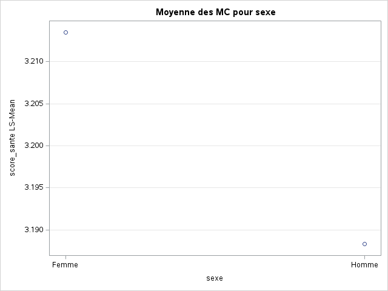

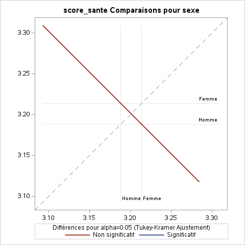

La procédure GLM

Moyennes des moindres carrés

Ajustement pour comparaisons multiples : Tukey-Kramer

| hospitalisation_12_mois | score_sante LSMEAN | H0:LSMean1=LSMean2 Pr > \|t\| |
| --- | --- | --- |
| Non | 3.21306727 | 0.8239 |
| Oui | 3.18872519 |  |

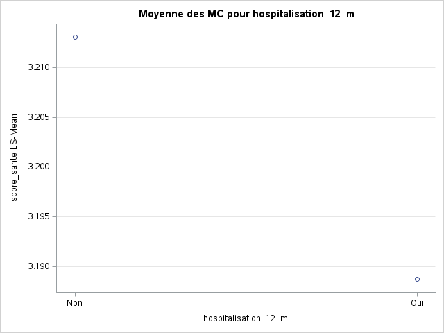

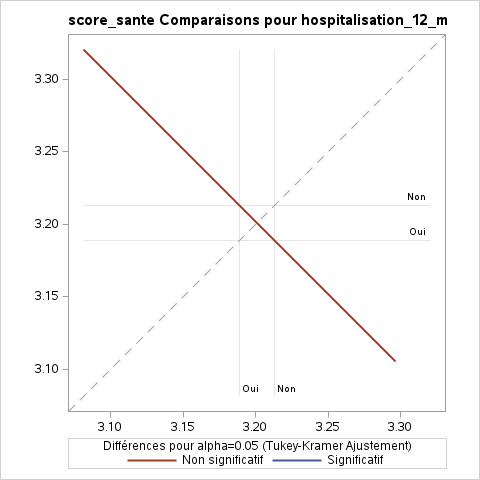

ANCOVA réduite — score_sante (facteurs significatifs)

La procédure GLM

Moyennes des moindres carrés

Ajustement pour comparaisons multiples : Tukey-Kramer

| activite_physique | score_sante LSMEAN | Nombre LSMEAN |
| --- | --- | --- |
| Activité intense | 2.96579430 | 1 |
| Activité légère | 3.27707629 | 2 |
| Activité modérée | 3.29228463 | 3 |
| Sédentaire | 3.26842969 | 4 |

| Moyennes des moindres carrés pour l'effet activite_physique Pr > \|t\| pour H0: LSMean(i)=LSMean(j) Variable dépendante : score_sante i/j | Moyennes des moindres carrés pour l'effet activite_physique Pr > \|t\| pour H0: LSMean(i)=LSMean(j) Variable dépendante : score_sante 1 | Moyennes des moindres carrés pour l'effet activite_physique Pr > \|t\| pour H0: LSMean(i)=LSMean(j) Variable dépendante : score_sante 2 | Moyennes des moindres carrés pour l'effet activite_physique Pr > \|t\| pour H0: LSMean(i)=LSMean(j) Variable dépendante : score_sante 3 | Moyennes des moindres carrés pour l'effet activite_physique Pr > \|t\| pour H0: LSMean(i)=LSMean(j) Variable dépendante : score_sante 4 |
| --- | --- | --- | --- | --- |
| 1 |  | 0.2269 | 0.1894 | 0.2695 |
| 2 | 0.2269 |  | 0.9993 | 0.9999 |
| 3 | 0.1894 | 0.9993 |  | 0.9977 |
| 4 | 0.2695 | 0.9999 | 0.9977 |  |

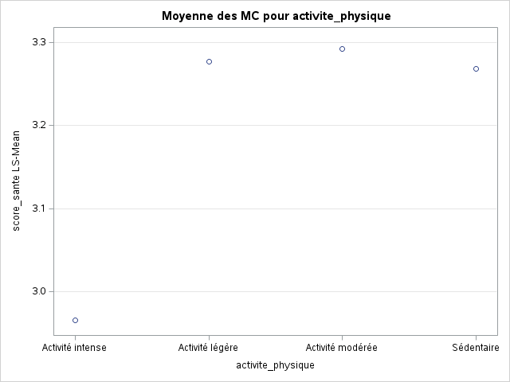

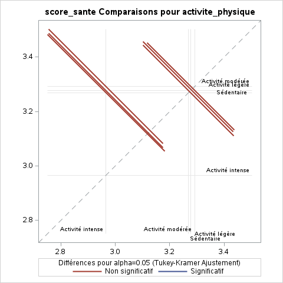

ANCOVA réduite — score_sante (facteurs significatifs)

La procédure GLM

Moyennes des moindres carrés

Ajustement pour comparaisons multiples : Tukey-Kramer

| handicap_declare | score_sante LSMEAN | H0:LSMean1=LSMean2 Pr > \|t\| |
| --- | --- | --- |
| Non | 3.14158168 | 0.3191 |
| Oui | 3.26021078 |  |

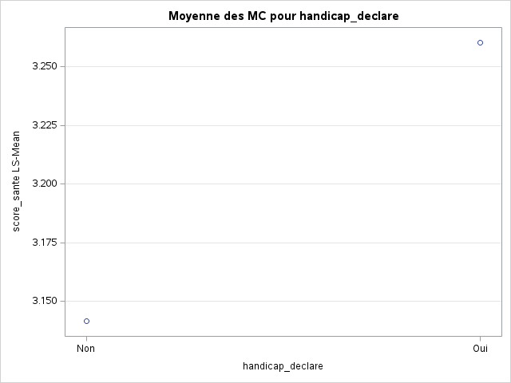

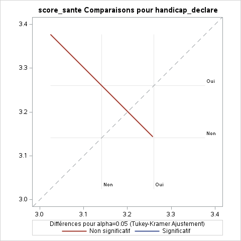

ANCOVA — Test d'interaction Âge × Sexe sur score_sante

La procédure GLM

| Informations sur les niveaux de classe Classe | Informations sur les niveaux de classe Niveaux | Informations sur les niveaux de classe Valeurs |
| --- | --- | --- |
| sexe | 2 | Femme Homme |

| Nombre d'observations lues | 500 |
| --- | --- |
| Nombre d'observations utilisées | 500 |

ANCOVA — Test d'interaction Âge × Sexe sur score_sante

La procédure GLM

Variable dépendante : score_sante

| Source | DDL | Somme des carrés | Carré moyen | Valeur F | Pr > F |
| --- | --- | --- | --- | --- | --- |
| Modèle | 3 | 74.2736849 | 24.7578950 | 20.89 | <.0001 |
| Erreur | 496 | 587.8283151 | 1.1851377 |  |  |
| Total sommes corrigées | 499 | 662.1020000 |  |  |  |

| R-carré | Coef de var | Racine MSE | score_sante Moyenne |
| --- | --- | --- | --- |
| 0.112179 | 33.87182 | 1.088640 | 3.214000 |

| Source | DDL | Type III SS | Carré moyen | Valeur F | Pr > F |
| --- | --- | --- | --- | --- | --- |
| age | 1 | 74.26789948 | 74.26789948 | 62.67 | <.0001 |
| sexe | 1 | 0.23209266 | 0.23209266 | 0.20 | 0.6583 |
| age*sexe | 1 | 0.49849084 | 0.49849084 | 0.42 | 0.5169 |

| Paramètre | Estimation |  | Erreur type | Valeur du test t | Pr > \|t\| |
| --- | --- | --- | --- | --- | --- |
| Constante | 4.250482688 | B | 0.19261788 | 22.07 | <.0001 |
| age | -0.018362696 | B | 0.00316422 | -5.80 | <.0001 |
| sexe Femme | -0.117585476 | B | 0.26570969 | -0.44 | 0.6583 |
| sexe Homme | 0.000000000 | B | . | . | . |
| age*sexe Femme | 0.002780971 | B | 0.00428798 | 0.65 | 0.5169 |
| age*sexe Homme | 0.000000000 | B | . | . | . |

Note:La matrice X'X s'est révélée être singulière, et un inverse généralisé a été utilisé pour résoudre les équations normales. Les termes dont les estimations sont suivies de la lettre 'B' ne sont pas estimables de manière unique.

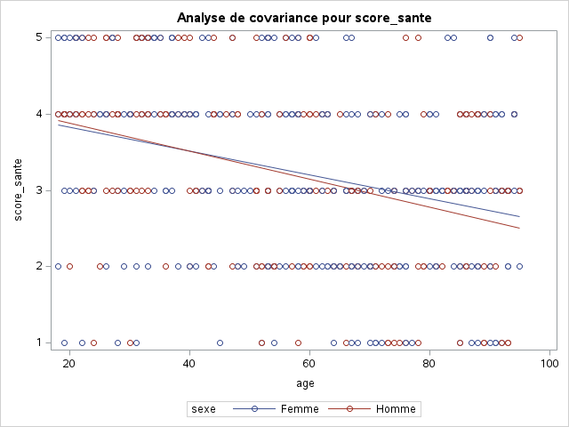

Régression logistique ordinale — etat_sante_percu (modèle complet)

La procédure LOGISTIC

| Informations sur le modèle |  |
| --- | --- |
| Table | PROJ.BASE_ESPS |
| Variable de réponse | etat_sante_percu |
| Nombre de niveaux de réponse | 5 |
| Modèle | logit cumulé |
| Technique d'optimisation | Score de Fisher |

| Nb d'observations lues | 500 |
| --- | --- |
| Nb d'observations utilisées | 500 |

| Profil de réponse Valeur ordonnée | Profil de réponse etat_sante_percu | Profil de réponse Fréquence totale |
| --- | --- | --- |
| 1 | Très mauvais | 40 |
| 2 | Très bon | 71 |
| 3 | Mauvais | 98 |
| 4 | Bon | 143 |
| 5 | Assez bon | 148 |

Les probabilités modélisées sont cumulées sur les valeurs ordonnées inférieures.

| Informations sur les niveaux de classe Classe | Informations sur les niveaux de classe Valeur | Informations sur les niveaux de classe Variables d'expérience | Informations sur les niveaux de classe Variables d'expérience | Informations sur les niveaux de classe Variables d'expérience |
| --- | --- | --- | --- | --- |
| sexe | Femme | 1 |  |  |
|  | Homme | 0 |  |  |
| hospitalisation_12_mois | Non | 0 |  |  |
|  | Oui | 1 |  |  |
| tabagisme | Ancien fumeur | 1 | 0 | 0 |
|  | Fumeur occasionnel | 0 | 1 | 0 |
|  | Fumeur quotidien | 0 | 0 | 1 |
|  | Non-fumeur | 0 | 0 | 0 |
| activite_physique | Activité intense | 1 | 0 | 0 |
|  | Activité légère | 0 | 1 | 0 |
|  | Activité modérée | 0 | 0 | 1 |
|  | Sédentaire | 0 | 0 | 0 |
| handicap_declare | Non | 0 |  |  |
|  | Oui | 1 |  |  |
| couverture_complementaire | Assurance privée | 1 | 0 | 0 |
|  | Aucune complémentaire | 0 | 1 | 0 |
|  | Complémentaire santé solidaire (CSS) | 0 | 0 | 1 |
|  | Mutuelle privée | 0 | 0 | 0 |

| Etat de convergence du modèle |
| --- |
| Critère de convergence (GCONV=1E-8) respecté. |

| Test de score pour l'hypothèse des cotes proportionnelles khi-2 | Test de score pour l'hypothèse des cotes proportionnelles DDL | Test de score pour l'hypothèse des cotes proportionnelles Pr > khi-2 |
| --- | --- | --- |
| 142.6879 | 54 | <.0001 |

| Statistique d'ajustement du modèle Critère | Statistique d'ajustement du modèle Constante uniquement | Statistique d'ajustement du modèle Constante et Covariables |
| --- | --- | --- |
| AIC | 1524.995 | 1544.620 |
| SC | 1541.854 | 1637.342 |
| -2 Log L | 1516.995 | 1500.620 |

| r-carré | 0.0322 | r-carré remis à l'échelle max. | 0.0338 |
| --- | --- | --- | --- |

| Test de l'hypothèse nulle globale : BETA=0 Test | Test de l'hypothèse nulle globale : BETA=0 khi-2 | Test de l'hypothèse nulle globale : BETA=0 DDL | Test de l'hypothèse nulle globale : BETA=0 Pr > khi-2 |
| --- | --- | --- | --- |
| Rapport de vrais | 16.3748 | 18 | 0.5664 |
| Score | 15.7808 | 18 | 0.6078 |
| Wald | 16.4989 | 18 | 0.5578 |

| Analyse des effets Type 3 Effet | Analyse des effets Type 3 DDL | Analyse des effets Type 3 Khi-2 de Wald | Analyse des effets Type 3 Pr > khi-2 |
| --- | --- | --- | --- |
| age | 1 | 1.1646 | 0.2805 |
| revenus_mensuels_eur | 1 | 1.0315 | 0.3098 |
| imc | 1 | 0.1281 | 0.7204 |
| nombre_consultations | 1 | 0.9906 | 0.3196 |
| nombre_medicaments_r | 1 | 0.0719 | 0.7886 |
| depenses_sante_annue | 1 | 0.0057 | 0.9396 |
| sexe | 1 | 0.4044 | 0.5248 |
| hospitalisation_12_m | 1 | 0.0123 | 0.9117 |
| tabagisme | 3 | 1.3747 | 0.7115 |
| activite_physique | 3 | 1.0357 | 0.7926 |
| handicap_declare | 1 | 3.6423 | 0.0563 |
| couverture_complemen | 3 | 3.0691 | 0.3811 |

| Analyse des valeurs estimées du maximum de vraisemblance Paramètre | Analyse des valeurs estimées du maximum de vraisemblance | Analyse des valeurs estimées du maximum de vraisemblance DDL | Analyse des valeurs estimées du maximum de vraisemblance Estimation | Analyse des valeurs estimées du maximum de vraisemblance Erreur type | Analyse des valeurs estimées du maximum de vraisemblance Khi-2 de Wald | Analyse des valeurs estimées du maximum de vraisemblance Pr > khi-2 | Analyse des valeurs estimées du maximum de vraisemblance Estimation normalisée |
| --- | --- | --- | --- | --- | --- | --- | --- |
| Intercept | Très mauvais | 1 | -1.7255 | 0.6085 | 8.0404 | 0.0046 |  |
| Intercept | Très bon | 1 | -0.5191 | 0.5969 | 0.7563 | 0.3845 |  |
| Intercept | Mauvais | 1 | 0.4235 | 0.5961 | 0.5048 | 0.4774 |  |
| Intercept | Bon | 1 | 1.6485 | 0.6005 | 7.5352 | 0.0061 |  |
| age |  | 1 | -0.00939 | 0.00870 | 1.1646 | 0.2805 | -0.1184 |
| revenus_mensuels_eur |  | 1 | 0.000095 | 0.000094 | 1.0315 | 0.3098 | 0.0458 |
| imc |  | 1 | -0.00689 | 0.0193 | 0.1281 | 0.7204 | -0.0161 |
| nombre_consultations |  | 1 | 0.0413 | 0.0415 | 0.9906 | 0.3196 | 0.0513 |
| nombre_medicaments_r |  | 1 | 0.0165 | 0.0617 | 0.0719 | 0.7886 | 0.0144 |
| depenses_sante_annue |  | 1 | -0.00002 | 0.000281 | 0.0057 | 0.9396 | -0.00772 |
| sexe | Femme | 1 | 0.1039 | 0.1634 | 0.4044 | 0.5248 | 0.0285 |
| hospitalisation_12_m | Oui | 1 | -0.0204 | 0.1836 | 0.0123 | 0.9117 | -0.00505 |
| tabagisme | Ancien fumeur | 1 | -0.1895 | 0.2048 | 0.8558 | 0.3549 | -0.0463 |
| tabagisme | Fumeur occasionnel | 1 | -0.2651 | 0.2751 | 0.9284 | 0.3353 | -0.0465 |
| tabagisme | Fumeur quotidien | 1 | -0.0802 | 0.2113 | 0.1439 | 0.7044 | -0.0190 |
| activite_physique | Activité intense | 1 | -0.1396 | 0.2787 | 0.2509 | 0.6165 | -0.0254 |
| activite_physique | Activité légère | 1 | -0.2179 | 0.2158 | 1.0194 | 0.3127 | -0.0553 |
| activite_physique | Activité modérée | 1 | -0.1326 | 0.2132 | 0.3871 | 0.5338 | -0.0339 |
| handicap_declare | Oui | 1 | -0.3831 | 0.2008 | 3.6423 | 0.0563 | -0.0870 |
| couverture_complemen | Assurance privée | 1 | -0.3187 | 0.2187 | 2.1237 | 0.1450 | -0.0687 |
| couverture_complemen | Aucune complémentaire | 1 | -0.1883 | 0.2839 | 0.4398 | 0.5072 | -0.0306 |
| couverture_complemen | Complémentaire santé solidaire (CSS) | 1 | -0.2878 | 0.2264 | 1.6157 | 0.2037 | -0.0599 |

| Estimation du rapport de cotes Effet | Estimation du rapport de cotes Estimation du point | Estimation du rapport de cotes Intervalle de confiance de Wald à95% | Estimation du rapport de cotes Intervalle de confiance de Wald à95% |
| --- | --- | --- | --- |
| age | 0.991 | 0.974 | 1.008 |
| revenus_mensuels_eur | 1.000 | 1.000 | 1.000 |
| imc | 0.993 | 0.956 | 1.031 |
| nombre_consultations | 1.042 | 0.961 | 1.131 |
| nombre_medicaments_r | 1.017 | 0.901 | 1.147 |
| depenses_sante_annue | 1.000 | 0.999 | 1.001 |
| sexe Femme vs Homme | 1.110 | 0.805 | 1.528 |
| hospitalisation_12_m Oui vs Non | 0.980 | 0.684 | 1.404 |
| tabagisme Ancien fumeur vs Non-fumeur | 0.827 | 0.554 | 1.236 |
| tabagisme Fumeur occasionnel vs Non-fumeur | 0.767 | 0.447 | 1.315 |
| tabagisme Fumeur quotidien vs Non-fumeur | 0.923 | 0.610 | 1.396 |
| activite_physique Activité intense vs Sédentaire | 0.870 | 0.504 | 1.502 |
| activite_physique Activité légère vs Sédentaire | 0.804 | 0.527 | 1.228 |
| activite_physique Activité modérée vs Sédentaire | 0.876 | 0.577 | 1.330 |
| handicap_declare Oui vs Non | 0.682 | 0.460 | 1.010 |
| couverture_complemen Assurance privée vs Mutuelle privée | 0.727 | 0.474 | 1.116 |
| couverture_complemen Aucune complémentaire vs Mutuelle privée | 0.828 | 0.475 | 1.445 |
| couverture_complemen Complémentaire santé solidaire (CSS) vs Mutuelle privée | 0.750 | 0.481 | 1.169 |

| Association des probabilités prédites et des réponses observées |  |  |  |
| --- | --- | --- | --- |
| Pourcentage concordant | 57.0 | D de Somers | 0.149 |
| Pourcentage discordant | 42.1 | Gamma | 0.150 |
| Pourcentage lié | 0.9 | Tau-a | 0.114 |
| Paires | 95701 | c | 0.574 |

| Partition pour les tests de Hosmer et de Lemeshow Groupe | Partition pour les tests de Hosmer et de Lemeshow Total | Partition pour les tests de Hosmer et de Lemeshow Observé etat_sante_percu = Très mauvais | Partition pour les tests de Hosmer et de Lemeshow Observé etat_sante_percu = Très bon | Partition pour les tests de Hosmer et de Lemeshow Observé etat_sante_percu = Mauvais | Partition pour les tests de Hosmer et de Lemeshow Observé etat_sante_percu = Bon | Partition pour les tests de Hosmer et de Lemeshow Observé etat_sante_percu = Assez bon | Partition pour les tests de Hosmer et de Lemeshow Attendu etat_sante_percu = Très mauvais | Partition pour les tests de Hosmer et de Lemeshow Attendu etat_sante_percu = Très bon | Partition pour les tests de Hosmer et de Lemeshow Attendu etat_sante_percu = Mauvais | Partition pour les tests de Hosmer et de Lemeshow Attendu etat_sante_percu = Bon | Partition pour les tests de Hosmer et de Lemeshow Attendu etat_sante_percu = Assez bon |
| --- | --- | --- | --- | --- | --- | --- | --- | --- | --- | --- | --- |
| 1 | 50 | 3 | 15 | 5 | 15 | 12 | 6.24 | 9.87 | 11.3 | 12.8 | 9.73 |
| 2 | 50 | 5 | 11 | 7 | 21 | 6 | 5.32 | 8.91 | 11.0 | 13.6 | 11.2 |
| 3 | 50 | 5 | 9 | 12 | 15 | 9 | 4.81 | 8.30 | 10.7 | 14.0 | 12.2 |
| 4 | 50 | 2 | 9 | 10 | 13 | 16 | 4.37 | 7.76 | 10.4 | 14.3 | 13.2 |
| 5 | 50 | 6 | 4 | 13 | 17 | 10 | 3.98 | 7.23 | 10.1 | 14.5 | 14.2 |
| 6 | 50 | 5 | 4 | 10 | 14 | 17 | 3.66 | 6.79 | 9.75 | 14.7 | 15.1 |
| 7 | 50 | 4 | 7 | 11 | 13 | 15 | 3.39 | 6.38 | 9.43 | 14.8 | 16.0 |
| 8 | 50 | 1 | 5 | 11 | 9 | 24 | 3.04 | 5.85 | 8.96 | 14.8 | 17.3 |
| 9 | 50 | 5 | 5 | 11 | 13 | 16 | 2.69 | 5.29 | 8.40 | 14.8 | 18.8 |
| 10 | 50 | 4 | 2 | 8 | 13 | 23 | 2.23 | 4.50 | 7.52 | 14.5 | 21.3 |

| Test d'adéquation de Hosmer et de Lemeshow khi-2 | Test d'adéquation de Hosmer et de Lemeshow DDL | Test d'adéquation de Hosmer et de Lemeshow Pr > khi-2 |
| --- | --- | --- |
| 41.6280 | 35 | 0.2045 |

Régression logistique ordinale — etat_sante_percu (modèle réduit)

La procédure LOGISTIC

| Informations sur le modèle |  |
| --- | --- |
| Table | PROJ.BASE_ESPS |
| Variable de réponse | etat_sante_percu |
| Nombre de niveaux de réponse | 5 |
| Modèle | logit cumulé |
| Technique d'optimisation | Score de Fisher |

| Nb d'observations lues | 500 |
| --- | --- |
| Nb d'observations utilisées | 500 |

| Profil de réponse Valeur ordonnée | Profil de réponse etat_sante_percu | Profil de réponse Fréquence totale |
| --- | --- | --- |
| 1 | Très mauvais | 40 |
| 2 | Très bon | 71 |
| 3 | Mauvais | 98 |
| 4 | Bon | 143 |
| 5 | Assez bon | 148 |

Les probabilités modélisées sont cumulées sur les valeurs ordonnées inférieures.

| Informations sur les niveaux de classe Classe | Informations sur les niveaux de classe Valeur | Informations sur les niveaux de classe Variables d'expérience | Informations sur les niveaux de classe Variables d'expérience | Informations sur les niveaux de classe Variables d'expérience |
| --- | --- | --- | --- | --- |
| sexe | Femme | 1 |  |  |
|  | Homme | 0 |  |  |
| hospitalisation_12_mois | Non | 0 |  |  |
|  | Oui | 1 |  |  |
| activite_physique | Activité intense | 1 | 0 | 0 |
|  | Activité légère | 0 | 1 | 0 |
|  | Activité modérée | 0 | 0 | 1 |
|  | Sédentaire | 0 | 0 | 0 |
| handicap_declare | Non | 0 |  |  |
|  | Oui | 1 |  |  |

| Etat de convergence du modèle |
| --- |
| Critère de convergence (GCONV=1E-8) respecté. |

| Test de score pour l'hypothèse des cotes proportionnelles khi-2 | Test de score pour l'hypothèse des cotes proportionnelles DDL | Test de score pour l'hypothèse des cotes proportionnelles Pr > khi-2 |
| --- | --- | --- |
| 106.3047 | 27 | <.0001 |

| Statistique d'ajustement du modèle Critère | Statistique d'ajustement du modèle Constante uniquement | Statistique d'ajustement du modèle Constante et Covariables |
| --- | --- | --- |
| AIC | 1524.995 | 1532.098 |
| SC | 1541.854 | 1586.888 |
| -2 Log L | 1516.995 | 1506.098 |

| r-carré | 0.0216 | r-carré remis à l'échelle max. | 0.0226 |
| --- | --- | --- | --- |

| Test de l'hypothèse nulle globale : BETA=0 Test | Test de l'hypothèse nulle globale : BETA=0 khi-2 | Test de l'hypothèse nulle globale : BETA=0 DDL | Test de l'hypothèse nulle globale : BETA=0 Pr > khi-2 |
| --- | --- | --- | --- |
| Rapport de vrais | 10.8970 | 9 | 0.2828 |
| Score | 10.5524 | 9 | 0.3076 |
| Wald | 11.0074 | 9 | 0.2752 |

| Analyse des effets Type 3 Effet | Analyse des effets Type 3 DDL | Analyse des effets Type 3 Khi-2 de Wald | Analyse des effets Type 3 Pr > khi-2 |
| --- | --- | --- | --- |
| age | 1 | 3.9036 | 0.0482 |
| nombre_consultations | 1 | 0.8797 | 0.3483 |
| nombre_medicaments_r | 1 | 0.0108 | 0.9174 |
| sexe | 1 | 0.1873 | 0.6652 |
| hospitalisation_12_m | 1 | 0.0170 | 0.8962 |
| activite_physique | 3 | 1.3805 | 0.7101 |
| handicap_declare | 1 | 3.6687 | 0.0554 |

| Analyse des valeurs estimées du maximum de vraisemblance Paramètre | Analyse des valeurs estimées du maximum de vraisemblance | Analyse des valeurs estimées du maximum de vraisemblance DDL | Analyse des valeurs estimées du maximum de vraisemblance Estimation | Analyse des valeurs estimées du maximum de vraisemblance Erreur type | Analyse des valeurs estimées du maximum de vraisemblance Khi-2 de Wald | Analyse des valeurs estimées du maximum de vraisemblance Pr > khi-2 | Analyse des valeurs estimées du maximum de vraisemblance Estimation normalisée |
| --- | --- | --- | --- | --- | --- | --- | --- |
| Intercept | Très mauvais | 1 | -1.9287 | 0.3027 | 40.6067 | <.0001 |  |
| Intercept | Très bon | 1 | -0.7301 | 0.2778 | 6.9096 | 0.0086 |  |
| Intercept | Mauvais | 1 | 0.2055 | 0.2749 | 0.5591 | 0.4546 |  |
| Intercept | Bon | 1 | 1.4229 | 0.2823 | 25.4077 | <.0001 |  |
| age |  | 1 | -0.00951 | 0.00481 | 3.9036 | 0.0482 | -0.1198 |
| nombre_consultations |  | 1 | 0.0387 | 0.0413 | 0.8797 | 0.3483 | 0.0481 |
| nombre_medicaments_r |  | 1 | 0.00634 | 0.0612 | 0.0108 | 0.9174 | 0.00553 |
| sexe | Femme | 1 | 0.0701 | 0.1620 | 0.1873 | 0.6652 | 0.0192 |
| hospitalisation_12_m | Oui | 1 | -0.0236 | 0.1812 | 0.0170 | 0.8962 | -0.00586 |
| activite_physique | Activité intense | 1 | -0.1576 | 0.2765 | 0.3247 | 0.5688 | -0.0287 |
| activite_physique | Activité légère | 1 | -0.2508 | 0.2144 | 1.3683 | 0.2421 | -0.0637 |
| activite_physique | Activité modérée | 1 | -0.1263 | 0.2125 | 0.3532 | 0.5523 | -0.0322 |
| handicap_declare | Oui | 1 | -0.3807 | 0.1988 | 3.6687 | 0.0554 | -0.0865 |

| Estimation du rapport de cotes Effet | Estimation du rapport de cotes Estimation du point | Estimation du rapport de cotes Intervalle de confiance de Wald à95% | Estimation du rapport de cotes Intervalle de confiance de Wald à95% |
| --- | --- | --- | --- |
| age | 0.991 | 0.981 | 1.000 |
| nombre_consultations | 1.039 | 0.959 | 1.127 |
| nombre_medicaments_r | 1.006 | 0.893 | 1.135 |
| sexe Femme vs Homme | 1.073 | 0.781 | 1.474 |
| hospitalisation_12_m Oui vs Non | 0.977 | 0.685 | 1.393 |
| activite_physique Activité intense vs Sédentaire | 0.854 | 0.497 | 1.469 |
| activite_physique Activité légère vs Sédentaire | 0.778 | 0.511 | 1.185 |
| activite_physique Activité modérée vs Sédentaire | 0.881 | 0.581 | 1.337 |
| handicap_declare Oui vs Non | 0.683 | 0.463 | 1.009 |

| Association des probabilités prédites et des réponses observées |  |  |  |
| --- | --- | --- | --- |
| Pourcentage concordant | 55.5 | D de Somers | 0.121 |
| Pourcentage discordant | 43.4 | Gamma | 0.122 |
| Pourcentage lié | 1.2 | Tau-a | 0.093 |
| Paires | 95701 | c | 0.560 |

| Partition pour les tests de Hosmer et de Lemeshow Groupe | Partition pour les tests de Hosmer et de Lemeshow Total | Partition pour les tests de Hosmer et de Lemeshow Observé etat_sante_percu = Très mauvais | Partition pour les tests de Hosmer et de Lemeshow Observé etat_sante_percu = Très bon | Partition pour les tests de Hosmer et de Lemeshow Observé etat_sante_percu = Mauvais | Partition pour les tests de Hosmer et de Lemeshow Observé etat_sante_percu = Bon | Partition pour les tests de Hosmer et de Lemeshow Observé etat_sante_percu = Assez bon | Partition pour les tests de Hosmer et de Lemeshow Attendu etat_sante_percu = Très mauvais | Partition pour les tests de Hosmer et de Lemeshow Attendu etat_sante_percu = Très bon | Partition pour les tests de Hosmer et de Lemeshow Attendu etat_sante_percu = Mauvais | Partition pour les tests de Hosmer et de Lemeshow Attendu etat_sante_percu = Bon | Partition pour les tests de Hosmer et de Lemeshow Attendu etat_sante_percu = Assez bon |
| --- | --- | --- | --- | --- | --- | --- | --- | --- | --- | --- | --- |
| 1 | 50 | 3 | 12 | 4 | 21 | 10 | 5.68 | 9.22 | 11.1 | 13.3 | 10.8 |
| 2 | 50 | 3 | 13 | 7 | 16 | 11 | 5.05 | 8.52 | 10.8 | 13.8 | 11.9 |
| 3 | 50 | 4 | 8 | 13 | 19 | 6 | 4.68 | 8.07 | 10.5 | 14.0 | 12.7 |
| 4 | 50 | 2 | 12 | 11 | 10 | 15 | 4.35 | 7.66 | 10.3 | 14.3 | 13.4 |
| 5 | 50 | 5 | 6 | 12 | 12 | 15 | 4.02 | 7.22 | 10.0 | 14.5 | 14.3 |
| 6 | 50 | 6 | 3 | 12 | 12 | 17 | 3.76 | 6.86 | 9.75 | 14.6 | 15.1 |
| 7 | 50 | 3 | 4 | 10 | 18 | 15 | 3.51 | 6.50 | 9.46 | 14.7 | 15.9 |
| 8 | 50 | 5 | 6 | 11 | 12 | 16 | 3.23 | 6.09 | 9.11 | 14.7 | 16.8 |
| 9 | 50 | 4 | 5 | 9 | 11 | 21 | 2.97 | 5.68 | 8.74 | 14.8 | 17.9 |
| 10 | 50 | 5 | 2 | 9 | 12 | 22 | 2.43 | 4.81 | 7.82 | 14.6 | 20.4 |

| Test d'adéquation de Hosmer et de Lemeshow khi-2 | Test d'adéquation de Hosmer et de Lemeshow DDL | Test d'adéquation de Hosmer et de Lemeshow Pr > khi-2 |
| --- | --- | --- |
| 44.1642 | 35 | 0.1378 |

Régression logistique binaire — sante_mauvaise (0/1)

La procédure LOGISTIC

| Informations sur le modèle |  |
| --- | --- |
| Table | PROJ.BASE_ESPS |
| Variable de réponse | sante_mauvaise |
| Nombre de niveaux de réponse | 2 |
| Modèle | logit binaire |
| Technique d'optimisation | Score de Fisher |

| Nb d'observations lues | 500 |
| --- | --- |
| Nb d'observations utilisées | 500 |

| Profil de réponse Valeur ordonnée | Profil de réponse sante_mauvaise | Profil de réponse Fréquence totale |
| --- | --- | --- |
| 1 | 1 | 138 |
| 2 | 0 | 362 |

La probabilité modélisée est sante_mauvaise=1.

| Informations sur les niveaux de classe Classe | Informations sur les niveaux de classe Valeur | Informations sur les niveaux de classe Variables d'expérience | Informations sur les niveaux de classe Variables d'expérience | Informations sur les niveaux de classe Variables d'expérience |
| --- | --- | --- | --- | --- |
| sexe | Femme | 1 |  |  |
|  | Homme | 0 |  |  |
| hospitalisation_12_mois | Non | 0 |  |  |
|  | Oui | 1 |  |  |
| tabagisme | Ancien fumeur | 1 | 0 | 0 |
|  | Fumeur occasionnel | 0 | 1 | 0 |
|  | Fumeur quotidien | 0 | 0 | 1 |
|  | Non-fumeur | 0 | 0 | 0 |
| activite_physique | Activité intense | 1 | 0 | 0 |
|  | Activité légère | 0 | 1 | 0 |
|  | Activité modérée | 0 | 0 | 1 |
|  | Sédentaire | 0 | 0 | 0 |
| handicap_declare | Non | 0 |  |  |
|  | Oui | 1 |  |  |

| Etat de convergence du modèle |
| --- |
| Critère de convergence (GCONV=1E-8) respecté. |

| Statistique d'ajustement du modèle Critère | Statistique d'ajustement du modèle Constante uniquement | Statistique d'ajustement du modèle Constante et Covariables |
| --- | --- | --- |
| AIC | 591.136 | 584.515 |
| SC | 595.350 | 647.734 |
| -2 Log L | 589.136 | 554.515 |

| r-carré | 0.0669 | r-carré remis à l'échelle max. | 0.0966 |
| --- | --- | --- | --- |

| Test de l'hypothèse nulle globale : BETA=0 Test | Test de l'hypothèse nulle globale : BETA=0 khi-2 | Test de l'hypothèse nulle globale : BETA=0 DDL | Test de l'hypothèse nulle globale : BETA=0 Pr > khi-2 |
| --- | --- | --- | --- |
| Rapport de vrais | 34.6204 | 14 | 0.0017 |
| Score | 33.5665 | 14 | 0.0024 |
| Wald | 31.4274 | 14 | 0.0048 |

| Analyse des effets Type 3 Effet | Analyse des effets Type 3 DDL | Analyse des effets Type 3 Khi-2 de Wald | Analyse des effets Type 3 Pr > khi-2 |
| --- | --- | --- | --- |
| age | 1 | 5.3886 | 0.0203 |
| revenus_mensuels_eur | 1 | 0.0293 | 0.8641 |
| imc | 1 | 1.0878 | 0.2970 |
| nombre_consultations | 1 | 2.8997 | 0.0886 |
| nombre_medicaments_r | 1 | 1.0764 | 0.2995 |
| sexe | 1 | 0.0293 | 0.8642 |
| hospitalisation_12_m | 1 | 0.0022 | 0.9625 |
| tabagisme | 3 | 2.4965 | 0.4759 |
| activite_physique | 3 | 2.5777 | 0.4614 |
| handicap_declare | 1 | 4.7382 | 0.0295 |

| Analyse des valeurs estimées du maximum de vraisemblance Paramètre | Analyse des valeurs estimées du maximum de vraisemblance | Analyse des valeurs estimées du maximum de vraisemblance DDL | Analyse des valeurs estimées du maximum de vraisemblance Estimation | Analyse des valeurs estimées du maximum de vraisemblance Erreur type | Analyse des valeurs estimées du maximum de vraisemblance Khi-2 de Wald | Analyse des valeurs estimées du maximum de vraisemblance Pr > khi-2 | Analyse des valeurs estimées du maximum de vraisemblance Estimation normalisée |
| --- | --- | --- | --- | --- | --- | --- | --- |
| Intercept |  | 1 | -2.8311 | 0.7725 | 13.4304 | 0.0002 |  |
| age |  | 1 | 0.0146 | 0.00629 | 5.3886 | 0.0203 | 0.1842 |
| revenus_mensuels_eur |  | 1 | 0.000022 | 0.000128 | 0.0293 | 0.8641 | 0.0105 |
| imc |  | 1 | 0.0257 | 0.0246 | 1.0878 | 0.2970 | 0.0599 |
| nombre_consultations |  | 1 | 0.0909 | 0.0534 | 2.8997 | 0.0886 | 0.1129 |
| nombre_medicaments_r |  | 1 | 0.0801 | 0.0772 | 1.0764 | 0.2995 | 0.0698 |
| sexe | Femme | 1 | 0.0361 | 0.2111 | 0.0293 | 0.8642 | 0.00990 |
| hospitalisation_12_m | Oui | 1 | -0.0109 | 0.2324 | 0.0022 | 0.9625 | -0.00271 |
| tabagisme | Ancien fumeur | 1 | -0.2588 | 0.2665 | 0.9431 | 0.3315 | -0.0633 |
| tabagisme | Fumeur occasionnel | 1 | 0.0969 | 0.3434 | 0.0797 | 0.7777 | 0.0170 |
| tabagisme | Fumeur quotidien | 1 | -0.3396 | 0.2746 | 1.5294 | 0.2162 | -0.0805 |
| activite_physique | Activité intense | 1 | 0.3375 | 0.3434 | 0.9661 | 0.3257 | 0.0614 |
| activite_physique | Activité légère | 1 | -0.1832 | 0.2800 | 0.4283 | 0.5128 | -0.0465 |
| activite_physique | Activité modérée | 1 | -0.1060 | 0.2793 | 0.1440 | 0.7043 | -0.0270 |
| handicap_declare | Oui | 1 | -0.5947 | 0.2732 | 4.7382 | 0.0295 | -0.1351 |

| Estimation du rapport de cotes Effet | Estimation du rapport de cotes Estimation du point | Estimation du rapport de cotes Intervalle de confiance de Wald à95% | Estimation du rapport de cotes Intervalle de confiance de Wald à95% |
| --- | --- | --- | --- |
| age | 1.015 | 1.002 | 1.027 |
| revenus_mensuels_eur | 1.000 | 1.000 | 1.000 |
| imc | 1.026 | 0.978 | 1.077 |
| nombre_consultations | 1.095 | 0.986 | 1.216 |
| nombre_medicaments_r | 1.083 | 0.931 | 1.261 |
| sexe Femme vs Homme | 1.037 | 0.685 | 1.568 |
| hospitalisation_12_m Oui vs Non | 0.989 | 0.627 | 1.560 |
| tabagisme Ancien fumeur vs Non-fumeur | 0.772 | 0.458 | 1.302 |
| tabagisme Fumeur occasionnel vs Non-fumeur | 1.102 | 0.562 | 2.160 |
| tabagisme Fumeur quotidien vs Non-fumeur | 0.712 | 0.416 | 1.220 |
| activite_physique Activité intense vs Sédentaire | 1.401 | 0.715 | 2.747 |
| activite_physique Activité légère vs Sédentaire | 0.833 | 0.481 | 1.441 |
| activite_physique Activité modérée vs Sédentaire | 0.899 | 0.520 | 1.555 |
| handicap_declare Oui vs Non | 0.552 | 0.323 | 0.942 |

| Association des probabilités prédites et des réponses observées |  |  |  |
| --- | --- | --- | --- |
| Pourcentage concordant | 66.6 | D de Somers | 0.332 |
| Pourcentage discordant | 33.4 | Gamma | 0.332 |
| Pourcentage lié | 0.0 | Tau-a | 0.133 |
| Paires | 49956 | c | 0.666 |

| Partition pour les tests de Hosmer et de Lemeshow Groupe | Partition pour les tests de Hosmer et de Lemeshow Total | Partition pour les tests de Hosmer et de Lemeshow sante_mauvaise = 1 Observé | Partition pour les tests de Hosmer et de Lemeshow sante_mauvaise = 1 Attendu | Partition pour les tests de Hosmer et de Lemeshow sante_mauvaise = 0 Observé | Partition pour les tests de Hosmer et de Lemeshow sante_mauvaise = 0 Attendu |
| --- | --- | --- | --- | --- | --- |
| 1 | 50 | 3 | 5.45 | 47 | 44.55 |
| 2 | 50 | 9 | 7.71 | 41 | 42.29 |
| 3 | 50 | 9 | 9.21 | 41 | 40.79 |
| 4 | 50 | 7 | 10.85 | 43 | 39.15 |
| 5 | 50 | 11 | 12.20 | 39 | 37.80 |
| 6 | 50 | 21 | 13.62 | 29 | 36.38 |
| 7 | 50 | 22 | 15.38 | 28 | 34.62 |
| 8 | 50 | 16 | 17.75 | 34 | 32.25 |
| 9 | 50 | 19 | 20.57 | 31 | 29.43 |
| 10 | 50 | 21 | 25.26 | 29 | 24.74 |

| Test d'adéquation de Hosmer et de Lemeshow khi-2 | Test d'adéquation de Hosmer et de Lemeshow DDL | Test d'adéquation de Hosmer et de Lemeshow Pr > khi-2 |
| --- | --- | --- |
| 14.9273 | 8 | 0.0606 |

| Table de classification Niveau de proba | Table de classification Correct Evénement | Table de classification Correct Non- événement | Table de classification Incorrect Evénement | Table de classification Incorrect Non- événement | Table de classification Pourcentages Correct | Table de classification Pourcentages Sensi- bilité | Table de classification Pourcentages Spéci- ficité | Table de classification Pourcentages Préd pos | Table de classification Pourcentages Préd nég |
| --- | --- | --- | --- | --- | --- | --- | --- | --- | --- |
| 0.040 | 138 | 0 | 362 | 0 | 27.6 | 100.0 | 0.0 | 27.6 | . |
| 0.060 | 138 | 1 | 361 | 0 | 27.8 | 100.0 | 0.3 | 27.7 | 100.0 |
| 0.080 | 137 | 4 | 358 | 1 | 28.2 | 99.3 | 1.1 | 27.7 | 80.0 |
| 0.100 | 136 | 13 | 349 | 2 | 29.8 | 98.6 | 3.6 | 28.0 | 86.7 |
| 0.120 | 135 | 29 | 333 | 3 | 32.8 | 97.8 | 8.0 | 28.8 | 90.6 |
| 0.140 | 131 | 49 | 313 | 7 | 36.0 | 94.9 | 13.5 | 29.5 | 87.5 |
| 0.160 | 124 | 68 | 294 | 14 | 38.4 | 89.9 | 18.8 | 29.7 | 82.9 |
| 0.180 | 118 | 95 | 267 | 20 | 42.6 | 85.5 | 26.2 | 30.6 | 82.6 |
| 0.200 | 111 | 123 | 239 | 27 | 46.8 | 80.4 | 34.0 | 31.7 | 82.0 |
| 0.220 | 105 | 151 | 211 | 33 | 51.2 | 76.1 | 41.7 | 33.2 | 82.1 |
| 0.240 | 93 | 172 | 190 | 45 | 53.0 | 67.4 | 47.5 | 32.9 | 79.3 |
| 0.260 | 83 | 206 | 156 | 55 | 57.8 | 60.1 | 56.9 | 34.7 | 78.9 |
| 0.280 | 66 | 228 | 134 | 72 | 58.8 | 47.8 | 63.0 | 33.0 | 76.0 |
| 0.300 | 59 | 239 | 123 | 79 | 59.6 | 42.8 | 66.0 | 32.4 | 75.2 |
| 0.320 | 51 | 252 | 110 | 87 | 60.6 | 37.0 | 69.6 | 31.7 | 74.3 |
| 0.340 | 49 | 272 | 90 | 89 | 64.2 | 35.5 | 75.1 | 35.3 | 75.3 |
| 0.360 | 40 | 282 | 80 | 98 | 64.4 | 29.0 | 77.9 | 33.3 | 74.2 |
| 0.380 | 35 | 292 | 70 | 103 | 65.4 | 25.4 | 80.7 | 33.3 | 73.9 |
| 0.400 | 27 | 306 | 56 | 111 | 66.6 | 19.6 | 84.5 | 32.5 | 73.4 |
| 0.420 | 23 | 317 | 45 | 115 | 68.0 | 16.7 | 87.6 | 33.8 | 73.4 |
| 0.440 | 18 | 324 | 38 | 120 | 68.4 | 13.0 | 89.5 | 32.1 | 73.0 |
| 0.460 | 17 | 334 | 28 | 121 | 70.2 | 12.3 | 92.3 | 37.8 | 73.4 |
| 0.480 | 12 | 340 | 22 | 126 | 70.4 | 8.7 | 93.9 | 35.3 | 73.0 |
| 0.500 | 11 | 347 | 15 | 127 | 71.6 | 8.0 | 95.9 | 42.3 | 73.2 |
| 0.520 | 7 | 352 | 10 | 131 | 71.8 | 5.1 | 97.2 | 41.2 | 72.9 |
| 0.540 | 3 | 354 | 8 | 135 | 71.4 | 2.2 | 97.8 | 27.3 | 72.4 |
| 0.560 | 3 | 357 | 5 | 135 | 72.0 | 2.2 | 98.6 | 37.5 | 72.6 |
| 0.580 | 3 | 359 | 3 | 135 | 72.4 | 2.2 | 99.2 | 50.0 | 72.7 |
| 0.600 | 1 | 360 | 2 | 137 | 72.2 | 0.7 | 99.4 | 33.3 | 72.4 |
| 0.620 | 0 | 362 | 0 | 138 | 72.4 | 0.0 | 100.0 | . | 72.4 |

Sélection stepwise — Régression logistique ordinale

La procédure LOGISTIC

| Informations sur le modèle |  |
| --- | --- |
| Table | PROJ.BASE_ESPS |
| Variable de réponse | etat_sante_percu |
| Nombre de niveaux de réponse | 5 |
| Modèle | logit cumulé |
| Technique d'optimisation | Score de Fisher |

| Nb d'observations lues | 500 |
| --- | --- |
| Nb d'observations utilisées | 500 |

| Profil de réponse Valeur ordonnée | Profil de réponse etat_sante_percu | Profil de réponse Fréquence totale |
| --- | --- | --- |
| 1 | Très mauvais | 40 |
| 2 | Très bon | 71 |
| 3 | Mauvais | 98 |
| 4 | Bon | 143 |
| 5 | Assez bon | 148 |

Les probabilités modélisées sont cumulées sur les valeurs ordonnées inférieures.

Procédure de sélection Stepwise

| Informations sur les niveaux de classe Classe | Informations sur les niveaux de classe Valeur | Informations sur les niveaux de classe Variables d'expérience | Informations sur les niveaux de classe Variables d'expérience | Informations sur les niveaux de classe Variables d'expérience |
| --- | --- | --- | --- | --- |
| sexe | Femme | 1 |  |  |
|  | Homme | 0 |  |  |
| hospitalisation_12_mois | Non | 0 |  |  |
|  | Oui | 1 |  |  |
| tabagisme | Ancien fumeur | 1 | 0 | 0 |
|  | Fumeur occasionnel | 0 | 1 | 0 |
|  | Fumeur quotidien | 0 | 0 | 1 |
|  | Non-fumeur | 0 | 0 | 0 |
| activite_physique | Activité intense | 1 | 0 | 0 |
|  | Activité légère | 0 | 1 | 0 |
|  | Activité modérée | 0 | 0 | 1 |
|  | Sédentaire | 0 | 0 | 0 |
| handicap_declare | Non | 0 |  |  |
|  | Oui | 1 |  |  |
| couverture_complementaire | Assurance privée | 1 | 0 | 0 |
|  | Aucune complémentaire | 0 | 1 | 0 |
|  | Complémentaire santé solidaire (CSS) | 0 | 0 | 1 |
|  | Mutuelle privée | 0 | 0 | 0 |

Etape 0. Constante saisis :

| Etat de convergence du modèle |
| --- |
| Critère de convergence (GCONV=1E-8) respecté. |

| -2 Log L | = | 1516.995 |
| --- | --- | --- |

| Test du khi-2 résiduel khi-2 | Test du khi-2 résiduel DDL | Test du khi-2 résiduel Pr > khi-2 |
| --- | --- | --- |
| 15.7808 | 18 | 0.6078 |

Etape 1. Effet age saisis :

| Etat de convergence du modèle |
| --- |
| Critère de convergence (GCONV=1E-8) respecté. |

| Test de score pour l'hypothèse des cotes proportionnelles khi-2 | Test de score pour l'hypothèse des cotes proportionnelles DDL | Test de score pour l'hypothèse des cotes proportionnelles Pr > khi-2 |
| --- | --- | --- |
| 71.8129 | 3 | <.0001 |

| Statistique d'ajustement du modèle Critère | Statistique d'ajustement du modèle Constante uniquement | Statistique d'ajustement du modèle Constante et Covariables |
| --- | --- | --- |
| AIC | 1524.995 | 1521.830 |
| SC | 1541.854 | 1542.903 |
| -2 Log L | 1516.995 | 1511.830 |

| Test de l'hypothèse nulle globale : BETA=0 Test | Test de l'hypothèse nulle globale : BETA=0 khi-2 | Test de l'hypothèse nulle globale : BETA=0 DDL | Test de l'hypothèse nulle globale : BETA=0 Pr > khi-2 |
| --- | --- | --- | --- |
| Rapport de vrais | 5.1651 | 1 | 0.0230 |
| Score | 5.0756 | 1 | 0.0243 |
| Wald | 5.2140 | 1 | 0.0224 |

| Test du khi-2 résiduel khi-2 | Test du khi-2 résiduel DDL | Test du khi-2 résiduel Pr > khi-2 |
| --- | --- | --- |
| 10.8073 | 17 | 0.8664 |

Note:Aucun effet pour le modèle dans l'étape 1 n'est supprimé.

Note:Aucun effet (supplémentaire) ne respectait le niveau de significativité de l'entrée 0.05 dans le modèle.

| Récapitulatif sur la sélection Stepwise Etape | Récapitulatif sur la sélection Stepwise Effet Saisi | Récapitulatif sur la sélection Stepwise Effet Supprimé | Récapitulatif sur la sélection Stepwise DDL | Récapitulatif sur la sélection Stepwise Nombre dans | Récapitulatif sur la sélection Stepwise Khi-2 du score | Récapitulatif sur la sélection Stepwise Khi-2 de Wald | Récapitulatif sur la sélection Stepwise Pr > khi-2 |  |  |  |  |  |
| --- | --- | --- | --- | --- | --- | --- | --- | --- | --- | --- | --- | --- |
| 1 | age |  |  |  |  |  |  | 1 | 1 | 5.0756 |  | 0.0243 |

| Analyse des effets Type 3 Effet | Analyse des effets Type 3 DDL | Analyse des effets Type 3 Khi-2 de Wald | Analyse des effets Type 3 Pr > khi-2 |
| --- | --- | --- | --- |
| age | 1 | 5.2140 | 0.0224 |

| Analyse des valeurs estimées du maximum de vraisemblance Paramètre | Analyse des valeurs estimées du maximum de vraisemblance | Analyse des valeurs estimées du maximum de vraisemblance DDL | Analyse des valeurs estimées du maximum de vraisemblance Estimation | Analyse des valeurs estimées du maximum de vraisemblance Erreur type | Analyse des valeurs estimées du maximum de vraisemblance Khi-2 de Wald | Analyse des valeurs estimées du maximum de vraisemblance Pr > khi-2 |
| --- | --- | --- | --- | --- | --- | --- |
| Intercept | Très mauvais | 1 | -2.0016 | 0.2558 | 61.2481 | <.0001 |
| Intercept | Très bon | 1 | -0.8070 | 0.2253 | 12.8329 | 0.0003 |
| Intercept | Mauvais | 1 | 0.1214 | 0.2211 | 0.3013 | 0.5831 |
| Intercept | Bon | 1 | 1.3265 | 0.2292 | 33.4936 | <.0001 |
| age |  | 1 | -0.00803 | 0.00352 | 5.2140 | 0.0224 |

| Estimation du rapport de cotes Effet | Estimation du rapport de cotes Estimation du point | Estimation du rapport de cotes Intervalle de confiance de Wald à95% | Estimation du rapport de cotes Intervalle de confiance de Wald à95% |
| --- | --- | --- | --- |
| age | 0.992 | 0.985 | 0.999 |

| Association des probabilités prédites et des réponses observées |  |  |  |
| --- | --- | --- | --- |
| Pourcentage concordant | 53.3 | D de Somers | 0.084 |
| Pourcentage discordant | 44.8 | Gamma | 0.086 |
| Pourcentage lié | 1.9 | Tau-a | 0.065 |
| Paires | 95701 | c | 0.542 |

Régression logistique binaire — Courbe ROC

La procédure LOGISTIC

| Informations sur le modèle |  |
| --- | --- |
| Table | PROJ.BASE_ESPS |
| Variable de réponse | sante_mauvaise |
| Nombre de niveaux de réponse | 2 |
| Modèle | logit binaire |
| Technique d'optimisation | Score de Fisher |

| Nb d'observations lues | 500 |
| --- | --- |
| Nb d'observations utilisées | 500 |

| Profil de réponse Valeur ordonnée | Profil de réponse sante_mauvaise | Profil de réponse Fréquence totale |
| --- | --- | --- |
| 1 | 1 | 138 |
| 2 | 0 | 362 |

La probabilité modélisée est sante_mauvaise=1.

| Informations sur les niveaux de classe Classe | Informations sur les niveaux de classe Valeur | Informations sur les niveaux de classe Variables d'expérience | Informations sur les niveaux de classe Variables d'expérience | Informations sur les niveaux de classe Variables d'expérience |
| --- | --- | --- | --- | --- |
| sexe | Femme | 1 |  |  |
|  | Homme | 0 |  |  |
| hospitalisation_12_mois | Non | 0 |  |  |
|  | Oui | 1 |  |  |
| activite_physique | Activité intense | 1 | 0 | 0 |
|  | Activité légère | 0 | 1 | 0 |
|  | Activité modérée | 0 | 0 | 1 |
|  | Sédentaire | 0 | 0 | 0 |
| handicap_declare | Non | 0 |  |  |
|  | Oui | 1 |  |  |

| Etat de convergence du modèle |
| --- |
| Critère de convergence (GCONV=1E-8) respecté. |

| Statistique d'ajustement du modèle Critère | Statistique d'ajustement du modèle Constante uniquement | Statistique d'ajustement du modèle Constante et Covariables |
| --- | --- | --- |
| AIC | 591.136 | 578.021 |
| SC | 595.350 | 620.167 |
| -2 Log L | 589.136 | 558.021 |

| r-carré | 0.0603 | r-carré remis à l'échelle max. | 0.0872 |
| --- | --- | --- | --- |

| Test de l'hypothèse nulle globale : BETA=0 Test | Test de l'hypothèse nulle globale : BETA=0 khi-2 | Test de l'hypothèse nulle globale : BETA=0 DDL | Test de l'hypothèse nulle globale : BETA=0 Pr > khi-2 |
| --- | --- | --- | --- |
| Rapport de vrais | 31.1152 | 9 | 0.0003 |
| Score | 30.2250 | 9 | 0.0004 |
| Wald | 28.5583 | 9 | 0.0008 |

| Analyse des effets Type 3 Effet | Analyse des effets Type 3 DDL | Analyse des effets Type 3 Khi-2 de Wald | Analyse des effets Type 3 Pr > khi-2 |
| --- | --- | --- | --- |
| age | 1 | 4.9937 | 0.0254 |
| nombre_consultations | 1 | 2.7615 | 0.0966 |
| nombre_medicaments_r | 1 | 1.1861 | 0.2761 |
| sexe | 1 | 0.0051 | 0.9429 |
| hospitalisation_12_m | 1 | 0.0000 | 0.9999 |
| activite_physique | 3 | 2.6827 | 0.4432 |
| handicap_declare | 1 | 4.3146 | 0.0378 |

| Analyse des valeurs estimées du maximum de vraisemblance Paramètre | Analyse des valeurs estimées du maximum de vraisemblance | Analyse des valeurs estimées du maximum de vraisemblance DDL | Analyse des valeurs estimées du maximum de vraisemblance Estimation | Analyse des valeurs estimées du maximum de vraisemblance Erreur type | Analyse des valeurs estimées du maximum de vraisemblance Khi-2 de Wald | Analyse des valeurs estimées du maximum de vraisemblance Pr > khi-2 |
| --- | --- | --- | --- | --- | --- | --- |
| Intercept |  | 1 | -2.2411 | 0.3781 | 35.1359 | <.0001 |
| age |  | 1 | 0.0139 | 0.00623 | 4.9937 | 0.0254 |
| nombre_consultations |  | 1 | 0.0880 | 0.0529 | 2.7615 | 0.0966 |
| nombre_medicaments_r |  | 1 | 0.0834 | 0.0766 | 1.1861 | 0.2761 |
| sexe | Femme | 1 | 0.0150 | 0.2097 | 0.0051 | 0.9429 |
| hospitalisation_12_m | Oui | 1 | -0.00003 | 0.2306 | 0.0000 | 0.9999 |
| activite_physique | Activité intense | 1 | 0.3457 | 0.3392 | 1.0385 | 0.3082 |
| activite_physique | Activité légère | 1 | -0.1779 | 0.2780 | 0.4093 | 0.5223 |
| activite_physique | Activité modérée | 1 | -0.1075 | 0.2777 | 0.1500 | 0.6986 |
| handicap_declare | Oui | 1 | -0.5632 | 0.2712 | 4.3146 | 0.0378 |

| Estimation du rapport de cotes Effet | Estimation du rapport de cotes Estimation du point | Estimation du rapport de cotes Intervalle de confiance de Wald à95% | Estimation du rapport de cotes Intervalle de confiance de Wald à95% |
| --- | --- | --- | --- |
| age | 1.014 | 1.002 | 1.026 |
| nombre_consultations | 1.092 | 0.984 | 1.211 |
| nombre_medicaments_r | 1.087 | 0.935 | 1.263 |
| sexe Femme vs Homme | 1.015 | 0.673 | 1.531 |
| hospitalisation_12_m Oui vs Non | 1.000 | 0.636 | 1.571 |
| activite_physique Activité intense vs Sédentaire | 1.413 | 0.727 | 2.747 |
| activite_physique Activité légère vs Sédentaire | 0.837 | 0.485 | 1.443 |
| activite_physique Activité modérée vs Sédentaire | 0.898 | 0.521 | 1.548 |
| handicap_declare Oui vs Non | 0.569 | 0.335 | 0.969 |

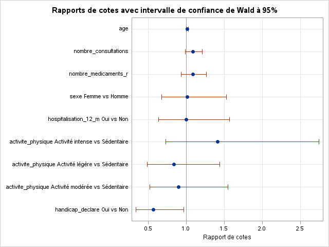

| Association des probabilités prédites et des réponses observées |  |  |  |
| --- | --- | --- | --- |
| Pourcentage concordant | 65.9 | D de Somers | 0.318 |
| Pourcentage discordant | 34.1 | Gamma | 0.318 |
| Pourcentage lié | 0.0 | Tau-a | 0.127 |
| Paires | 49956 | c | 0.659 |

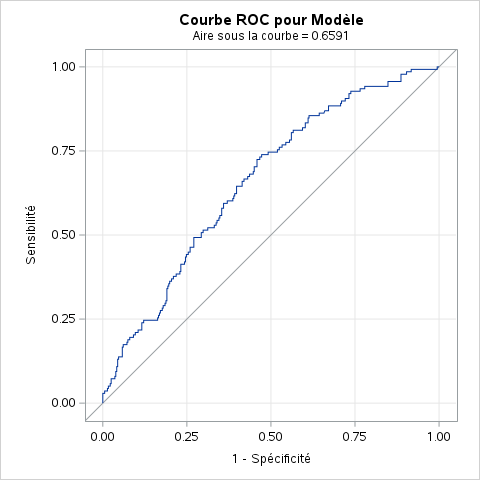

| Partition pour les tests de Hosmer et de Lemeshow Groupe | Partition pour les tests de Hosmer et de Lemeshow Total | Partition pour les tests de Hosmer et de Lemeshow sante_mauvaise = 1 Observé | Partition pour les tests de Hosmer et de Lemeshow sante_mauvaise = 1 Attendu | Partition pour les tests de Hosmer et de Lemeshow sante_mauvaise = 0 Observé | Partition pour les tests de Hosmer et de Lemeshow sante_mauvaise = 0 Attendu |
| --- | --- | --- | --- | --- | --- |
| 1 | 50 | 6 | 5.84 | 44 | 44.16 |
| 2 | 50 | 4 | 7.93 | 46 | 42.07 |
| 3 | 50 | 10 | 9.40 | 40 | 40.60 |
| 4 | 50 | 12 | 10.80 | 38 | 39.20 |
| 5 | 50 | 13 | 12.32 | 37 | 37.68 |
| 6 | 50 | 18 | 13.83 | 32 | 36.17 |
| 7 | 50 | 15 | 15.50 | 35 | 34.50 |
| 8 | 50 | 22 | 17.59 | 28 | 32.41 |
| 9 | 50 | 14 | 20.32 | 36 | 29.68 |
| 10 | 50 | 24 | 24.46 | 26 | 25.54 |

| Test d'adéquation de Hosmer et de Lemeshow khi-2 | Test d'adéquation de Hosmer et de Lemeshow DDL | Test d'adéquation de Hosmer et de Lemeshow Pr > khi-2 |
| --- | --- | --- |
| 9.3839 | 8 | 0.3110 |

| Table de classification Niveau de proba | Table de classification Correct Evénement | Table de classification Correct Non- événement | Table de classification Incorrect Evénement | Table de classification Incorrect Non- événement | Table de classification Pourcentages Correct | Table de classification Pourcentages Sensi- bilité | Table de classification Pourcentages Spéci- ficité | Table de classification Pourcentages Préd pos | Table de classification Pourcentages Préd nég |
| --- | --- | --- | --- | --- | --- | --- | --- | --- | --- |
| 0.060 | 138 | 0 | 362 | 0 | 27.6 | 100.0 | 0.0 | 27.6 | . |
| 0.080 | 137 | 2 | 360 | 1 | 27.8 | 99.3 | 0.6 | 27.6 | 66.7 |
| 0.100 | 137 | 10 | 352 | 1 | 29.4 | 99.3 | 2.8 | 28.0 | 90.9 |
| 0.120 | 135 | 21 | 341 | 3 | 31.2 | 97.8 | 5.8 | 28.4 | 87.5 |
| 0.140 | 131 | 41 | 321 | 7 | 34.4 | 94.9 | 11.3 | 29.0 | 85.4 |
| 0.160 | 127 | 65 | 297 | 11 | 38.4 | 92.0 | 18.0 | 30.0 | 85.5 |
| 0.180 | 122 | 98 | 264 | 16 | 44.0 | 88.4 | 27.1 | 31.6 | 86.0 |
| 0.200 | 116 | 122 | 240 | 22 | 47.6 | 84.1 | 33.7 | 32.6 | 84.7 |
| 0.220 | 103 | 149 | 213 | 35 | 50.4 | 74.6 | 41.2 | 32.6 | 81.0 |
| 0.240 | 97 | 174 | 188 | 41 | 54.2 | 70.3 | 48.1 | 34.0 | 80.9 |
| 0.260 | 86 | 197 | 165 | 52 | 56.6 | 62.3 | 54.4 | 34.3 | 79.1 |
| 0.280 | 74 | 221 | 141 | 64 | 59.0 | 53.6 | 61.0 | 34.4 | 77.5 |
| 0.300 | 66 | 239 | 123 | 72 | 61.0 | 47.8 | 66.0 | 34.9 | 76.8 |
| 0.320 | 57 | 260 | 102 | 81 | 63.4 | 41.3 | 71.8 | 35.8 | 76.2 |
| 0.340 | 51 | 276 | 86 | 87 | 65.4 | 37.0 | 76.2 | 37.2 | 76.0 |
| 0.360 | 37 | 290 | 72 | 101 | 65.4 | 26.8 | 80.1 | 33.9 | 74.2 |
| 0.380 | 34 | 297 | 65 | 104 | 66.2 | 24.6 | 82.0 | 34.3 | 74.1 |
| 0.400 | 30 | 308 | 54 | 108 | 67.6 | 21.7 | 85.1 | 35.7 | 74.0 |
| 0.420 | 26 | 321 | 41 | 112 | 69.4 | 18.8 | 88.7 | 38.8 | 74.1 |
| 0.440 | 19 | 330 | 32 | 119 | 69.8 | 13.8 | 91.2 | 37.3 | 73.5 |
| 0.460 | 13 | 339 | 23 | 125 | 70.4 | 9.4 | 93.6 | 36.1 | 73.1 |
| 0.480 | 10 | 345 | 17 | 128 | 71.0 | 7.2 | 95.3 | 37.0 | 72.9 |
| 0.500 | 7 | 349 | 13 | 131 | 71.2 | 5.1 | 96.4 | 35.0 | 72.7 |
| 0.520 | 5 | 353 | 9 | 133 | 71.6 | 3.6 | 97.5 | 35.7 | 72.6 |
| 0.540 | 1 | 358 | 4 | 137 | 71.8 | 0.7 | 98.9 | 20.0 | 72.3 |
| 0.560 | 0 | 360 | 2 | 138 | 72.0 | 0.0 | 99.4 | 0.0 | 72.3 |
| 0.580 | 0 | 362 | 0 | 138 | 72.4 | 0.0 | 100.0 | . | 72.4 |

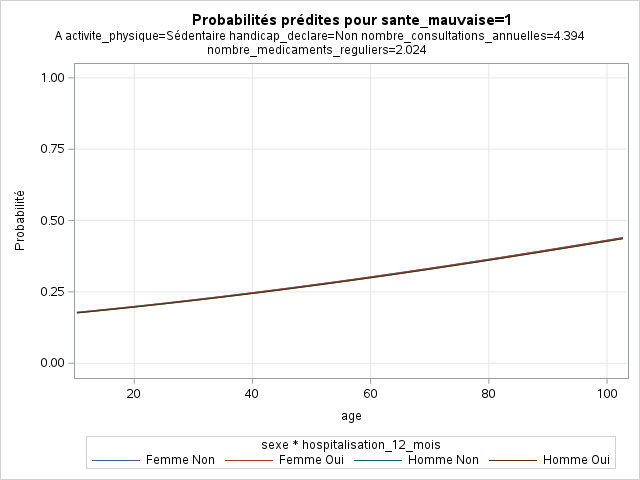